# DARDC_behavioral_Data_Analysis

### Y: Performance

```r
reg.m3.1_lmerTest <-
  df_v1_good_TEST %>%
  lmerTest::lmer(RTZ ~ OnlineRatingZ + TaskDemand*TrialN
                 + RT_preZ + ACC_preZ + Trial_A_measure_pre +
                   (0 + TaskDemand|TrialN) +
                   (1 + TaskDemand|TrialTransition_pre) + (1 + TaskDemand|TrialDemandLearning_pre) +
                   (1| PID) + (1 | ISI) + (1 | CueMapping) + (1 | Gender),
                 data = .)
# summary(reg.m3.1_lmerTest)
```

```r
reg.m3.2_lmerTest <-
  df_v1_good_TEST %>%
  lmerTest::lmer(ACCZ ~ OnlineRatingZ + TaskDemand*TrialN
                 + RT_preZ + ACC_preZ + Trial_A_measure_pre +
                   (0 + TaskDemand|TrialN) +
                   (1 + TaskDemand|TrialTransition_pre) + (1 + TaskDemand|TrialDemandLearning_pre) +
                   (1| PID) + (1 | ISI) + (1 | CueMapping) + (1 | Gender),
                 data = .)
```

```r
reg.m3.3_lmerTest <-
  df_v1_good_TEST %>%
  lmerTest::lmer(Trial_A_measure ~ OnlineRatingZ + TaskDemand*TrialN
                 + RT_preZ + ACC_preZ + Trial_A_measure_pre +
                   (0 + TaskDemand|TrialN) +
                   (1 + TaskDemand|TrialTransition_pre) + (1 + TaskDemand|TrialDemandLearning_pre) +
                   (1| PID) + (1 | ISI) + (1 | CueMapping) + (1 | Gender),
                 data = .)
```

```r
tab_model(reg.m3.1_lmerTest, reg.m3.2_lmerTest, reg.m3.3_lmerTest,
          show.re.var = FALSE, show.ngroups = FALSE,
          file = "E:/Dissertation/Methods/Exp2_Demand_Choice/DARDCpy_v2/data_analysis/reg_m3.html")
```

#### Regression Model Diagnosis

```r
plot(reg.m1.2_lmerTest, type = c("p", "smooth"))
# scale-location plots
plot(reg.m1.2_lmerTest, sqrt(abs(resid(.))) ~ fitted(.), type = c("p", "smooth"))
# qq plot
qqmath(reg.m1.2_lmerTest, id = 0.05)
```

```r
# posterior predictive simulation
iqrvec <- sapply(simulate(reg.m1.2_lmerTest, 1000), IQR)
obsval <- IQR(df_ra_dc$DCERs)
post.pred.p <- mean(obsval >= c(obsval, iqrvec))
post.pred.p
```

```r
plot(reg.m2.2_lmerTest, type = c("p", "smooth"))
# scale-location plots
plot(reg.m2.2_lmerTest, sqrt(abs(resid(.))) ~ fitted(.), type = c("p", "smooth"))
# qq plot
qqmath(reg.m2.2_lmerTest, id = 0.05)
```

```r
# posterior predictive simulation
iqrvec <- sapply(simulate(reg.m2.2_lmerTest, 1000), IQR)
obsval <- IQR(df_ra_dc$DCERs)
post.pred.p <- mean(obsval >= c(obsval, iqrvec))
post.pred.p
```

### Performance Pre & Ratings

```r
df_ra_rt_means_de_v1 <-
  df_v1_good_TEST %>%
  group_by(PID, TaskDemand) %>%
  summarise(RT_preZs = mean(RT_preZ, na.rm = TRUE),
            OnlineRatingZs = mean(OnlineRatingZ, na.rm = TRUE),
            .groups = "drop")

df_ra_rt_means_de_v1 %>%
  ggplot(aes(x = RT_preZs, y = OnlineRatingZs, color = TaskDemand)) +
  geom_point() +
  geom_smooth(method = "lm")+
  scale_color_lancet()
```

```r
df_ra_acc_means_de_v1 <-
  df_v1_good_TEST %>%
  group_by(PID, TaskDemand) %>%
  summarise(ACC_pres = mean(Trial_ACC_pre, na.rm = TRUE),
            OnlineRatingZs = mean(OnlineRatingZ, na.rm = TRUE),
            .groups = "drop")

df_ra_acc_means_de_v1 %>%
  ggplot(aes(x = ACC_pres, y = OnlineRatingZs, color = TaskDemand)) +
  geom_point() +
  geom_smooth(method = "lm")+
  scale_color_lancet()
```

```r
df_ra_a_means_de_v1 <-
  df_v1_good %>%
  group_by(PID, TaskDemand) %>%
  summarise(A_preZs = mean(Trial_A_measure_pre, na.rm = TRUE),
            OnlineRatingZs = mean(OnlineRatingZ, na.rm = TRUE),
            .groups = "drop")

df_ra_a_means_de_v1 %>%
  ggplot(aes(x = A_preZs, y = OnlineRatingZs, color = TaskDemand)) +
  geom_point() +
  geom_smooth(method = "lm")+
  scale_color_lancet()
```

### ————————————————————————————-

# DATA ANALYSIS VERSION 2

## Load data

```r
DataInput_v2 <- function(p_raw_data_file){
  p_df_raw <- read.csv(p_raw_data_file)
  # print(colnames(p_df_raw))
  select_cols <- c("PID", "SONA", "Gender", "Age", "Run",
                   # Procedure Info
                   "Phase", "Block", "TrialN", "NbackLevel", "ISI",
                   # Calibration Info
                   "TrialCountCali", "CaliEnd_A_measure",
                   # Trial Info
                   "TrialIndex", "TrialNumber_total", "TrialNumber_valid",
                   # Trial Performance
                   "Trial_A_measure",
                   "Trial_HR", "Trial_FAR", "Trial_CDR", "Trial_MSR",
                   "Trial_ACC","Trial_RT",
                   "Letter_Resp", "Letter_RT", "Letter_Accuracy",
                   "Trial_HitsCount","Trial_FAsCount",
                   "Trial_NoRespCount", "Trial_SameNoRespCount", "Trial_DiffNoRespCount",
                   "Trial_CDsCount",
                   "Trial_CorrectRespCount",
                   "Trial_SameLetterCount", "Trial_DiffLetterCount", "Trial_InvalidLetterCount",
                   # Learning Phase (Test) rating
                   "CueLearning", "CueMapping", "TrialDemandLearning",
                   "OnlineRating", "OnlineRatingRT", "OnlineRatingTimeOut",
                   # True & False choice
                   "CueLeft", "CueDemandLeft",
                   "CueRight", "CueDemandRight",
                   "PhaseType",
                   "Choice", "ChoiceRT",
                   "ChoiceDemand", "TaskDemand",
                   # Offline Rating T1, T2, T3
                   "OfflineRatingTimePoint",
                   "CueFigure", "TrialDemand",
                   "OfflineRating", "OfflineRatingRT",
                   # Demand Rating
                   "DemandRatingQuesIndex", "QuesTLX", "DemandLevel",
                   "DemandRating", "DemandRatingRT",
                   # Learning check
                   "CueCheck", "CueDemandCheck", "CorrectAnswer",
                   "Answer", "AnswerDemand", "AnswerRT", "AnswerACC",
                   # End
                   "END")
  # for (col in select_cols){
  #   check <- col %in% colnames(p_df_raw)
  #   if (! check){
  #    print(c(col, check))
  #   }
  # }
  p_df_selected <- p_df_raw[, select_cols]
  return(p_df_selected)
}
```

data_v2 of the 2nd recruitment

```r
data_path_v2 <- "/Users/ottolab/Desktop/Yue/DARDC_v2_Data_Analysis/data_move_here"
data_all_v2 <- list()
p_folders <- list.dirs(data_path_v2, recursive = FALSE)
# print(p_folders)
for (p_folder in p_folders){
  # print(p_folder)
  p_raw_data_file <- file.path(p_folder, paste0(basename(p_folder), "_task.csv"))
  # print(p_raw_data_file)
  p_data <- DataInput_v2(p_raw_data_file)
  data_all_v2[[basename(p_folder)]] <- p_data  # R中用元素名称作为索引
}

df_all_v2 <- do.call(rbind, data_all_v2)
```

```r
write.csv(df_all_v2, na = "",
          file = "/Users/ottolab/Desktop/Yue/DARDC_v2_Data_Analysis/df_all_v2.csv")
```

## Preprocess the whole dataframe

```r
df_all_v2_select <-
  df_all_v2 %>%
  filter(Phase %in% c("TEST", "Test",
                      "TrueCHOICE", "FalseCHOICE", "Choice",
                      "OFFLINERATING",
                      "DEMANDRATING", "LEARNINGCHECK"))
```

```r
df_v2_TEST_Test <-
  df_all_v2_select %>%
  filter(Phase %in% c("TEST", "Test"))

df_v2_CHOICE_Choice <-
  df_all_v2_select %>%
  filter(Phase %in% c("TrueCHOICE", "FalseCHOICE", "Choice"))

df_v2_OFFLINERATING <-
  df_all_v2_select %>%
  filter(Phase == "OFFLINERATING")

df_v2_DEMANDRATING <-
  df_all_v2_select %>%
  filter(Phase == "DEMANDRATING")

df_v2_LEARNINGCHECK <-
  df_all_v2_select %>%
  filter(Phase == "LEARNINGCHECK")
```

merge the corresponding trial row of “Test” and “TEST”

```r
df_v2_LEARNING <-
  df_v2_TEST_Test %>%
  group_by(PID, Block, TrialN) %>%
  mutate(
    Trial_A_measure = ifelse(Phase %in% c("TEST"), lag(Trial_A_measure), Trial_A_measure),
    Trial_HR = ifelse(Phase %in% c("TEST"), lag(Trial_HR), Trial_HR),
    Trial_FAR = ifelse(Phase %in% c("TEST"), lag(Trial_FAR), Trial_FAR),
    Trial_CDR = ifelse(Phase %in% c("TEST"), lag(Trial_CDR), Trial_CDR),
    Trial_MSR = ifelse(Phase %in% c("TEST"), lag(Trial_MSR), Trial_MSR),
    Trial_ACC = ifelse(Phase %in% c("TEST"), lag(Trial_ACC), Trial_ACC),
    Trial_RT = ifelse(Phase %in% c("TEST"), lag(Trial_RT), Trial_RT),
    Trial_HitsCount = ifelse(Phase %in% c("TEST"), lag(Trial_HitsCount), Trial_HitsCount),
    Trial_FAsCount = ifelse(Phase %in% c("TEST"), lag(Trial_FAsCount), Trial_FAsCount),
    Trial_SameNoRespCount = ifelse(Phase %in% c("TEST"),
                                   lag(Trial_SameNoRespCount), Trial_SameNoRespCount),
    Trial_DiffNoRespCount = ifelse(Phase %in% c("TEST"),
                                   lag(Trial_DiffNoRespCount), Trial_DiffNoRespCount),
    Trial_NoRespCount = ifelse(Phase %in% c("TEST"),
                               lag(Trial_NoRespCount), Trial_NoRespCount),
    Trial_CDsCount = ifelse(Phase %in% c("TEST"), lag(Trial_CDsCount), Trial_CDsCount),
    Trial_CorrectRespCount = ifelse(Phase %in% c("TEST"),
                                    lag(Trial_CorrectRespCount), Trial_CorrectRespCount),
    Trial_SameLetterCount = ifelse(Phase %in% c("TEST"),
                                   lag(Trial_SameLetterCount), Trial_SameLetterCount),
    Trial_DiffLetterCount = ifelse(Phase %in% c("TEST"),
                                   lag(Trial_DiffLetterCount), Trial_DiffLetterCount),
    Trial_InvalidLetterCount = ifelse(Phase %in% c("TEST"),
                                      lag(Trial_InvalidLetterCount), Trial_InvalidLetterCount)) %>%
  ungroup() %>%
  filter(Phase == "TEST") %>%
  group_by(PID) %>%
  mutate(TrialDemandLearning_pre = lag(TrialDemandLearning),
         TrialTransition = ifelse(TrialDemandLearning == lag(TrialDemandLearning),
                                  "repetition", "switch"),
         TrialTransition_pre = lag(TrialTransition),
         Trial_RT_pre = lag(Trial_RT),
         Trial_ACC_pre = lag(Trial_ACC),
         Trial_A_measure_pre = lag(Trial_A_measure)) %>%
  ungroup()


df_v2_CHOICE <-
  df_v2_CHOICE_Choice %>%
  group_by(PID, Block, TrialN) %>%
  mutate(
    Trial_A_measure = ifelse(Phase %in% c("TrueCHOICE", "FalseCHOICE"),
                             lag(Trial_A_measure), Trial_A_measure),
    Trial_HR = ifelse(Phase %in% c("TrueCHOICE", "FalseCHOICE"), lag(Trial_HR), Trial_HR),
    Trial_FAR = ifelse(Phase %in% c("TrueCHOICE", "FalseCHOICE"), lag(Trial_FAR), Trial_FAR),
    Trial_CDR = ifelse(Phase %in% c("TrueCHOICE", "FalseCHOICE"), lag(Trial_CDR), Trial_CDR),
    Trial_MSR = ifelse(Phase %in% c("TrueCHOICE", "FalseCHOICE"), lag(Trial_MSR), Trial_MSR),
    Trial_ACC = ifelse(Phase %in% c("TrueCHOICE", "FalseCHOICE"), lag(Trial_ACC), Trial_ACC),
    Trial_RT = ifelse(Phase %in% c("TrueCHOICE", "FalseCHOICE"), lag(Trial_RT), Trial_RT),
    Trial_HitsCount = ifelse(Phase %in% c("TrueCHOICE", "FalseCHOICE"),
                             lag(Trial_HitsCount), Trial_HitsCount),
    Trial_FAsCount = ifelse(Phase %in% c("TrueCHOICE", "FalseCHOICE"),
                            lag(Trial_FAsCount), Trial_FAsCount),
    Trial_SameNoRespCount = ifelse(Phase %in% c("TrueCHOICE", "FalseCHOICE"),
                                   lag(Trial_SameNoRespCount), Trial_SameNoRespCount),
    Trial_DiffNoRespCount = ifelse(Phase %in% c("TrueCHOICE", "FalseCHOICE"),
                                   lag(Trial_DiffNoRespCount), Trial_DiffNoRespCount),
    Trial_NoRespCount = ifelse(Phase %in% c("TrueCHOICE", "FalseCHOICE"),
                               lag(Trial_NoRespCount), Trial_NoRespCount),
    Trial_CDsCount = ifelse(Phase %in% c("TrueCHOICE", "FalseCHOICE"),
                            lag(Trial_CDsCount), Trial_CDsCount),
    Trial_CorrectRespCount = ifelse(Phase %in% c("TrueCHOICE", "FalseCHOICE"),
                                    lag(Trial_CorrectRespCount), Trial_CorrectRespCount),
    Trial_SameLetterCount = ifelse(Phase %in% c("TrueCHOICE", "FalseCHOICE"),
                                   lag(Trial_SameLetterCount), Trial_SameLetterCount),
    Trial_DiffLetterCount = ifelse(Phase %in% c("TrueCHOICE", "FalseCHOICE"),
                                   lag(Trial_DiffLetterCount), Trial_DiffLetterCount),
    Trial_InvalidLetterCount = ifelse(Phase %in% c("TrueCHOICE", "FalseCHOICE"),
                                      lag(Trial_InvalidLetterCount), Trial_InvalidLetterCount)) %>%
  ungroup() %>%
  filter(Phase %in% c("TrueCHOICE", "FalseCHOICE")) %>%
  group_by(PID, PhaseType) %>%
  mutate(TaskDemand_pre = lag(TaskDemand),
         TrialTransition = ifelse(TaskDemand == lag(TaskDemand),
                                  "repetition", "switch"),
         TrialTransition_pre = lag(TrialTransition),
         Trial_RT_pre = lag(Trial_RT),
         Trial_ACC_pre = lag(Trial_ACC),
         Trial_A_measure_pre = lag(Trial_A_measure)) %>%
  ungroup()

df_v2_LEARNINGCHECK <-
  df_v2_LEARNINGCHECK %>%
  mutate(LearningCheck = ifelse(AnswerACC == 0, "NotLearned", "Learned"))

df_v2_DEMANDRATING <-
  df_v2_DEMANDRATING %>%
  group_by(PID) %>%
  mutate(DemandRatingZ = c(scale(DemandRating, center = TRUE, scale = TRUE)),
         DemandCheck = ifelse(DemandLevel==1, "easy", ifelse(DemandLevel==2, "mid", "hard"))) %>%
  mutate(DemandCheck = factor(DemandCheck, levels = c("easy", "mid", "hard"))) %>%
  ungroup()
```

```r
# check for participants who didn't learned the association
failedLearningPIDs_v2 <-
  df_v2_LEARNINGCHECK$PID[df_v2_LEARNINGCHECK$LearningCheck=="NotLearned"] %>%
  unique()
failedLearningPIDs_v2
```

```
 [1]  99  98  83  43  88 128 124  41  62  82  75  78 113  44  81  79  51  92  46
```

```r
# PID 81 might learned the association, but didn't explore in False Choice Phase.
# PID 83 might learned the association, but preferred hard task.
```

```r
# exclude PID 53, due to rating 1-back as harder
# exclude PID 55, due to mouse malfunction
# exclude PID 93, due to computer crush.
# exclude PID 101, due to self-reported learning failure.
# exclude PID 102, due to self-reported learning failure.
# include PID 113, due to self-reported learning success (wrong answer by mistake).
# exclude PID 114, due to extreme offline ratings.
# exclude PID 115, due to self-reported learning failure.
# exclude PID 109, due to extreme low accuracy (< 0.5).
# exclude PID 129, due to extreme offline ratings.

excludedPIDs_v2 <-
  c(failedLearningPIDs_v2, 53, 55, 93, 101, 102, 109, 114, 115, 129)
excludedPIDs_v2 <- excludedPIDs_v2 [!excludedPIDs_v2 %in% c(113)]
```

```r
df_all_v2_merged <-
  bind_rows(df_v2_LEARNING, df_v2_CHOICE,
            df_v2_OFFLINERATING, df_v2_DEMANDRATING, df_v2_LEARNINGCHECK)
write.csv(df_all_v2_merged, na = "",
          file = "/Users/ottolab/Desktop/Yue/DARDC_v2_Data_Analysis/df_all_v2_merged.csv")

df_v2_merged <- bind_rows(df_v2_LEARNING, df_v2_CHOICE)
write.csv(df_v2_merged, na = "",
          file = "/Users/ottolab/Desktop/Yue/DARDC_v2_Data_Analysis/df_v2_merged.csv")
```

## Clean dataframe: df_v2_good

(the dataframe ready for statistical analysis) Z scores were scaled by the means of each participant

```r
cols_v2 <- c("PID", "Gender", "Phase", "Block", "TrialN", "TrialIndex", "NbackLevel","ISI",
          # trial performance
          "Trial_A_measure", "Trial_A_measure_pre",
          "Trial_RT", "Trial_ACC", "Trial_RT_pre", "Trial_ACC_pre",
          "TrialDemandLearning", "TrialTransition", "TrialDemandLearning_pre", "TrialTransition_pre",
          # online rating
          "OnlineRating", "OnlineRatingRT",
          "CueLearning", "CueMapping",
          # choice
          "PhaseType",
          "CueLeft", "CueDemandLeft",
          "CueRight", "CueDemandRight",
          "Choice", "ChoiceDemand", "TaskDemand", "ChoiceRT",
          # offline rating T1, T2
          "OfflineRatingTimePoint",
          "CueFigure", "TrialDemand",
          "OfflineRating", "OfflineRatingRT",
          # demand rating
          "DemandRatingQuesIndex", "QuesTLX", "TaskDemand", "TaskDemand_pre",
          "DemandRating", "DemandRatingZ" , "DemandRatingRT",
          # learning check
          "CueCheck", "CueDemandCheck", "CorrectAnswer",
          "Answer", "AnswerDemand", "AnswerRT", "AnswerACC",
          "LearningCheck")

df_all_v2_good <-
  df_all_v2_merged %>%
  filter(!PID %in% excludedPIDs_v2) %>%
  dplyr::select(all_of(cols_v2)) %>%
  group_by(PID) %>%
  mutate(TaskDemand = ifelse(Phase %in% c("TrueCHOICE", "FalseCHOICE"),
                             TaskDemand, TrialDemandLearning),
         OnlineRatingMean = mean(OnlineRating, na.rm=TRUE),
         OnlineRatingSD = sd(OnlineRating, na.rm=TRUE),
         TaskDemand = factor(TaskDemand),
         TrialTransition = factor(TrialTransition)) %>%
  mutate(RTZ = c(scale(Trial_RT, center = TRUE, scale = TRUE)),
         ACCZ = c(scale(Trial_ACC, center = TRUE, scale = TRUE)),
         RT_preZ = c(scale(Trial_RT_pre, center = TRUE, scale = TRUE)),
         ACC_preZ = c(scale(Trial_ACC_pre, center = TRUE, scale = TRUE)),
         OnlineRatingZ = (OnlineRating-OnlineRatingMean)/OnlineRatingSD,
         OfflineRatingZ = ((OfflineRating-OnlineRatingMean)/OnlineRatingSD)) %>%
  ungroup()

write.csv(df_all_v2_good, na = "",
          file = "/Users/ottolab/Desktop/Yue/DARDC_v2_Data_Analysis/df_all_v2_good.csv")


cols_v2 <- c("PID", "Gender", "Phase", "Block", "TrialN", "TrialIndex", "NbackLevel","ISI",
          # trial performance
          "Trial_A_measure", "Trial_A_measure_pre",
          "Trial_RT", "Trial_ACC", "Trial_RT_pre", "Trial_ACC_pre",
          "TrialDemandLearning", "TrialTransition", "TrialDemandLearning_pre", "TrialTransition_pre",
          # online rating
          "OnlineRating", "OnlineRatingRT",
          "CueLearning", "CueMapping",
          # choice
          "PhaseType",
          "CueLeft", "CueDemandLeft",
          "CueRight", "CueDemandRight",
          "Choice", "ChoiceDemand", "TaskDemand", "ChoiceRT")

df_v2_good <-
  df_v2_merged %>%
  filter(!PID %in% excludedPIDs_v2) %>%
  dplyr::select(all_of(cols_v2)) %>%
  group_by(PID) %>%
  mutate(TaskDemand = ifelse(Phase %in% c("TrueCHOICE", "FalseCHOICE"),
                             TaskDemand, TrialDemandLearning),
         OnlineRatingMean = mean(OnlineRating, na.rm=TRUE),
         OnlineRatingSD = sd(OnlineRating, na.rm=TRUE),
         TaskDemand = factor(TaskDemand),
         TrialTransition = factor(TrialTransition)) %>%
  mutate(RTZ = c(scale(Trial_RT, center = TRUE, scale = TRUE)),
         ACCZ = c(scale(Trial_ACC, center = TRUE, scale = TRUE)),
         RT_preZ = c(scale(Trial_RT_pre, center = TRUE, scale = TRUE)),
         ACC_preZ = c(scale(Trial_ACC_pre, center = TRUE, scale = TRUE)),
         OnlineRatingZ = (OnlineRating-OnlineRatingMean)/OnlineRatingSD) %>%
  ungroup()

write.csv(df_v2_good, na = "",
          file = "/Users/ottolab/Desktop/Yue/DARDC_v2_Data_Analysis/df_v2_good.csv")
```

```r
df_v2_good_LEARNING <-
  df_v2_good %>%
  filter(Phase == "TEST")

df_v2_good_TRUECHOICE <-
  df_v2_good %>%
  filter(Phase == "TrueCHOICE")

df_v2_good_FALSECHOICE <-
  df_v2_good %>%
  filter(Phase == "FalseCHOICE")

df_v2_good_OFFLINERATING <-
  df_all_v2_good %>%
  filter(Phase == "OFFLINERATING")
```

## Overview of participants demographics

```r
df_v2_good_demo <-
  df_v2_good %>%
  group_by(PID) %>%
  filter(Phase=="TEST", TrialN==1)
```

```r
print(c("Gender"))
```

```
[1] "Gender"
```

```r
print(table(df_v2_good_demo$Gender))
```

```
Female   Male
    58      6
```

```r
print(c("Calibrated ISI"))
```

```
[1] "Calibrated ISI"
```

```r
print(table(df_v2_good_demo$ISI))
```

```
  19   50   83  120  159  202  250  303  361  426  500  583  679  788  917 1068 1250 1472
   5    2    2    6    4    1    3    6    3    3    6    4    1    3    4    1    2    1
1750 2583
   1    6
```

```r
df_v2_good_demo %>%
  ggplot(aes(x=factor(sort(ISI))))+
  geom_bar(position = position_dodge(width = 0.5) ,width = 0.7, alpha=0.8)+
  labs(title = "Calibrated ISI", x = "ISI") +
  theme_bw() +
  theme(plot.title = element_text(hjust = 0.5))
```

```r
print(df_v2_good_demo$PID[df_v2_good_demo$ISI == 2583])
# output: [1] 68 69 77 74 63 127
```

## Overview of performance distribution

### Learning Phase

#### RT

barplot

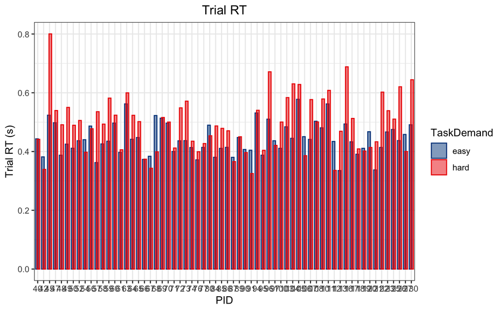

```r
df_v2_good_LEARNING %>%
  # group_by(PID) %>%
  # summarise(Trial_RT = mean(Trial_RT, na.rm=TRUE), .groups = "drop") %>%
  group_by(PID, TaskDemand) %>%
  summarise(Trial_RT = mean(Trial_RT, na.rm=TRUE), .groups = "drop") %>%
  mutate(PID = factor(PID)) %>%
  ggplot(data=., aes(x=PID, y = Trial_RT,
            color = TaskDemand, fill = TaskDemand)) +
  geom_bar(stat = "identity", position = position_dodge(0.5)) +
  scale_color_lancet()+
  scale_fill_lancet(alpha = 0.5)+
  labs(title = "Trial RT", x = "PID", y = "Trial RT (s)") +
  theme_bw() +
  theme(plot.title = element_text(hjust = 0.5))
```

boxplot

```r
df_v2_good_LEARNING %>%
  ggboxplot(data=., x="PID", y = "Trial_RT",
          color = "TaskDemand",
          width = 0.7, dodge = 0) +
  scale_color_lancet()+
  labs(title = "Trial RT", x = "PID", y = "Trial RT (s)", color = "Task Demand") +
  theme_bw() +
  theme(plot.title = element_text(hjust = 0.5))
```

#### ACC

barplot

```r
df_v2_good_LEARNING %>%
  # group_by(PID) %>%
  # summarise(Trial_ACC = mean(Trial_ACC, na.rm=TRUE), .groups = "drop") %>%
  # mutate(PID = factor(PID)) %>%
  # ggplot(data=., aes(x=PID, y = Trial_ACC)) +
  # geom_bar(stat = "identity", position = position_dodge(0.15)) +
  group_by(PID, TaskDemand) %>%
  summarise(Trial_ACC = mean(Trial_ACC, na.rm=TRUE), .groups = "drop") %>%
  mutate(PID = factor(PID)) %>%
  ggplot(data=., aes(x=PID, y = Trial_ACC,
            color = TaskDemand, fill = TaskDemand)) +
  geom_bar(stat = "identity", position = position_dodge(0.5)) +
  scale_color_lancet()+
  scale_fill_lancet(alpha = 0.5)+
  labs(title = "Trial ACC", x = "PID", y = "Trial ACC") +
  theme_bw() +
  theme(plot.title = element_text(hjust = 0.5))
```

boxplot

```r
df_v2_good_LEARNING %>%
  ggboxplot(data=., x="PID", y = "Trial_ACC",
          color = "TaskDemand",
          width = 0.7, dodge = 0) +
  scale_color_lancet()+
  labs(title = "Trial ACC", x = "PID", y = "Trial ACC", color = "Task Demand") +
  theme_bw() +
  theme(plot.title = element_text(hjust = 0.5))
```

#### A measure

barplot

```r
df_v2_good_LEARNING %>%
  # group_by(PID) %>%
  # summarise(Trial_A_measure = mean(Trial_A_measure, na.rm=TRUE), .groups = "drop") %>%
  # mutate(PID = factor(PID)) %>%
  # ggplot(data=., aes(x=PID, y = Trial_A_measure)) +
  # geom_bar(stat = "identity", position = position_dodge(0.15)) +
  group_by(PID, TaskDemand) %>%
  summarise(Trial_A_measure = mean(Trial_A_measure, na.rm=TRUE), .groups = "drop") %>%
  mutate(PID = factor(PID)) %>%
  ggplot(data=., aes(x=PID, y = Trial_A_measure,
            color = TaskDemand, fill = TaskDemand)) +
  geom_bar(stat = "identity", position = position_dodge(0.5)) +
  scale_color_lancet()+
  scale_fill_lancet(alpha = 0.5)+
  labs(title = "Trial_A_measure", x = "PID", y = "Trial_A_measure") +
  theme_bw() +
  theme(plot.title = element_text(hjust = 0.5))
```

### True Choice Phase

#### RT

barplot

```r
df_v2_good_TRUECHOICE %>%
  # group_by(PID) %>%
  # summarise(Trial_RT = mean(Trial_RT, na.rm=TRUE), .groups = "drop") %>%
  group_by(PID, TaskDemand) %>%
  summarise(Trial_RT = mean(Trial_RT, na.rm=TRUE), .groups = "drop") %>%
  mutate(PID = factor(PID)) %>%
  ggplot(data=., aes(x=PID, y = Trial_RT,
            color = TaskDemand, fill = TaskDemand)) +
  geom_bar(stat = "identity", position = position_dodge(0.5)) +
  scale_color_lancet()+
  scale_fill_lancet(alpha = 0.5)+
  labs(title = "Trial RT", x = "PID", y = "Trial RT (s)") +
  theme_bw() +
  theme(plot.title = element_text(hjust = 0.5))
```

boxplot

```r
df_v2_good_TRUECHOICE %>%
  ggboxplot(data=., x="PID", y = "Trial_RT",
          color = "TaskDemand",
          width = 0.7, dodge = 0) +
  scale_color_lancet()+
  labs(title = "Trial RT", x = "PID", y = "Trial RT (s)", color = "Task Demand") +
  theme_bw() +
  theme(plot.title = element_text(hjust = 0.5))
```

#### ACC

barplot

```r
df_v2_good_TRUECHOICE %>%
  # group_by(PID) %>%
  # summarise(Trial_ACC = mean(Trial_ACC, na.rm=TRUE), .groups = "drop") %>%
  # mutate(PID = factor(PID)) %>%
  # ggplot(data=., aes(x=PID, y = Trial_ACC)) +
  # geom_bar(stat = "identity", position = position_dodge(0.15)) +
  group_by(PID, TaskDemand) %>%
  summarise(Trial_ACC = mean(Trial_ACC, na.rm=TRUE), .groups = "drop") %>%
  mutate(PID = factor(PID)) %>%
  ggplot(data=., aes(x=PID, y = Trial_ACC,
            color = TaskDemand, fill = TaskDemand)) +
  geom_bar(stat = "identity", position = position_dodge(0.5)) +
  scale_color_lancet()+
  scale_fill_lancet(alpha = 0.5)+
  labs(title = "Trial ACC", x = "PID", y = "Trial ACC") +
  theme_bw() +
  theme(plot.title = element_text(hjust = 0.5))
```

boxplot

```r
df_v2_good_TRUECHOICE %>%
  ggboxplot(data=., x="PID", y = "Trial_ACC",
          color = "TaskDemand",
          width = 0.7, dodge = 0) +
  scale_color_lancet()+
  labs(title = "Trial ACC", x = "PID", y = "Trial ACC", color = "Task Demand") +
  theme_bw() +
  theme(plot.title = element_text(hjust = 0.5))
```

#### A measure

barplot

```r
df_v2_good_TRUECHOICE %>%
  # group_by(PID) %>%
  # summarise(Trial_A_measure = mean(Trial_A_measure, na.rm=TRUE), .groups = "drop") %>%
  # mutate(PID = factor(PID)) %>%
  # ggplot(data=., aes(x=PID, y = Trial_A_measure)) +
  # geom_bar(stat = "identity", position = position_dodge(0.15)) +
  group_by(PID, TaskDemand) %>%
  summarise(Trial_A_measure = mean(Trial_A_measure, na.rm=TRUE), .groups = "drop") %>%
  mutate(PID = factor(PID)) %>%
  ggplot(data=., aes(x=PID, y = Trial_A_measure,
            color = TaskDemand, fill = TaskDemand)) +
  geom_bar(stat = "identity", position = position_dodge(0.5)) +
  scale_color_lancet()+
  scale_fill_lancet(alpha = 0.5)+
  labs(title = "Trial_A_measure", x = "PID", y = "Trial_A_measure") +
  theme_bw() +
  theme(plot.title = element_text(hjust = 0.5))
```

### False Choice Phase

#### RT

barplot

```r
df_v2_good_FALSECHOICE %>%
  # group_by(PID) %>%
  # summarise(Trial_RT = mean(Trial_RT, na.rm=TRUE), .groups = "drop") %>%
  group_by(PID, ChoiceDemand) %>%
  summarise(Trial_RT = mean(Trial_RT, na.rm=TRUE), .groups = "drop") %>%
  mutate(PID = factor(PID)) %>%
  ggplot(data=., aes(x=PID, y = Trial_RT,
            color = ChoiceDemand, fill = ChoiceDemand)) +
  geom_bar(stat = "identity", position = position_dodge(0.5)) +
  scale_color_lancet()+
  scale_fill_lancet(alpha = 0.5)+
  labs(title = "Trial RT", x = "PID", y = "Trial RT (s)") +
  theme_bw() +
  theme(plot.title = element_text(hjust = 0.5))
```

boxplot

```r
df_v2_good_FALSECHOICE %>%
  ggboxplot(data=., x="PID", y = "Trial_RT",
          color = "ChoiceDemand",
          width = 0.7, dodge = 0) +
  scale_color_lancet()+
  labs(title = "Trial RT", x = "PID", y = "Trial RT (s)", color = "Choice Demand") +
  theme_bw() +
  theme(plot.title = element_text(hjust = 0.5))
```

#### ACC

barplot

```r
df_v2_good_FALSECHOICE %>%
  # group_by(PID) %>%
  # summarise(Trial_ACC = mean(Trial_ACC, na.rm=TRUE), .groups = "drop") %>%
  # mutate(PID = factor(PID)) %>%
  # ggplot(data=., aes(x=PID, y = Trial_ACC)) +
  # geom_bar(stat = "identity", position = position_dodge(0.15)) +
  group_by(PID, ChoiceDemand) %>%
  summarise(Trial_ACC = mean(Trial_ACC, na.rm=TRUE), .groups = "drop") %>%
  mutate(PID = factor(PID)) %>%
  ggplot(data=., aes(x=PID, y = Trial_ACC,
            color = ChoiceDemand, fill = ChoiceDemand)) +
  geom_bar(stat = "identity", position = position_dodge(0.5)) +
  scale_color_lancet()+
  scale_fill_lancet(alpha = 0.5)+
  labs(title = "Trial ACC", x = "PID", y = "Trial ACC") +
  theme_bw() +
  theme(plot.title = element_text(hjust = 0.5))
```

boxplot

```r
df_v2_good_FALSECHOICE %>%
  ggboxplot(data=., x="PID", y = "Trial_ACC",
          color = "ChoiceDemand",
          width = 0.7, dodge = 0) +
  scale_color_lancet()+
  labs(title = "Trial ACC", x = "PID", y = "Trial ACC", color = "Choice Demand") +
  theme_bw() +
  theme(plot.title = element_text(hjust = 0.5))
```

#### A measure

barplot

```r
df_v2_good_FALSECHOICE %>%
  # group_by(PID) %>%
  # summarise(Trial_A_measure = mean(Trial_A_measure, na.rm=TRUE), .groups = "drop") %>%
  # mutate(PID = factor(PID)) %>%
  # ggplot(data=., aes(x=PID, y = Trial_A_measure)) +
  # geom_bar(stat = "identity", position = position_dodge(0.15)) +
  group_by(PID, ChoiceDemand) %>%
  summarise(Trial_A_measure = mean(Trial_A_measure, na.rm=TRUE), .groups = "drop") %>%
  mutate(PID = factor(PID)) %>%
  ggplot(data=., aes(x=PID, y = Trial_A_measure,
            color = ChoiceDemand, fill = ChoiceDemand)) +
  geom_bar(stat = "identity", position = position_dodge(0.5)) +
  scale_color_lancet()+
  scale_fill_lancet(alpha = 0.5)+
  labs(title = "Trial_A_measure", x = "PID", y = "Trial_A_measure") +
  theme_bw() +
  theme(plot.title = element_text(hjust = 0.5))
```

## Check for Performance Difference between Demands

### Learning Phase

compare the RT, ACC, A measure in 1-back and 3-back trials #### RT paired by demand within participant

```r
pw_rt_v2 <-
  df_v2_good_LEARNING %>%
  group_by(PID) %>%
  t_test(RTZ ~ TaskDemand, paired = TRUE, detailed = TRUE) %>%
  add_significance() %>%
  add_xy_position(x = "TaskDemand")
table(pw_rt_v2$p.signif)
```

paired by demand across participants (means of participants)

```r
df_rt_means_de_v2 <-
  df_v2_good_LEARNING %>%
  group_by(PID, TaskDemand) %>%
  summarise(RTs = mean(Trial_RT, na.rm = TRUE), .groups = "drop")

df_rtz_means_de_v2 <-
  df_v2_good_LEARNING %>%
  group_by(PID, TaskDemand) %>%
  summarise(RTZs = mean(RTZ, na.rm = TRUE), .groups = "drop")
```

boxplot

```r
t_rt_v2 <-
  df_rt_means_de_v2 %>%
  t_test(RTs ~ TaskDemand,
         comparisons = list("easy", "hard"),paired = TRUE, detailed = TRUE) %>%
  add_xy_position(x = "TaskDemand") %>%
  add_significance()

t_rtz_v2 <-
  df_rtz_means_de_v2 %>%
  t_test(RTZs ~ TaskDemand, paired = TRUE, detailed = TRUE) %>%
  add_xy_position(x = "TaskDemand") %>%
  add_significance()

ggplot(data = df_rt_means_de_v2, aes(x = TaskDemand, y = RTs, color = TaskDemand)) +
  geom_boxplot(width = 0.5, alpha = 0.7) +
  geom_jitter(width = 0.15) +
  stat_boxplot(geom = "errorbar", width = 0.15) +
  scale_y_continuous(limits = c(0.15, 1.05))+
  scale_color_lancet()+
  stat_pvalue_manual(t_rtz_v2, y.position = 0.9,
                     label = " p = {p}{p.signif} (z-scored)", hide.ns = TRUE) +
  labs(title = "RT t-test", x = "Task Demand", y = "Trial RT (s)", color = "Task Demand") +
  theme_bw() +
  theme(plot.title = element_text(hjust = 0.5))
```

#### ACC

ACCs of Demand levels within each participant

```r
pw_acc_v2 <-
  df_v2_good_LEARNING %>%
  group_by(PID) %>%
  pairwise_t_test(Trial_ACC ~ TaskDemand, paired = TRUE, detailed = TRUE) %>%
  add_significance() %>%
  add_xy_position(x = "TaskDemand")
table(pw_acc_v2$p.adj.signif)
```

paired by demand across participants (means of participants)

```r
df_acc_means_de_v2 <-
  df_v2_good_LEARNING %>%
  group_by(PID, TaskDemand) %>%
  summarise(ACCs = mean(Trial_ACC, na.rm = TRUE), .groups = "drop")

df_accz_means_de_v2 <-
  df_v2_good_LEARNING %>%
  group_by(PID, TaskDemand) %>%
  summarise(ACCZs = mean(ACCZ, na.rm = TRUE), .groups = "drop")
```

boxplot

```r
t_acc_v2 <-
  df_acc_means_de_v2 %>%
  t_test(ACCs ~ TaskDemand, paired = TRUE, detailed = TRUE) %>%
  add_xy_position(x = "TaskDemand") %>%
  add_significance()

t_accz_v2 <-
  df_accz_means_de_v2 %>%
  t_test(ACCZs ~ TaskDemand, paired = TRUE, detailed = TRUE) %>%
  add_xy_position(x = "TaskDemand") %>%
  add_significance()

ggplot(data = df_acc_means_de_v2, aes(x = TaskDemand, y = ACCs, color = TaskDemand)) +
  geom_boxplot(width = 0.5, alpha = 0.7) +
  geom_jitter(width = 0.15) +
  stat_boxplot(geom = "errorbar", width = 0.15) +
  scale_y_continuous(limits = c(0.5, 1.05)) +
  scale_color_lancet()+
  stat_pvalue_manual(t_accz_v2, y.position = 1.02,
                     label = "p = {p}{p.signif}", hide.ns = TRUE) +
  labs(title = "ACC t-test", x = "Task Demand", y = "Trial ACC", color = "Task Demand") +
  theme_bw() +
  theme(plot.title = element_text(hjust = 0.5))
```

#### A measure

paired by demand across participants (means of participants)

```r
df_a_means_de_v2 <-
  df_v2_good_LEARNING %>%
  group_by(PID, TaskDemand) %>%
  summarise(A_measures = mean(Trial_A_measure, na.rm = TRUE), .groups = "drop")
```

boxplot

```r
t_a_v2 <-
  df_a_means_de_v2 %>%
  t_test(A_measures ~ TaskDemand, paired = TRUE, detailed = TRUE) %>%
  add_xy_position(x = "TaskDemand") %>%
  add_significance()

ggplot(data = df_a_means_de_v2,
       aes(x = TaskDemand, y = A_measures, color = TaskDemand)) +
  geom_boxplot(width = 0.5, alpha = 0.7) +
  geom_jitter( width = 0.15) +
  stat_boxplot(geom = "errorbar", width = 0.15) +
  scale_y_continuous(limits = c(0.5, 1.05)) +
  scale_color_lancet()+
  stat_pvalue_manual(t_a_v2, y.position = 1.02, label = "p = {p}{p.signif}", hide.ns = TRUE) +
  labs(title = "A_measure t-test", x = "Task Demand", y = "Trial A_measure", color = "Task Demand") +
  theme_bw() +
  theme(plot.title = element_text(hjust = 0.5))
```

### True Choice Phase

#### RT

```r
df_rt_means_de_true_choice_v2 <-
  df_v2_good_TRUECHOICE %>%
  group_by(PID, TaskDemand) %>%
  summarise(RTs = mean(Trial_RT, na.rm = TRUE), .groups = "drop")

df_rtz_means_de_true_choice_v2 <-
  df_v2_good_TRUECHOICE %>%
  group_by(PID, TaskDemand) %>%
  summarise(RTZs = mean(RTZ, na.rm = TRUE), .groups = "drop")
```

boxplot

```r
t_rt_true_choice_v2 <-
  df_rt_means_de_true_choice_v2 %>%
  t_test(RTs ~ TaskDemand, comparisons = list("easy", "hard"), paired = FALSE, detailed = TRUE) %>%
  add_xy_position(x = "TaskDemand") %>%
  add_significance()

t_rtz_true_choice_v2 <-
  df_rtz_means_de_true_choice_v2 %>%
  t_test(RTZs ~ TaskDemand,paired = FALSE, detailed = TRUE) %>%
  add_xy_position(x = "TaskDemand") %>%
  add_significance()

ggplot(data = df_rt_means_de_true_choice_v2, aes(x = TaskDemand, y = RTs, color = TaskDemand)) +
  geom_boxplot(width = 0.5, alpha = 0.7) +
  geom_jitter(width = 0.15, alpha = 0.7) +
  stat_boxplot(geom = "errorbar", width = 0.15) +
  scale_y_continuous(limits = c(0.15, 1.05))+
  scale_color_lancet()+
  stat_pvalue_manual(t_rtz_true_choice_v2, y.position = 0.9,
                     label = " p = {p}{p.signif} (z-scored)", hide.ns = FALSE) +
  labs(title = "RT t-test", x = "Task Demand", y = "Trial RT (s)", color = "Task Demand") +
  theme_bw() +
  theme(plot.title = element_text(hjust = 0.5))
```

#### ACC

```r
df_acc_means_de_true_choice_v2 <-
  df_v2_good_TRUECHOICE %>%
  group_by(PID, TaskDemand) %>%
  summarise(ACCs = mean(Trial_ACC, na.rm = TRUE), .groups = "drop")

df_accz_means_de_true_choice_v2 <-
  df_v2_good_TRUECHOICE %>%
  group_by(PID, TaskDemand) %>%
  summarise(ACCZs = mean(ACCZ, na.rm = TRUE), .groups = "drop")
```

boxplot

```r
t_acc_true_choice_v2 <-
  df_acc_means_de_true_choice_v2 %>%
  t_test(ACCs ~ TaskDemand, paired = FALSE, detailed = TRUE) %>%
  add_xy_position(x = "TaskDemand") %>%
  add_significance()

t_accz_true_choice_v2 <-
  df_accz_means_de_true_choice_v2 %>%
  t_test(ACCZs ~ TaskDemand, paired = FALSE, detailed = TRUE) %>%
  add_xy_position(x = "TaskDemand") %>%
  add_significance()

ggplot(data = df_acc_means_de_true_choice_v2, aes(x = TaskDemand, y = ACCs, color = TaskDemand)) +
  geom_boxplot(width = 0.5, alpha = 0.7) +
  geom_jitter(width = 0.15, alpha = 0.7) +
  stat_boxplot(geom = "errorbar", width = 0.15) +
  scale_y_continuous(limits = c(0.5, 1.05)) +
  scale_color_lancet()+
  stat_pvalue_manual(t_accz_true_choice_v2, y.position = 1.02,
                     label = "p = {p}{p.signif}", hide.ns = FALSE) +
  labs(title = "ACC t-test", x = "Task Demand", y = "Trial ACC", color = "Task Demand") +
  theme_bw() +
  theme(plot.title = element_text(hjust = 0.5))
```

#### A measure

```r
df_a_means_de_true_choice_v2 <-
  df_v2_good_TRUECHOICE %>%
  group_by(PID, TaskDemand) %>%
  summarise(A_measures = mean(Trial_A_measure, na.rm = TRUE), .groups = "drop")
```

boxplot

```r
t_a_true_choice_v2 <-
  df_a_means_de_true_choice_v2 %>%
  t_test(A_measures ~ TaskDemand, paired = FALSE, detailed = TRUE) %>%
  add_xy_position(x = "TaskDemand") %>%
  add_significance()

ggplot(data = df_a_means_de_true_choice_v2, aes(x = TaskDemand, y = A_measures, color = TaskDemand)) +
  geom_boxplot(width = 0.5, alpha = 0.7) +
  geom_jitter( width = 0.15, alpha = 0.7) +
  stat_boxplot(geom = "errorbar", width = 0.15) +
  scale_y_continuous(limits = c(0.5, 1.05)) +
  scale_color_lancet()+
  stat_pvalue_manual(t_a_true_choice_v2, y.position = 1.02, label = "p = {p}{p.signif}", hide.ns = FALSE) +
  labs(title = "A_measure t-test", x = "Task Demand", y = "Trial A_measure", color = "Task Demand") +
  theme_bw() +
  theme(plot.title = element_text(hjust = 0.5))
```

### False Choice Phase

#### RT

```r
df_rt_means_de_false_choice_v2 <-
  df_v2_good_FALSECHOICE %>%
  group_by(PID, ChoiceDemand) %>%
  summarise(RTs = mean(Trial_RT, na.rm = TRUE), .groups = "drop")

df_rtz_means_de_false_choice_v2 <-
  df_v2_good_FALSECHOICE %>%
  group_by(PID, ChoiceDemand) %>%
  summarise(RTZs = mean(RTZ, na.rm = TRUE), .groups = "drop")
```

boxplot

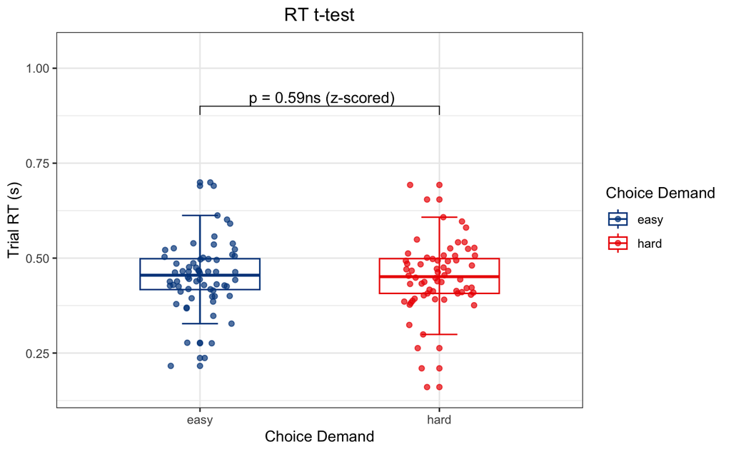

```r
t_rt_false_choice_v2 <-
  df_rt_means_de_false_choice_v2 %>%
  t_test(RTs ~ ChoiceDemand, comparisons = list("easy", "hard"), paired = FALSE, detailed = TRUE) %>%
  add_xy_position(x = "ChoiceDemand") %>%
  add_significance()

t_rtz_false_choice_v2 <-
  df_rtz_means_de_false_choice_v2 %>%
  t_test(RTZs ~ ChoiceDemand,paired = FALSE, detailed = TRUE) %>%
  add_xy_position(x = "ChoiceDemand") %>%
  add_significance()

ggplot(data = df_rt_means_de_false_choice_v2, aes(x = ChoiceDemand, y = RTs, color = ChoiceDemand)) +
  geom_boxplot(width = 0.5, alpha = 0.7) +
  geom_jitter(width = 0.15, alpha = 0.7) +
  stat_boxplot(geom = "errorbar", width = 0.15) +
  scale_y_continuous(limits = c(0.15, 1.05))+
  scale_color_lancet()+
  stat_pvalue_manual(t_rtz_false_choice_v2, y.position = 0.9,
                     label = " p = {p}{p.signif} (z-scored)", hide.ns = FALSE) +
  labs(title = "RT t-test", x = "Choice Demand", y = "Trial RT (s)", color = "Choice Demand") +
  theme_bw() +
  theme(plot.title = element_text(hjust = 0.5))
```

#### ACC

```r
df_acc_means_de_false_choice_v2 <-
  df_v2_good_FALSECHOICE %>%
  group_by(PID, ChoiceDemand) %>%
  summarise(ACCs = mean(Trial_ACC, na.rm = TRUE), .groups = "drop")

df_accz_means_de_false_choice_v2 <-
  df_v2_good_FALSECHOICE %>%
  group_by(PID, ChoiceDemand) %>%
  summarise(ACCZs = mean(ACCZ, na.rm = TRUE), .groups = "drop")
```

boxplot

```r
t_acc_false_choice_v2 <-
  df_acc_means_de_false_choice_v2 %>%
  t_test(ACCs ~ ChoiceDemand, paired = FALSE, detailed = TRUE) %>%
  add_xy_position(x = "ChoiceDemand") %>%
  add_significance()

t_accz_false_choice_v2 <-
  df_accz_means_de_false_choice_v2 %>%
  t_test(ACCZs ~ ChoiceDemand, paired = FALSE, detailed = TRUE) %>%
  add_xy_position(x = "ChoiceDemand") %>%
  add_significance()

ggplot(data = df_acc_means_de_false_choice_v2, aes(x = ChoiceDemand, y = ACCs, color = ChoiceDemand)) +
  geom_boxplot(width = 0.5, alpha = 0.7) +
  geom_jitter(width = 0.15, alpha = 0.7) +
  stat_boxplot(geom = "errorbar", width = 0.15) +
  scale_y_continuous(limits = c(0.5, 1.05)) +
  scale_color_lancet()+
  stat_pvalue_manual(t_accz_false_choice_v2, y.position = 1.02,
                     label = "p = {p}{p.signif}", hide.ns = FALSE) +
  labs(title = "ACC t-test", x = "Choice Demand", y = "Trial ACC", color = "Choice Demand") +
  theme_bw() +
  theme(plot.title = element_text(hjust = 0.5))
```

#### A measure

```r
df_a_means_de_false_choice_v2 <-
  df_v2_good_FALSECHOICE %>%
  group_by(PID, ChoiceDemand) %>%
  summarise(A_measures = mean(Trial_A_measure, na.rm = TRUE), .groups = "drop")
```

boxplot

```r
t_a_false_choice_v2 <-
  df_a_means_de_false_choice_v2 %>%
  t_test(A_measures ~ ChoiceDemand, paired = FALSE, detailed = TRUE) %>%
  add_xy_position(x = "ChoiceDemand") %>%
  add_significance()

ggplot(data = df_a_means_de_false_choice_v2, aes(x = ChoiceDemand, y = A_measures, color = ChoiceDemand)) +
  geom_boxplot(width = 0.5, alpha = 0.7) +
  geom_jitter( width = 0.15, alpha = 0.7) +
  stat_boxplot(geom = "errorbar", width = 0.15) +
  scale_y_continuous(limits = c(0.5, 1.05)) +
  scale_color_lancet()+
  stat_pvalue_manual(t_a_false_choice_v2, y.position = 1.02, label = "p = {p}{p.signif}", hide.ns = FALSE) +
  labs(title = "A_measure t-test", x = "Choice Demand", y = "Trial A_measure", color = "Choice Demand") +
  theme_bw() +
  theme(plot.title = element_text(hjust = 0.5))
```

### Choice RT

```r
df_v2_good_FALSECHOICE_remove_outliers <-
  df_v2_good_FALSECHOICE %>%
  group_by(PID) %>%
  dplyr::filter(abs(scale(ChoiceRT)) <= 2.5) %>%
  ungroup()
```

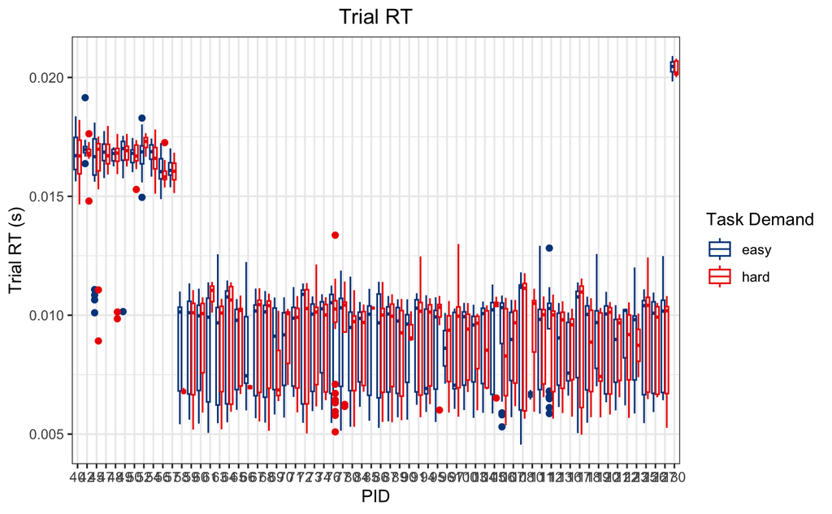

```r
df_v2_good_FALSECHOICE_remove_outliers %>%
  ggboxplot(data=., x="PID", y = "ChoiceRT",
          color = "ChoiceDemand",
          width = 0.7, dodge = 0) +
  scale_color_lancet()+
  labs(title = "Trial RT", x = "PID", y = "Trial RT (s)", color = "Task Demand") +
  theme_bw() +
  theme(plot.title = element_text(hjust = 0.5))
```

boxplot

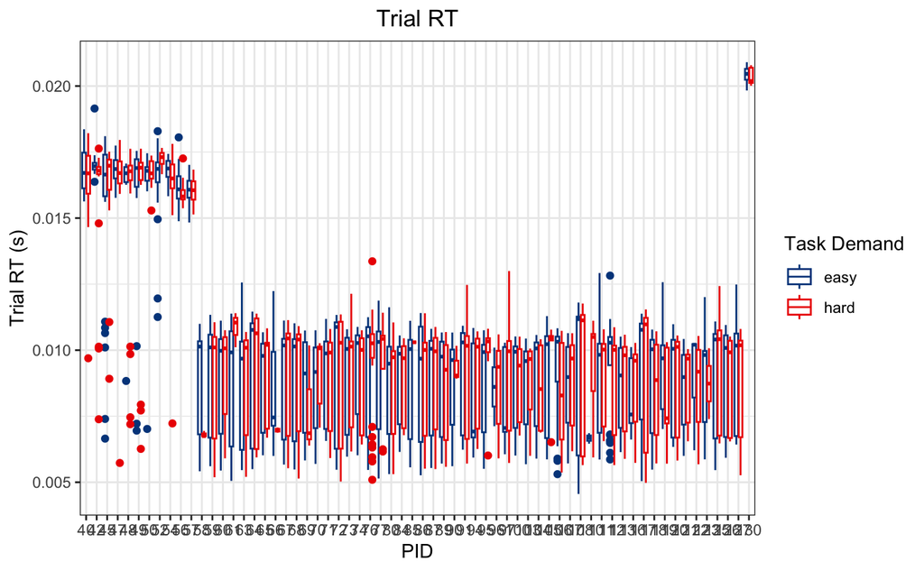

```r
df_v2_good_FALSECHOICE %>%
  ggboxplot(data=., x="PID", y = "ChoiceRT",
          color = "ChoiceDemand",
          width = 0.7, dodge = 0) +
  scale_color_lancet()+
  labs(title = "Trial RT", x = "PID", y = "Trial RT (s)", color = "Task Demand") +
  theme_bw() +
  theme(plot.title = element_text(hjust = 0.5))
```

## Check for Performance Difference between Transitions

compare the RT, ACC and A measure in repetition and switch trials ### Learning Phase #### Rt paired by transition within each participant

```r
pw_rt_v2 <-
  df_v2_good_LEARNING %>%
  filter(! is.na(TrialTransition)) %>%
  group_by(PID) %>%
  t_test(Trial_RT ~ TrialTransition, paired = FALSE, detailed = TRUE) %>%
  add_significance() %>%
  add_xy_position(x = "TrialTransition")
table(pw_rt_v2$p.signif)
```

paired by transition across participants (means of participants)

```r
df_rt_means_tr_v2 <-
  df_v2_good_LEARNING %>%
  filter(! is.na(TrialTransition)) %>%
  group_by(PID, TrialTransition) %>%
  summarise(RTs = mean(Trial_RT, na.rm = TRUE), .groups = "drop")

df_rtz_means_tr_v2 <-
  df_v2_good_LEARNING %>%
  filter(! is.na(TrialTransition)) %>%
  group_by(PID, TrialTransition) %>%
  summarise(RTZs = mean(RTZ, na.rm = TRUE), .groups = "drop")
```

boxplot

```r
t_rt_v2 <-
  df_rt_means_tr_v2 %>%
  t_test(RTs ~ TrialTransition, paired = TRUE, detailed = TRUE) %>%
  add_xy_position(x = "TrialTransition") %>%
  add_significance()

t_rtz_v2 <-
  df_rtz_means_tr_v2 %>%
  t_test(RTZs ~ TrialTransition, paired = TRUE, detailed = TRUE) %>%
  add_xy_position(x = "TrialTransition") %>%
  add_significance()

ggplot(data = df_rt_means_tr_v2, aes(x = TrialTransition, y = RTs, color = TrialTransition)) +
  geom_boxplot(width = 0.5, alpha = 0.7) +
  geom_jitter(width = 0.15) +
  scale_color_jco()+
  stat_boxplot(geom = "errorbar", width = 0.15) +
  stat_pvalue_manual(t_rtz_v2, y.position = 0.75,
                     label = "{p.signif} (z-scored)", hide.ns = FALSE) +
  # stat_pvalue_manual(t_rt, label = " p.signif", hide.ns = TRUE) +
  scale_y_continuous(limits = c(0.15, 1.05)) +
  labs(title = "RT t-test", x = "Trial Transition", y = "Trial RT", color = "Trial Transition") +
  theme_bw() +
  theme(plot.title = element_text(hjust = 0.5))
```

#### ACC

paired by transition within each participant

```r
pw_acc_v2 <-
  df_v2_good_LEARNING %>%
  filter(! is.na(TrialTransition)) %>%
  group_by(PID) %>%
  t_test(Trial_ACC ~ TrialTransition, paired = FALSE, detailed = TRUE) %>%
  add_significance() %>%
  add_xy_position(x = "TrialTransition")
table(pw_acc_v2$p.signif)
```

paired by transition across participants (means of participants)

```r
df_acc_means_tr_v2 <-
  df_v2_good_LEARNING %>%
  filter(! is.na(TrialTransition)) %>%
  group_by(PID, TrialTransition) %>%
  summarise(ACCs = mean(Trial_ACC, na.rm = TRUE), .groups = "drop")
```

boxplot

```r
t_acc_v2 <-
  df_acc_means_tr_v2 %>%
  t_test(ACCs ~ TrialTransition, paired = TRUE, detailed = TRUE) %>%
  add_xy_position(x = "TrialTransition") %>%
  add_significance()

ggplot(data = df_acc_means_tr_v2,
       aes(x = TrialTransition, y = ACCs, color = TrialTransition)) +  #, label=PID
  geom_boxplot(width = 0.5, alpha = 0.7) +
  geom_jitter(width = 0.15) +
  scale_color_jco()+
  # geom_label_repel(aes(color=TrialTransition),
  #                  max.overlaps = nrow(df_acc_means_tr_v2)) +
  stat_boxplot(geom = "errorbar", width = 0.15) +
  stat_pvalue_manual(t_acc_v2, y.position = 0.99,
                     label = "{p.signif}", hide.ns = FALSE) +
  scale_y_continuous(limits = c(0.5, 1.05)) +
  labs(title = "ACC t-test", x = "Trial Transition", y = "Trial ACC", color = "Trial Transition") +
  theme_bw() +
  theme(plot.title = element_text(hjust = 0.5))
# excluded PID 109 ACC < 0.5
```

#### A measure

paired by transition across participants (means of participants)

```r
df_a_means_tr_v2 <-
  df_v2_good_LEARNING %>%
  filter(! is.na(TrialTransition)) %>%
  group_by(PID, TrialTransition) %>%
  summarise(A_measures = mean(Trial_A_measure, na.rm = TRUE), .groups = "drop")
```

boxplot

```r
t_a_v2 <-
  df_a_means_tr_v2 %>%
  t_test(A_measures ~ TrialTransition, paired = TRUE, detailed = TRUE) %>%
  add_xy_position(x = "Trial_Transition") %>%
  add_significance()

ggplot(data = df_a_means_tr_v2, aes(x = TrialTransition, y = A_measures, color = TrialTransition)) +
  geom_boxplot(width = 0.5, alpha = 0.7) +
  geom_jitter(width = 0.15) +
  scale_color_jco()+
  stat_boxplot(geom = "errorbar", width = 0.15) +
  stat_pvalue_manual(t_a_v2, xmin = "group1", xmax = "group2",
                     y.position = 0.98,
                     label = "{p.signif}", hide.ns = FALSE) +
  scale_y_continuous(limits = c(0.5, 1.05)) +
  labs(title = "A_measure t-test", x = "Trial Transition", y = "Trial A_measure", color = "Trial Transition") +
  theme_bw() +
  theme(plot.title = element_text(hjust = 0.5))
```

## Check for DemandRatings (Demand-Manipulation Check)

```r
df_dr_means_de_v2 <-
  df_v2_DEMANDRATING %>%
  filter(!PID %in% excludedPIDs_v2) %>%
  group_by(PID, DemandCheck) %>%
  summarise(DR_aves = mean(DemandRating, na.rm=TRUE),
            DR_aveZs = mean(DemandRatingZ, na.rm=TRUE),
            .groups = "drop")

t_dr_v2 <-
  df_dr_means_de_v2 %>%
  t_test(DR_aveZs ~ DemandCheck, paired = TRUE, detailed = TRUE) %>%
  add_xy_position(x = "DemandCheck") %>%
  add_significance()
```

boxplot (higher rating = rated as more demanding)

```r
ggplot(data = df_dr_means_de_v2, aes(x = DemandCheck, y = DR_aves, color = DemandCheck)) +
  geom_boxplot(width = 0.5, alpha = 0.7) +
  geom_jitter() +
  stat_boxplot(geom = "errorbar", width = 0.15) +
  stat_pvalue_manual(t_dr_v2, y = 105, step.increase = 0.2,
                     label = "p = {p}{p.adj.signif}", hide.ns = TRUE) +
  scale_color_manual(labels=c("1-Back", "2-Back", "3-Back"),
                     values = c("#00468BFF", "#42B540FF", "#ED0000FF")) +
  scale_x_discrete(labels = c("1-Back", "2-Back", "3-Back")) +
  labs(title = "DemandRating t-test", x = "TrialDemand", y = "DemandRating_ave",
       color = "DemandCheck") +
  theme_bw() +
  theme(plot.title = element_text(hjust = 0.5))
```

The participant should be excluded due to rating 1-back as harder?

```r
df_dr_means_de_diff_v2 <-
  df_dr_means_de_v2 %>%
  select(-DR_aves) %>%
  pivot_wider(names_from = DemandCheck, names_prefix = "DR_aveZs_" ,values_from = DR_aveZs) %>%
  group_by(PID) %>%
  mutate(DR_aveZs_diff = DR_aveZs_hard -DR_aveZs_easy) %>%
  ungroup() %>%
  mutate(DemandCheckType = ifelse(DR_aveZs_diff > 0, "3_as_harder", "1_as_harder"))

# ggplot(data = df_dr_means_de_diff, aes(x="", y = DR_aveZs_diff, color=DemandCheckType, label=PID)) +
ggplot(data = df_dr_means_de_diff_v2, aes(x="", y = DR_aveZs_diff, color=DemandCheckType)) +
  geom_boxplot(position="identity", width = 0.2, alpha = 0.9) +
  geom_jitter(width = 0.2) +
  # geom_label_repel(aes(color=DemandCheckType), max.overlaps = nrow(df_dr_means_de_diff)) +
  scale_color_d3()+
  labs(title = "DemandRating_diff (hard-easy)", x = "", y = "DemandRating_aveZ_diff") +
  theme_bw() +
  theme(plot.title = element_text(hjust = 0.5))
```

## Online Ratings

### Descriptive Analysis

histogram of OnlineRatingZ

```r
df_v2_good_LEARNING %>%
  group_by(PID) %>%
  summarise(OnlineRatingZ = mean(OnlineRatingZ, ra.rm = TRUE)) %>%
  ggplot(aes(x = OnlineRatingZ)) +
  geom_histogram(position = position_dodge(width = 0.6), bins = 5, alpha = 0.8)+
  # scale_x_continuous(limits = c(-1, 1)) +
  labs(title = "Rating Means of participants", x = "Ratings(z-scored)", y = "Counts") +
  theme_bw() +
  theme(plot.title = element_text(hjust = 0.5))
```

separate distributions of different demands

```r
df_v2_good_LEARNING %>%
  group_by(PID, TaskDemand) %>%
  summarise(OnlineRatingZ = mean(OnlineRatingZ, ra.rm = TRUE), .groups = "drop") %>%
  ggplot(aes(x = OnlineRatingZ, color  = TaskDemand, fill = TaskDemand)) +
  geom_histogram(position = position_dodge(width = 0.25), bins = 10, alpha = 0.7)+
  scale_x_continuous(breaks = seq(-5, 5)) +
  scale_color_lancet() +
  scale_fill_lancet() +
  labs(title = "Rating Means of participants", x = "Ratings(z-scored)", y = "Counts", fill = "Task Demand") +
  guides(color = "none") +
  theme_bw() +
  theme(plot.title = element_text(hjust = 0.5))
```

### Rating ~ Task Demand (easy / hard)

#### boxplot of raw OnlineRatings (means of participants)

```r
df_ra_means_de_v2 <-
  df_v2_good_LEARNING %>%
  group_by(PID, TaskDemand) %>%
  summarise(ISI = mean(ISI, na.rm=TRUE),
    OnlineRatings = mean(OnlineRating, na.rm = TRUE),
            .groups = "drop") %>%
  group_by(PID) %>%
  mutate(OnlineRatings_diff =
           OnlineRatings[TaskDemand == "easy"] - OnlineRatings[TaskDemand == "hard"],
         aversive = ifelse(OnlineRatings_diff > 0, "demand_aversive", "no_demand_aversive")) %>%
  ungroup()
```

```r
t_ra_v2 <-
  df_ra_means_de_v2 %>%
  t_test(OnlineRatings ~ TaskDemand,  detailed = TRUE, paired = TRUE) %>%
  add_xy_position(x = "TaskDemand") %>%
  add_significance()


df_ra_means_de_v2 %>%
  ggplot(aes(x = TaskDemand, y = OnlineRatings, color = TaskDemand)) +
  geom_boxplot(position = "identity", alpha = 0.7, width = 0.5, outlier.color = "black") +
  stat_boxplot(geom = "errorbar", width = 0.15) +
  geom_jitter(width = 0.15) +
  scale_color_lancet() +
  stat_summary(fun = mean, geom = "point", shape = 17, color = "black", size = 2) +
  stat_pvalue_manual(t_ra_v2, y.position = 102, label = "p = {p}{p.signif}") +
  labs(title = "OnlineRating t-test", x = "Task Demand", y = "Rating(raw)",
       color = "Task Demand") +
  theme_bw() +
  theme(plot.title = element_text(hjust = 0.5))
```

#### boxplot of OnlineRatingZ (means of participants)

```r
df_ra_means_de_v2 <-
  df_v2_good_LEARNING %>%
  group_by(PID, TaskDemand) %>%
  dplyr::summarise(ISI = mean(ISI, na.rm=TRUE),
            CueMapping = first(CueMapping),
            Gender = first(Gender),
            OnlineRatingZs = mean(OnlineRatingZ),
            .groups = "drop")
```

```r
t_raz_v2 <-
  df_ra_means_de_v2 %>%
  t_test(OnlineRatingZs ~ TaskDemand, detailed = TRUE, paired = TRUE) %>%
  add_significance() %>%
  add_xy_position(x = "TaskDemand")
# There's only one comparison between the two levels of TaskDemand so no "adjustment" was applied.
# And thus, no p.adj in the output.

df_ra_means_de_v2 %>%
  ggplot(aes(x = TaskDemand, y = OnlineRatingZs, color = TaskDemand)) +
  geom_boxplot(position = "identity", alpha = 0.7, width = 0.5, outlier.color = "black") +
  stat_boxplot(geom = "errorbar", width = 0.15) +
  geom_jitter(width = 0.15) +
  scale_color_lancet() +
  stat_summary(fun = mean, geom = "point", shape = 17, color = "black", size = 2) +
  stat_pvalue_manual(t_raz_v2, y.position = 1.1, label = "p = {p}{p.signif}", hide.ns = FALSE) +
  labs(title = "OnlineRating t-test", x = "Task Demand", y = "Rating(z-scored)",
       color = "TaskDemand") +
  theme_bw() +
  theme(plot.title = element_text(hjust = 0.5))
```

#### RatingZ-pairs of each participant in different demands

```r
df_ra_means_de_v2 %>%
  ggpaired(x = "TaskDemand", y = "OnlineRatingZs", id="PID",
           color = "TaskDemand", line.color = "grey", palette = "lancet") +
  stat_summary(fun = "mean", shape = 17) +
  stat_compare_means(method = "t.test", paired = TRUE, label = "p", label.x = 1.5) +
  labs(title = "Rating pairs", x = "Task Demand", y = "Rating(z-scored)",
       color = "Task Demand") +
  theme_bw() +
  theme(plot.title = element_text(hjust = 0.5))
```

#### Demand Aversiveness

(easy - hard) > 0 or < 0

```r
df_ra_means_de_diff_v2 <-
  df_ra_means_de_v2 %>%
  group_by(PID) %>%
  summarise(
    OnlineRatingZs_diff = OnlineRatingZs[TaskDemand == "easy"] - OnlineRatingZs[TaskDemand == "hard"],
    DemandAversive_on = ifelse(OnlineRatingZs_diff > 0, "demand_aversive", "no_demand_aversive"),
    .groups = "drop")
```

```r
df_ra_means_de_diff_v2 %>%
  ggplot(aes(x="", y=OnlineRatingZs_diff))+
  geom_boxplot(width = 0.5, outlier.color="red")+
  stat_boxplot(geom = "errorbar", width = 0.15) +
  geom_jitter(aes(color=DemandAversive_on), width = 0.15) +
  scale_color_d3()+
  geom_hline(yintercept = 0, color = "red", linetype = "dashed") +
  labs(title = "Rating Diff (easy - hard)", x = "", y = "Rating(z-scored)") +
  theme_bw() +
  theme(plot.title = element_text(hjust = 0.5))
```

```r
table(df_ra_means_de_diff_v2$DemandAversive_on)
```

```r
df_ra_means_de_v2_wide <-
  df_ra_means_de_v2 %>%
  pivot_wider(values_from = OnlineRatingZs, names_from = TaskDemand,
              names_glue = "OnlineRatingZs_{TaskDemand}")
```

```r
df_v2_good_LEARNING <-
  df_v2_good_LEARNING %>%
  merge(df_ra_means_de_diff_v2[, c("PID", "DemandAversive_on")], by="PID", all.x = T)
```

#### boxplot of OnlineRatingZ grouped by aversiveness (means of participants)

```r
df_ra_means_de_v2 <-
  df_v2_good_LEARNING %>%
  group_by(PID, TaskDemand, DemandAversive_on) %>%
  summarise(ISI = mean(ISI, na.rm=TRUE),
            CueMapping = first(CueMapping),
            Gender = first(Gender),
            OnlineRatingZs = mean(OnlineRatingZ, na.rm = TRUE),
            .groups = "drop")
```

```r
t_raz_v2 <-
  df_ra_means_de_v2 %>%
  group_by(DemandAversive_on) %>%
  t_test(OnlineRatingZs ~ TaskDemand, detailed = TRUE, paired = TRUE) %>%
  add_significance() %>%
  add_xy_position(x = "DemandAversive")
# There's only one comparison between the two levels of TaskDemand so no "adjustment" was applied.
# And thus, no p.adj in the output.

df_ra_means_de_v2 %>%
  ggplot(data=., aes(x = DemandAversive_on, y = OnlineRatingZs)) +
  geom_boxplot(aes(color = TaskDemand),
               position = position_dodge(width = 0.5),
            alpha = 0.7, outlier.color = "black") +
  stat_boxplot(aes(color = TaskDemand),
               geom = "errorbar", width = 0.15,
               position = position_dodge(width = 0.5)) +
  geom_jitter(aes(color = TaskDemand),
              position = position_dodge2(width = 0.5)) +
  stat_summary(aes(x = DemandAversive_on, y = OnlineRatingZs,
                   color = TaskDemand),
               fun = mean,
               geom = "point", shape = 17, size = 2,
               position = position_dodge(0.5)) +
  stat_pvalue_manual(t_raz_v2, y.position = 1.1,
                     label = "p = {p}{p.signif}", hide.ns = FALSE) +
  scale_color_lancet() +
  labs(title = "OnlineRating t-test",
       x = "Demand Aversive", y = "Rating(z-scored)",
       color = "TaskDemand") +
  theme_bw() +
  theme(plot.title = element_text(hjust = 0.5))
```

Cohen’s d effect size

```r
# collapse across all participants
cohen_d_ra_de_v2 <-
  effsize::cohen.d(OnlineRatingZ ~ TaskDemand | Subject(PID), paired = TRUE,
                               data = df_v2_good_LEARNING)
cohen_d_ra_de_v2
```

```r
# means of participants
cohen_d_ra_means_de_v2 <-
  cohen.d(OnlineRatingZs ~ TaskDemand | Subject(PID), paired = TRUE,
                               data = df_ra_means_de_v2)
cohen_d_ra_means_de_v2
```

#### line plot of means by trial (points are means of each participant)

```r
df_means_by_trial_v2 <-
  df_v2_good_LEARNING %>%
  # filter(TrialN != 1) %>%
  group_by(PID, TaskDemand, TrialN) %>%
  summarise(OnlineRatingZ = mean(OnlineRatingZ, na.rm=TRUE),
            RTZ = mean(RTZ, na.rm=TRUE),
            ACCZ = mean(ACCZ, na.rm=TRUE,),
            .groups = "drop")
```

```r
ggplot(data = df_means_by_trial_v2,
       aes(x = TrialN, y = OnlineRatingZ, group = TrialN,
             color = TaskDemand, fill = TaskDemand)) +
  # geom_rect(xmin = 50.45, xmax = 50.55, ymin = -Inf, ymax = Inf,
  #           color = "gray", fill = "gray", alpha = 0.2) +
  geom_boxplot(width = 0.9, position = position_dodge(width = 0.9), alpha = 0.8,
              outlier.shape = 8, outlier.size = 2) +
  stat_boxplot(geom = "errorbar", width = 0.15) +
  geom_point(shape = 1) +
  stat_summary(fun = mean, geom = "line", aes(group = TaskDemand)) +
  stat_summary(fun = mean, geom = "point", aes(group = TaskDemand, color = TaskDemand)) +
  scale_x_continuous(limits = c(0, 51), breaks = seq(1, 50, 1))+
  scale_color_lancet() +
  scale_fill_lancet() +
  labs(title = "Ratings by Trial (means across participants)", x = "TrialN", y = "Rating (z-scored)") +
  theme_bw() +
  theme(plot.title = element_text(hjust = 0.5),
        axis.text.x = element_text(size = 5) )
```

#### lines of each participant

All

```r
df_v2_good_LEARNING %>%
  ggplot(data = ., aes(x = TrialIndex, y = OnlineRatingZ,
                                group = interaction(PID, TaskDemand),
                                color = TaskDemand)) +
  geom_rect(xmin = 50.45, xmax = 50.55, ymin = -Inf, ymax = Inf,
            color = "gray", fill = "gray", alpha = 0.2) +
  geom_point() +
  geom_line(aes(linetype = TaskDemand), show.legend = FALSE) +
  scale_color_lancet() +
  scale_x_continuous(limits = c(1, 51), breaks = seq(1, 50, 1))+
  labs(title = "Ratings by Trial (means within participant)",
       x = "Trial Index", y = "Rating (z-scored)",
       color = "Task Demand") +
  theme_bw() +
  theme(plot.title = element_text(hjust = 0.5),
        axis.text.x = element_text(size = 5))
```

participant with demand aversiveness

```r
df_v2_good_LEARNING %>%
  filter(DemandAversive == "demand_aversive") %>%
  ggplot(data = ., aes(x = TrialIndex, y = OnlineRatingZ,
                                group = interaction(PID, TaskDemand),
                                color = TaskDemand)) +
  geom_rect(xmin = 50.45, xmax = 50.55, ymin = -Inf, ymax = Inf,
            color = "gray", fill = "gray", alpha = 0.2) +
  geom_point() +
  geom_line(aes(linetype = TaskDemand), show.legend = FALSE) +
  scale_color_lancet() +
  scale_x_continuous(limits = c(1, 51), breaks = seq(1, 50, 1))+
  labs(title = "Ratings by Trial (means within participant)",
       x = "Trial Index", y = "Rating (z-scored)",
       color = "Task Demand") +
  theme_bw() +
  theme(plot.title = element_text(hjust = 0.5),
        axis.text.x = element_text(size = 5))
```

participant without demand aversiveness

```r
df_v2_good_LEARNING %>%
  filter(DemandAversive == "no_demand_aversive") %>%
  ggplot(data = ., aes(x = TrialIndex, y = OnlineRatingZ,
                                group = interaction(PID, TaskDemand),
                                color = TaskDemand)) +
  geom_rect(xmin = 50.45, xmax = 50.55, ymin = -Inf, ymax = Inf,
            color = "gray", fill = "gray", alpha = 0.2) +
  geom_point() +
  geom_line(aes(linetype = TaskDemand), show.legend = FALSE) +
  scale_color_lancet() +
  scale_x_continuous(limits = c(1, 51), breaks = seq(1, 50, 1))+
  labs(title = "Ratings by Trial (means within participant)",
       x = "Trial Index", y = "Rating (z-scored)",
       color = "Task Demand") +
  theme_bw() +
  theme(plot.title = element_text(hjust = 0.5),
        axis.text.x = element_text(size = 5))
```

#### check for extreme PID

PID 74 has extremely low rating on Trial_42 (easy)

```r
df_means_by_trial_one_v2 <-
  df_v2_good_LEARNING %>%
  # filter(TrialN != 1) %>%
  filter(PID == 74 & TrialN == 42) %>%
  group_by(PID, TaskDemand, TrialN) %>%
  summarise(OnlineRatingZ = mean(OnlineRatingZ, na.rm=TRUE),
            RTZ = mean(RTZ, na.rm=TRUE),
            ACCZ = mean(ACCZ, na.rm=TRUE,),
            .groups = "drop")
```

```r
ggplot(data = df_means_by_trial_one,
       aes(x = TrialN, y = OnlineRatingZ, group = TrialN,
             color = TaskDemand, fill = TaskDemand)) +
  # geom_rect(xmin = 50.45, xmax = 50.55, ymin = -Inf, ymax = Inf,
  #           color = "gray", fill = "gray", alpha = 0.2) +
  geom_boxplot(width = 0.8, position = position_dodge(width = 0.8),
               alpha = 0.8, outlier.color = "black") +
  stat_boxplot(geom = "errorbar", width = 0.15) +
  geom_jitter(shape = 1) +
  stat_summary(fun = mean, geom = "line", aes(group = TaskDemand)) +
  stat_summary(fun = mean, geom = "point", aes(group = TaskDemand, color = TaskDemand)) +
  scale_x_continuous(limits = c(1, 51), breaks = seq(1, 50, 1))+
  scale_color_lancet() +
  scale_fill_lancet() +
  labs(title = "Ratings by Trial (selected participants)", x = "TrialN", y = "Rating (z-scored)") +
  theme_bw() +
  theme(plot.title = element_text(hjust = 0.5),
        axis.text.x = element_text(size = 5) )
```

trial-by-trial ratings plot by TaskDemand (grandmeans of participants’ means)

```r
df_grandmeans_by_trial_v2 <-
  df_means_by_trial_v2 %>%
  group_by(TaskDemand, TrialN) %>%
  summarise(OnlineRatingZ = mean(OnlineRatingZ, na.rm=TRUE),
            RTZ = mean(RTZ, na.rm=TRUE),
            ACCZ = mean(ACCZ, na.rm=TRUE,),
            .groups = "drop")
```

```r
ggplot(data = df_grandmeans_by_trial_v2, aes(x = TrialN, y = OnlineRatingZ, group = TrialN,
             color = TaskDemand, fill = TaskDemand)) +
  # geom_rect(xmin = 50.45, xmax = 50.55, ymin = -Inf, ymax = Inf,
  #           color = "gray", fill = "gray", alpha = 0.2) +
  # geom_boxplot(width = 0.8, position = position_dodge(width = 0.8),
  #              alpha = 0.5, outlier.color = "black") +
  # stat_boxplot(geom = "errorbar", width = 0.15) +
  # geom_jitter(shape = 1) +
  geom_point()+
  stat_summary(fun = mean, geom = "line", aes(group = TaskDemand)) +
  stat_summary(fun = mean, geom = "point", aes(group = TaskDemand, color = TaskDemand)) +
  scale_x_continuous(limits = c(1, 51), breaks = seq(1, 50, 1))+
  scale_color_lancet() +
  scale_fill_lancet() +
  labs(title = "Ratings by Trial (grandmeans of participants)", x = "Trial N", y = "Rating (z-scored)") +
  theme_bw() +
  theme(plot.title = element_text(hjust = 0.5),
        axis.text.x = element_text(size = 5) )
```

#### Difference in each 10 trials

```r
# review the number of easy and hard trials in each trial section
# it turns out to be relatively balanced

result_table <-
  df_v2_good_LEARNING %>%
  mutate(Trial_Index_Group = cut(TrialIndex, breaks = c(1, 10, 20, 30, 40, 50), labels = FALSE)) %>%
  group_by(PID, Trial_Index_Group, TaskDemand) %>%
  summarise(count = n(), .groups = "drop") %>%
  pivot_wider(names_from = TaskDemand, values_from = count, values_fill = 0)

# Print the resulting table
# print(result_table)
```

```r
# Create a function to calculate mean for each section of trials
calculate_section_means <- function(data, col_reps, section) {
  data %>%
    group_by(PID, TaskDemand) %>%
    summarise(across(starts_with(col_reps),
                     ~ mean(.[TrialN %in% section], na.rm = TRUE),
                     .names = "OnlineRatingZ_mean"), .groups = "drop")
}

# Define the sections
trial_sections <- list("10" = 1:10, "20" = 11:20, "30" = 21:30, "40" = 31:40, "50" = 41:50)
# trial_sections <- list("05" = 1:5, "10" = 6:10,
#                        "15" = 11:15, "20" = 16:20,
#                        "25" = 21:25, "30" = 26:30,
#                        "35" = 31:35, "40" = 36:40,
#                        "45" = 41:45, "50" = 46:50)

# Initialize an empty list to store the results
result_list <- list()

# Use lapply to iterate over each section and calculate means
result_list <- lapply(names(trial_sections), function(section_name) {
  section <- trial_sections[[section_name]]

  # Calculate means for the current section
  result <- calculate_section_means(df_v2_good_LEARNING, "OnlineRatingZ", section)

  # Add a column indicating the section name
  result$Section <- section_name

  return(result)
})

# Combine the results into a single data frame
df_ra_means_demands_tsecs_v2 <- bind_rows(result_list)

df_ra_grandmeans_demands_tsecs_v2 <-
  df_ra_means_demands_tsecs_v2 %>%
  group_by(Section, TaskDemand) %>%
  summarise(OnlineRatingZ_gmean = mean(OnlineRatingZ_mean, na.rm = TRUE), .groups = "drop")
```

```r
t_ra_set_v2 <-
  df_ra_means_demands_tsecs_v2 %>%
  group_by(Section) %>%
  t_test(OnlineRatingZ_mean ~ TaskDemand, paired = TRUE, detailed = TRUE) %>%
  add_significance() %>%
  add_xy_position(x = "Section")
```

boxplots

```r
df_ra_means_demands_tsecs_v2 %>%
  ggplot(aes(x = Section, y = OnlineRatingZ_mean,color = TaskDemand)) +
  geom_boxplot(position = "dodge2",
               alpha = 0.7, width = 0.5, outlier.color = "black") +
  geom_point(position = position_dodge(width = 0.5), alpha = 0.5) +
  scale_color_lancet() +
  # scale_fill_lancet() +
  # stat_summary(fun = mean, geom = "point", shape = 17, color = "black", size = 2) +
  # stat_compare_means(label = "p.signif", paired = TRUE, hide.ns = FALSE, label.y = 2.2) +
  stat_pvalue_manual(t_ra_set_v2, label = "p = {p}{p.signif}", hide.ns = FALSE,
                      tip.length = 0, linetype = "blank") +
  labs(title = "OnlineRating t-test by Section", x = "Task Demand", y = "Rating(z-scored)",
       color = "TaskDemand") +
  theme_bw() +
  theme(plot.title = element_text(hjust = 0.5))
```

line plot

```r
# Plot
df_ra_grandmeans_demands_tsecs_v2 %>%
  ggplot(aes(x = Section, y = OnlineRatingZ_gmean,
             group = TaskDemand, color = TaskDemand)) +
  geom_point() +
  geom_line() +
  scale_y_continuous(limits = c(-0.7, 0.7)) +
  scale_color_lancet() +
  stat_pvalue_manual(t_ra_set_v2, label = "p = {p}{p.signif}", hide.ns = FALSE,
                     y.position = c(0.36, 0.28, 0.26, 0.34, 0.29),
                      tip.length = 0, linetype = "blank") +
  labs(title = "Ratings by Trial Sections", x = "Trial Section", y = "Rating GrandMean (z-scored)",
       color = "Task Demand") +
  theme_bw() +
  theme(plot.title = element_text(hjust = 0.5),
        axis.text.x = element_text(size = 5))
```

line plot of each participant

```r
df_ra_means_diffs_10ts_v2 <-
  df_ra_means_demands_tsecs_v2 %>%
  group_by(PID) %>%
  pivot_wider(names_from = TaskDemand, values_from = OnlineRatingZ_mean,
              names_glue = "OnlineRatingZ_mean_{TaskDemand}") %>%
  group_by(PID, Section) %>%
  summarise(OnlineRatingZ_diff = OnlineRatingZ_mean_easy - OnlineRatingZ_mean_hard,
              .groups = "drop")

# grand mean of participants
df_ra_grandmeans_diffs_10ts_v2 <-
  df_ra_means_diffs_10ts_v2 %>%
  group_by(Section) %>%
  summarise(OnlineRatingZ_diff = mean(OnlineRatingZ_diff, na.rm = TRUE),
            .groups = "drop")

# wide dataframe of each
df_ra_means_diffs_10ts_v2_wide <-
  df_ra_means_diffs_10ts_v2 %>%
  pivot_wider(names_from = Section, values_from = OnlineRatingZ_diff, names_prefix = "OnlineRatingZ_diff_")
```

```r
df_ra_grandmeans_diffs_10ts_v2 %>%
  mutate(TrialSection = as.numeric(Section)) %>%
  ggplot(aes(x = TrialSection, y = OnlineRatingZ_diff)) +
  geom_point()+
  geom_line()+
  labs(title = "Rating_Diffs by Trial sections", x = "Trial Section", y = "Rating_Diff (z-scored)") +
  theme_bw() +
  theme(plot.title = element_text(hjust = 0.5),
        axis.text.x = element_text(size = 5))
```

### Trial Transition of Previous Trial (repeat / switch)

boxplot (means of participants)

```r
df_ra_means_trpre_v2 <-
  df_v2_good_LEARNING %>%
  filter(!is.na(TrialTransition_pre)) %>%
  group_by(PID, TrialTransition_pre) %>%
  summarise(OnlineRatingZs = mean(OnlineRatingZ, na.rm = TRUE), .groups = "drop")

t_ra_v2 <-
  df_ra_means_trpre_v2 %>%
  t_test(OnlineRatingZs ~ TrialTransition_pre, paired = TRUE) %>%
  adjust_pvalue(method = "bonferroni") %>%
  add_significance() %>%
  add_xy_position(x = "TrialTransition_pre")

df_ra_means_trpre_v2 %>%
  ggplot(aes(x = TrialTransition_pre, y = OnlineRatingZs, color = TrialTransition_pre)) +
  geom_boxplot(alpha = 0.7, width = 0.45, outlier.color = "black",
               position = "identity") +
  stat_boxplot(geom = "errorbar", width = 0.15,
               position = position_dodge(width = 0.5)) +
  geom_jitter(shape = 1) +
  stat_pvalue_manual(t_ra_v2, xmin = "group1", xmax = "group2",
                     y.position = 0.27, label = "{p.adj.signif}", hide.ns = FALSE) +
  scale_color_jco() +
  labs(title = "Rating t-test", x = "TrialTransition_pre", y = "Rating (z-scored)",
       color = "Trial Transition_pre") +
  theme_bw() +
  theme(plot.title = element_text(hjust = 0.5))
```

```r
df_ra_means_trpre_v2 %>%
  ggpaired(x = "TrialTransition_pre", y = "OnlineRatingZs", id = "PID",
           color = "TrialTransition_pre", line.color = "grey",
           palette = "jco") +
  stat_pvalue_manual(t_ra_v2, xmin = "group1", xmax = "group2",
                     y.position = 0.3, label = "p.adj.signif", hide.ns = FALSE) +
  labs(title = "Rating pairs", x = "Trial Transition_pre", y = "Rating(z-scored)",
       color = "Trial Transition_pre") +
  theme_bw() +
  theme(plot.title = element_text(hjust = 0.5))
```

### Trial_Demand*Trial_Transition_pre

dataframe: mean of ratings

```r
df_means_on_de_trpre_V2 <-
  df_v2_good_LEARNING %>%
  filter(!is.na(TrialTransition_pre)) %>%
  group_by(PID, TaskDemand, TrialTransition_pre) %>%
  summarise(OnlineRatingZ = mean(OnlineRatingZ, na.rm=TRUE),
            RTZ = mean(RTZ, na.rm=TRUE),
            ACCZ = mean(ACCZ, na.rm=TRUE,),
            .groups = "drop")
```

boxplot (grandmean of participants)

```r
df_ra_means_de_trpre_v2 <-
  df_v2_good_LEARNING %>%
  filter(!is.na(TrialTransition_pre)) %>%
  group_by(PID, TaskDemand, TrialTransition_pre) %>%
  summarise(OnlineRatingZs = mean(OnlineRatingZ, na.rm = TRUE), .groups = "drop")

t_ra_v2 <-
  df_ra_means_de_trpre_v2 %>%
  group_by(TaskDemand) %>%
  t_test(OnlineRatingZs ~ TrialTransition_pre, paired = TRUE, detailed = TRUE) %>%
  add_significance() %>%
  add_xy_position(x = "TaskDemand")

df_ra_means_de_trpre_v2 %>%
  ggplot(aes(x = TrialTransition_pre, y = OnlineRatingZs, color = TaskDemand)) +
  geom_boxplot(alpha = 0.7, width = 0.45, outlier.color = "black",
               position = position_dodge(width = 0.5)) +
  stat_boxplot(geom = "errorbar", width = 0.15,
               position = position_dodge(width = 0.5)) +
  geom_jitter(shape = 1, position = position_dodge(width = 0.5)) +
  scale_color_lancet() +
  stat_pvalue_manual(t_ra_v2, step.group.by = "TaskDemand", label = "p = {p}{p.signif}",
                     y.position = c(1.2, 1.3),
                     hide.ns = FALSE) +
  labs(title = "Rating t-test", x = "Trial Transition Pre", y = "Rating(z-scored)",
       color = "Task Demand") +
  theme_bw() +
  theme(plot.title = element_text(hjust = 0.5))
```

## Offline Ratings

### Rating ~ Task Demand

```r
df_off_ra_means_de_v2 <-
  df_v2_good_OFFLINERATING %>%
  filter(!PID %in% excludedPIDs_v2) %>%
  group_by(PID, OfflineRatingTimePoint, TrialDemand) %>%
  summarise(OfflineRatingZs = mean(OfflineRatingZ, na.rm=TRUE), .groups = "drop")
```

```r
df_off_ra_means_de_v2_by_demands <-
  df_off_ra_means_de_v2 %>%
  pivot_wider(names_from = TrialDemand, values_from = OfflineRatingZs,
              names_glue = "OfflineRatingZs_{TrialDemand}") %>%
  mutate(OfflineRatingZs_diff = OfflineRatingZs_easy - OfflineRatingZs_hard) %>%
  mutate(DemandAversive_off = ifelse(OfflineRatingZs_diff > 0, "demand_aversive", "no_demand_aversive"))
```

```r
df_off_ra_means_de_v2_by_times <-
  df_off_ra_means_de_v2 %>%
  pivot_wider(names_from = OfflineRatingTimePoint,
              values_from = OfflineRatingZs,
              names_glue = "OfflineRatingZs_{OfflineRatingTimePoint}")
```

```r
df_off_ra_means_de_v2_by_demands_by_times <-
  df_off_ra_means_de_v2_by_demands %>%
  pivot_wider(names_from = OfflineRatingTimePoint,
              values_from = c(OfflineRatingZs_easy,
                              OfflineRatingZs_hard,
                              OfflineRatingZs_diff,
                              DemandAversive_off),
              names_glue = "{.value}_{OfflineRatingTimePoint}")
```

### boxplot

```r
t_off_ra_de_v2 <-
  df_off_ra_means_de_v2 %>%
  group_by(OfflineRatingTimePoint) %>%
  t_test(OfflineRatingZs ~ TrialDemand, paired = TRUE, detailed = TRUE) %>%
  add_significance() %>%
  add_xy_position(x = "OfflineRatingTimePoint")
```

```r
df_off_ra_means_de_v2 %>%
  ggplot(aes(x = OfflineRatingTimePoint, y = OfflineRatingZs, color = TrialDemand)) +
  geom_boxplot(width = 0.5, position = position_dodge(width = 0.8)) +
  stat_boxplot(geom = "errorbar", width = 0.15, position = position_dodge(width = 0.8)) +
  geom_jitter(position = position_dodge2(width = 0.8), alpha = 0.7) +
  stat_pvalue_manual(t_off_ra_de_v2, label = "p.signif", hide.ns = FALSE,
                     y.position = 3.5) +
  scale_color_lancet() +
  scale_y_continuous(limits = c(-5, 5)) +
  labs(title = "Offline Rating T-test on Task Demand", x = "Time Point", color = "Task Demand") +
  theme_bw() +
  theme(plot.title = element_text(hjust = 0.5))
```

```r
extremes_pids <-
  df_off_ra_means_de_v2 %>%
  group_by(OfflineRatingTimePoint, TrialDemand) %>%
  filter(OfflineRatingZs == min(OfflineRatingZs) | OfflineRatingZs == max(OfflineRatingZs))
# PID 114 extreme offline ratings.
```

### compare offline diff in Timepoints

```r
t_off_raz_diff_time_v2 <-
  df_off_ra_means_de_v2_by_demands %>%
  pairwise_t_test(OfflineRatingZs_diff ~ OfflineRatingTimePoint,
                  paired = TRUE, p.adjust.method = "bonferroni") %>%
  add_significance() %>%
  add_xy_position(x="OfflineRatingTimePoint")
```

```r
df_off_ra_means_de_v2_by_demands %>%
  ggplot(aes(x = OfflineRatingTimePoint, y = OfflineRatingZs_diff)) +
  geom_boxplot(width = 0.5, position = position_dodge(width = 0.5)) +
  stat_boxplot(geom = "errorbar", width = 0.15, position = position_dodge(width = 0.5)) +
  geom_jitter(position = position_dodge2(width = 0.5), alpha = 0.7) +
  stat_pvalue_manual(t_off_raz_diff_time_v2,
                     label = "p = {p.adj}{p.adj.signif}", hide.ns = FALSE,
                     y.position = c(8.2, 9.2, 10.5)) +
  scale_color_lancet() +
  scale_y_continuous(limits = c(-5, 11)) +
  labs(title = "Offline Rating Diff (easy - hard) T-test on Time Points",
       x = "Time Point") +
  theme_bw() +
  theme(plot.title = element_text(hjust = 0.5))
```

## True Choice

### Descriptive

```r
df_v2_good_TRUECHOICE <-
  df_v2_good_TRUECHOICE %>%
  mutate(DemandChoice_code = ifelse(ChoiceDemand == "easy", 1, 0)) %>%
  merge(df_ra_means_de_diff_v2[, c("PID", "DemandAversive_on")], by="PID", all.x = T)
```

```r
df_true_dc_props_easy_v2 <-
  df_v2_good_TRUECHOICE %>%
  group_by(PID,DemandAversive_on) %>%
  summarise(DEC_prop_true = mean(DemandChoice_code, na.rm=TRUE), .groups = "drop") %>%
  mutate(DemandAvoidance_true = ifelse(DEC_prop_true > 0.5, "demand_avoid", "no_demand_avoid"))
```

```r
table(df_true_dc_props_easy_v2$DemandAvoidance_true)
```

9 participants’ easy choice rates < 0.5 (no demand avoidance)

```r
# ggplot(df_true_dc_props_easy, aes(x="", y = DCERs_true, label=PID)) +
df_true_dc_props_easy_v2 %>%
  group_by(DemandAversive) %>%
  ggplot(data = ., aes(x=DemandAversive_on, y = DEC_prop_true)) +
  # ggplot(data = ., aes(x="", y = DEC_prop_true)) +
  geom_boxplot(position="identity", width = 0.4) +
  geom_point(aes(group = PID, color=DemandAvoidance_true),
             alpha = 0.8, position = position_dodge2(width = 0.15)) +
  geom_hline(aes(yintercept = 0.5, linetype = "Chance Level") ,color = "red") +
  geom_hline(aes(yintercept = mean(DEC_prop_true, na.rm = TRUE), linetype = "Mean") ,color = "blue") +
  scale_linetype_manual(name = "Lines", values = c(2, 2),
                      guide = guide_legend(override.aes = list(color = c("red", "blue"))))+
  stat_boxplot(geom = "errorbar", width = 0.15) +
  scale_y_continuous(limits = c(0, 1), n.breaks = 10) +
  # geom_text_repel(aes(color=DemandAvoidance_true), max.overlaps = nrow(df_true_dc_props_easy)) +
  scale_color_d3()+
  labs(title = "Easy Choice Probability in True Choice Phase",
       x="DemandAversive",
       # x="",
       y = "P(Easy Choice)") +
  theme_bw() +
  theme(plot.title = element_text(hjust = 0.5),
        axis.text.x = element_text(size = 5))
```

```r
w_prop_true_v2 <-
  df_true_dc_props_easy_v2 %>%
  wilcox_test(DEC_prop_true ~ 1, mu=.5, alternative = "greater", detailed = TRUE) %>%
  add_significance()
```

group by DemandAversive

```r
w_prop_true_v2_by_aversive_on <-
  df_true_dc_props_easy_v2 %>%
  group_by(DemandAversive_on) %>%
  wilcox_test(DEC_prop_true ~ 1, mu=.5, alternative = "greater", detailed = TRUE) %>%
  add_significance()
# significantly > 0.5 among aversive group
```

### Choice Curves

#### Participant Proportions

All

```r
df_v2_good_TRUECHOICE_mean <-
  df_v2_good_TRUECHOICE %>%
  group_by(TrialN) %>%
  summarise(DEC_parti_prop_true = mean(DemandChoice_code))
```

```r
df_v2_good_TRUECHOICE_mean %>%
  ggplot(aes(x = TrialN, y = DEC_parti_prop_true)) +
  geom_point()+
  geom_line()+
  scale_x_continuous(breaks = seq(1, 50)) +
  scale_y_continuous(limits = c(0,1), n.breaks = 10) +
  labs(title = "Easy Choice Participant Proportion (mean) ", x="TrialN", y = "Proportion") +
  theme_bw() +
  theme(plot.title = element_text(hjust = 0.5),
        axis.text.x = element_text(size = 5))
```

group by Demand aversive

```r
df_v2_good_TRUECHOICE_mean_by_aversive_on <-
  df_v2_good_TRUECHOICE %>%
  group_by(TrialN, DemandAversive_on) %>%
  summarise(DEC_parti_prop_true = mean(DemandChoice_code), .groups = "drop")
```

```r
df_v2_good_TRUECHOICE_mean_by_aversive %>%
  ggplot(aes(x = TrialN, y = DEC_parti_prop_true, color = DemandAversive)) +
  geom_point()+
  geom_line()+
  scale_color_d3()+
  scale_x_continuous(breaks = seq(1, 50)) +
  scale_y_continuous(limits = c(0,1), n.breaks = 10) +
  labs(title = "Easy Choice Participant Proportion (mean) ", x="TrialN", y = "Proportion") +
  theme_bw() +
  theme(plot.title = element_text(hjust = 0.5),
        axis.text.x = element_text(size = 5))
```

#### Accumulated proportion by trialN

All

```r
df_true_dc_props_easy_by_trial_v2 <-
  df_v2_good_TRUECHOICE %>%
  group_by(PID) %>%
  mutate(DEC_prop_true = cummean(DemandChoice_code)) %>%
  mutate(DemandAvoidance_false = ifelse(DEC_prop_true > 0.5, "demand_avoid", "no_demand_avoid"))
```

```r
df_true_dc_props_easy_by_trial_v2_mean <-
  df_true_dc_props_easy_by_trial_v2 %>%
  group_by(TrialN) %>%
  summarise(DEC_prop_true_mean = mean(DEC_prop_true, na.rm = TRUE), .groups = "drop")
```

```r
df_true_dc_props_easy_by_trial_v2_mean %>%
  ggplot(aes(x=TrialN, y=DEC_prop_true_mean))+
  geom_line(linewidth = 0.7)+
  geom_point(shape=17)+
  # scale_color_d3()+
  geom_hline(aes(yintercept = 0.5, linetype = "Chance Level") ,color = "red")+
  geom_hline(aes(yintercept = mean(DEC_prop_true_mean, na.rm = TRUE),
                 linetype = "Mean across TrialN"),color = "blue")+
  scale_linetype_manual(name = "Lines", values = c(2, 2),
                      guide = guide_legend(override.aes = list(color = c("red", "blue"))))+
  geom_boxplot(data=df_true_dc_props_easy_by_trial_v2,
               aes(x=TrialN, y=DEC_prop_true, group = TrialN),
               width = 0.35, outlier.shape = 8, alpha = 0.3)+
  geom_point(data=df_true_dc_props_easy_by_trial_v2,
               aes(x=TrialN, y=DEC_prop_true, group = TrialN,
                   color = ChoiceDemand),
               position = position_dodge2(width = 0.35), alpha = 0.3)+
  scale_color_lancet() +
  stat_boxplot(data=df_true_dc_props_easy_by_trial_v2,
               aes(x=TrialN, y=DEC_prop_true, group = TrialN),
               geom = "errorbar", width = 0.15) +
  scale_x_continuous(limits = c(0, 11), n.breaks = 10, expand = c(0,0))+
  scale_y_continuous(limits = c(0, 1), n.breaks = 10)+
  labs(title = "Easy Choice Probability in True Choice Phase", x="TrialN", y = "P(Easy Choice)")+
  theme_bw()+
  theme(plot.title = element_text(hjust = 0.5),
        axis.text.x = element_text(size = 5))
```

```r
df_true_dc_props_easy_by_trial_v2_mean %>%
  ggplot(aes(x=TrialN, y=DEC_prop_true_mean))+
  geom_line(linewidth = 0.7)+
  geom_point()+
  geom_point(data=df_true_dc_props_easy_by_trial_v2,
               aes(x=TrialN, y=DEC_prop_true, group = TrialN, color = factor(PID)),
               position = position_dodge2(width = 0.15), size = 0.5 ,alpha = 0.3)+
  geom_line(data=df_true_dc_props_easy_by_trial_v2,
               aes(x=TrialN, y=DEC_prop_true, color = factor(PID)),
            linetype = "dotted", alpha = 0.5)+
  geom_hline(aes(yintercept = 0.5, linetype = "Chance Level") ,color = "red")+
  geom_hline(aes(yintercept = mean(DEC_prop_true_mean, na.rm = TRUE),
                 linetype = "Mean across TrialN"),color = "blue")+
  scale_linetype_manual(name = "Lines", values = c(2, 2),
                      guide = guide_legend(override.aes = list(color = c("red", "blue"))))+
  scale_x_continuous(limits = c(0, 11), n.breaks = 10, expand = c(0,0))+
  scale_y_continuous(limits = c(0, 1), n.breaks = 10)+
  labs(title = "Easy Choice Probability in True Choice Phase", x="TrialN", y = "P(Easy Choice)")+
  theme_bw()+
  theme(plot.title = element_text(hjust = 0.5),
        axis.text.x = element_text(size = 5))
```

group by DemandAversive

```r
df_true_dc_props_easy_by_trial_v2_by_aversive <-
  df_v2_good_TRUECHOICE %>%
  group_by(PID, DemandAversive) %>%
  mutate(DEC_prop_true = cummean(DemandChoice_code)) %>%
  mutate(DemandAvoidance_false = ifelse(DEC_prop_true > 0.5, "demand_avoid", "no_demand_avoid"))
```

```r
df_true_dc_props_easy_by_trial_v2_mean_by_aversive <-
  df_true_dc_props_easy_by_trial_v2_by_aversive %>%
  group_by(TrialN, DemandAversive) %>%
  summarise(DEC_prop_true_mean = mean(DEC_prop_true, na.rm = TRUE), .groups = "drop")
```

```r
df_true_dc_props_easy_by_trial_v2_mean_by_aversive %>%
  ggplot(aes(x=TrialN, y=DEC_prop_true_mean))+
  geom_hline(aes(yintercept = 0.5, linetype = "Chance Level") ,color = "red")+
  geom_hline(aes(yintercept = mean(DEC_prop_true_mean, na.rm = TRUE),
                 linetype = "Mean across TrialN"),color = "blue")+
  scale_linetype_manual(name = "Lines", values = c(2, 2),
                      guide = guide_legend(override.aes = list(color = c("red", "blue"))))+
  geom_boxplot(data=df_true_dc_props_easy_by_trial_v2_by_aversive,
               aes(x=TrialN, y=DEC_prop_true, group = TrialN),
               width = 0.35, outlier.shape = 8, alpha = 0.3)+
  geom_point(data=df_true_dc_props_easy_by_trial_v2_by_aversive,
               aes(x=TrialN, y=DEC_prop_true, group = TrialN,
                   color = ChoiceDemand),
               position = position_dodge2(width = 0.35), alpha = 0.3)+
  geom_line(linewidth = 0.7)+
  geom_point(shape=17)+
  # scale_color_d3()+
  scale_color_lancet() +
  stat_boxplot(data=df_true_dc_props_easy_by_trial_v2_by_aversive,
               aes(x=TrialN, y=DEC_prop_true, group = TrialN),
               geom = "errorbar", width = 0.15) +
  scale_x_continuous(limits = c(0, 11), n.breaks = 10, expand = c(0,0))+
  scale_y_continuous(limits = c(0, 1), n.breaks = 10)+
  facet_wrap(~DemandAversive)+
  labs(title = "Easy Choice Probability in True Choice Phase", x="TrialN", y = "P(Easy Choice)")+
  theme_bw()+
  theme(plot.title = element_text(hjust = 0.5),
        axis.text.x = element_text(size = 5))
```

each participant

```r
df_true_dc_props_easy_by_trial_v2_mean_by_aversive %>%
  ggplot(aes(x=TrialN, y=DEC_prop_true_mean))+
  geom_point(data=df_true_dc_props_easy_by_trial_v2_by_aversive,
               aes(x=TrialN, y=DEC_prop_true, group = TrialN, color = factor(PID)),
               position = position_dodge2(width = 0.15), size = 0.5 ,alpha = 0.3)+
  geom_line(data=df_true_dc_props_easy_by_trial_v2_by_aversive,
               aes(x=TrialN, y=DEC_prop_true, color = factor(PID)),
            linetype = "dotted", alpha = 0.5)+
  geom_hline(aes(yintercept = 0.5, linetype = "Chance Level") ,color = "red")+
  geom_hline(aes(yintercept = mean(DEC_prop_true_mean, na.rm = TRUE),
                 linetype = "Mean across TrialN"),color = "blue")+
  scale_linetype_manual(name = "Lines", values = c(2, 2),
                      guide = guide_legend(override.aes = list(color = c("red", "blue"))))+
  geom_line(linewidth = 0.7)+
  geom_point()+
  facet_wrap(~DemandAversive)+
  scale_x_continuous(limits = c(0, 11), n.breaks = 10, expand = c(0,0))+
  scale_y_continuous(limits = c(0, 1), n.breaks = 10)+
  labs(title = "Easy Choice Probability in True Choice Phase",
       x="TrialN", y = "P(Easy Choice)")+
  theme_bw()+
  theme(plot.title = element_text(hjust = 0.5),
        axis.text.x = element_text(size = 5))
```

## False Choice

### Descriptive

```r
df_v2_good_FALSECHOICE <-
  df_v2_good_FALSECHOICE %>%
  mutate(DemandChoice_code = ifelse(ChoiceDemand == "easy", 1, 0)) %>%
  merge(df_ra_means_de_diff_v2[, c("PID", "DemandAversive_on")], by = "PID", all.x = T)
```

```r
df_false_dc_props_easy_v2 <-
  df_v2_good_FALSECHOICE %>%
  group_by(PID, DemandAversive_on) %>%
  summarise(DEC_prop_false = mean(DemandChoice_code, na.rm=TRUE), .groups = "drop") %>%
  mutate(DemandAvoidance_false = ifelse(DEC_prop_false > 0.5, "demand_avoid", "no_demand_avoid"))
```

Boxplots of easy choice proportions Overall

```r
df_false_dc_props_easy_by_trial_v2 %>%
  filter(TrialN ==50) %>%
  ggplot(aes(x="", y=DEC_prop_false))+
  geom_boxplot(position="identity", width = 0.4)+
  geom_point(position = position_dodge2(width = 0.15),
             aes(color = DemandAvoidance_false), alpha = 0.8)+
  stat_boxplot(geom = "errorbar", width = 0.15)+
  scale_color_d3()+
  geom_hline(aes(yintercept = 0.5, linetype = "Chance Level") ,color = "red")+
  geom_hline(aes(yintercept = mean(DEC_prop_false, na.rm = TRUE), linetype = "Mean") ,color = "blue")+
  scale_linetype_manual(name = "Lines", values = c(2, 2),
                      guide = guide_legend(override.aes = list(color = c("red", "blue"))))+
  scale_y_continuous(limits = c(0, 1), n.breaks = 10)+
  labs(title = "Easy Choice Probability in False Choice Phase", x="", y = "P(Easy Choice)")+
  theme_bw()+
  theme(plot.title = element_text(hjust = 0.5),
        axis.text.x = element_text(size = 5))
```

```r
table(df_false_dc_props_easy_v2$DemandAvoidance_false)
```

```r
w_prop_false_v2 <-
  df_false_dc_props_easy_v2 %>%
  wilcox_test(DEC_prop_false ~ 1, mu=.5, alternative = "greater", detailed = TRUE) %>%
  add_significance()
```

### False Choice Learning Curve

#### Participant Proportion

All

```r
df_v2_good_FALSECHOICE_mean <-
  df_v2_good_FALSECHOICE %>%
  group_by(TrialN) %>%
  summarise(DEC_parti_prop_false = mean(DemandChoice_code))
```

```r
df_v2_good_FALSECHOICE_mean %>%
  ggplot(aes(x = TrialN, y = DEC_parti_prop_false)) +
  geom_point()+
  geom_line()+
  scale_x_continuous(breaks = seq(1, 50)) +
  labs(title = "Easy Choice Participant Proportion (mean) ", x="TrialN", y = "Proportion") +
  theme_bw() +
  theme(plot.title = element_text(hjust = 0.5),
        axis.text.x = element_text(size = 5))
```

```r
df_v2_good_FALSECHOICE_count <-
  df_v2_good_FALSECHOICE %>%
  group_by(TrialN, ChoiceDemand) %>%
  summarise(DEC_parti_count_false = n(), .groups = "drop")
```

```r
df_v2_good_FALSECHOICE_count %>%
  ggplot(aes(x = TrialN, y = DEC_parti_count_false, color=ChoiceDemand)) +
  geom_point()+
  geom_line()+
  scale_x_continuous(breaks = seq(1, 50)) +
  scale_color_lancet()+
  labs(title = "Amount of Participants Choosing Easy/Hard", x="TrialN", y = "Count") +
  theme_bw() +
  theme(plot.title = element_text(hjust = 0.5),
        axis.text.x = element_text(size = 5))
```

group by Demand Aversive

```r
df_v2_good_FALSECHOICE_mean_by_aversive <-
  df_v2_good_FALSECHOICE %>%
  group_by(TrialN, DemandAversive_on) %>%
  summarise(DEC_parti_prop_false = mean(DemandChoice_code), .groups = "drop")
```

```r
df_v2_good_FALSECHOICE_mean_by_aversive %>%
  ggplot(aes(x = TrialN, y = DEC_parti_prop_false, color = DemandAversive)) +
  geom_point()+
  geom_line()+
  scale_color_d3()+
  scale_x_continuous(breaks = seq(1, 50)) +
  labs(title = "Easy Choice Participant Proportion (mean) ",
       x="TrialN", y = "Proportion") +
  theme_bw() +
  theme(plot.title = element_text(hjust = 0.5),
        axis.text.x = element_text(size = 5))
```

```r
df_v2_good_FALSECHOICE_count_by_aversive <-
  df_v2_good_FALSECHOICE %>%
  group_by(TrialN, DemandAversive, ChoiceDemand) %>%
  summarise(DEC_parti_count_false = n(), .groups = "drop")
```

```r
df_v2_good_FALSECHOICE_count_by_aversive %>%
  ggplot(aes(x = TrialN, y = DEC_parti_count_false, color=ChoiceDemand)) +
  geom_point()+
  geom_line()+
  scale_x_continuous(breaks = seq(1, 50)) +
  scale_color_lancet()+
  facet_wrap(~DemandAversive)+
  labs(title = "Amount of Participants Choosing Easy/Hard", x="TrialN", y = "Count") +
  theme_bw() +
  theme(plot.title = element_text(hjust = 0.5),
        axis.text.x = element_text(size = 5))
```

#### Accumulated proportion by trialN

```r
df_false_dc_props_easy_by_trial_v2 <-
  df_v2_good_FALSECHOICE %>%
  group_by(PID, DemandAversive) %>%
  mutate(DEC_prop_false = cummean(DemandChoice_code)) %>%
  mutate(DemandAvoidance_false = ifelse(DEC_prop_false > 0.5, "demand_avoid", "no_demand_avoid"))
```

All

```r
df_false_dc_props_easy_by_trial_v2_mean <-
  df_false_dc_props_easy_by_trial_v2 %>%
  group_by(TrialN) %>%
  summarise(DEC_prop_false_mean = mean(DEC_prop_false, na.rm = TRUE), .groups = "drop")
```

```r
df_false_dc_props_easy_by_trial_v2_mean %>%
  ggplot(aes(x=TrialN, y=DEC_prop_false_mean))+
  geom_line(linewidth=0.7)+
  geom_point(shape=17)+
  geom_boxplot(data=df_false_dc_props_easy_by_trial_v2,
               aes(x=TrialN, y=DEC_prop_false, group = TrialN),
               width = 0.35, outlier.shape = 8, alpha = 0.3)+
  geom_point(data=df_false_dc_props_easy_by_trial_v2,
               aes(x=TrialN, y=DEC_prop_false, group = TrialN),
               position = position_dodge2(width = 0.15), size = 0.5 ,alpha = 0.3)+
  geom_line(data=df_false_dc_props_easy_by_trial_v2,
               aes(x=TrialN, y=DEC_prop_false, color = factor(PID)),
            linetype = "dotted")+
  stat_boxplot(data=df_false_dc_props_easy_by_trial_v2,
               aes(x=TrialN, y=DEC_prop_false, group = TrialN),
               geom = "errorbar", width = 0.15) +
  geom_hline(aes(yintercept = 0.5, linetype = "Chance Level"),
             color = "red", linewidth = 0.7)+
  geom_hline(aes(yintercept = mean(DEC_prop_false_mean, na.rm = TRUE), linetype = "Mean across TrialN"),
             color = "blue", linewidth = 0.7)+
  scale_linetype_manual(name = "Lines", values = c(2, 2),
                      guide = guide_legend(override.aes = list(color = c("red", "blue"))))+

  scale_x_continuous(limits = c(0, 51), n.breaks = 50, expand = c(0,0))+
  scale_y_continuous(limits = c(0, 1), n.breaks = 10)+
  labs(title = "Easy Choice Probability in False Choice Phase", x="TrialN", y = "P(Easy Choice)")+
  theme_bw()+
  theme(plot.title = element_text(hjust = 0.5),
        axis.text.x = element_text(size = 5))
```

group by Demand Aversive

```r
df_false_dc_props_easy_by_trial_v2_mean_by_aversive <-
  df_false_dc_props_easy_by_trial_v2 %>%
  group_by(TrialN, DemandAversive) %>%
  summarise(DEC_prop_false_mean = mean(DEC_prop_false, na.rm = TRUE), .groups = "drop")
```

```r
df_false_dc_props_easy_by_trial_v2_mean_by_aversive %>%
  ggplot(aes(x=TrialN, y=DEC_prop_false_mean, group = DemandAversive))+
  geom_hline(aes(yintercept = 0.5, linetype = "Chance Level"),
             color = "red", linewidth = 0.7)+
  geom_hline(aes(yintercept = mean(DEC_prop_false_mean[DemandAversive == "demand_aversive"], na.rm = TRUE),
                 linetype = "Mean-Aversive"), # Mean across TrialN of Aversive group
             color = "blue", linewidth = 0.7)+
  geom_hline(aes(yintercept = mean(DEC_prop_false_mean[DemandAversive == "no_demand_aversive"], na.rm = TRUE),
                 linetype = "Mean-No-Aversive"), #Mean across TrialN of No-Aversive group
             color = "orange", linewidth = 0.7)+
  scale_linetype_manual(name = "Lines", values = c(2, 2, 2),
                      guide = guide_legend(override.aes = list(color = c("red", "blue", "orange"))))+
  geom_boxplot(data=df_false_dc_props_easy_by_trial_v2,
               aes(x=TrialN, y=DEC_prop_false, group = TrialN),
               width = 0.35, outlier.shape = 8, alpha = 0.3)+
  geom_point(data=df_false_dc_props_easy_by_trial_v2,
               aes(x=TrialN, y=DEC_prop_false, group = TrialN, color = ChoiceDemand),
               position = position_dodge2(width = 0.15), size = 0.5 ,alpha = 0.3)+
  # geom_line(data=df_false_dc_props_easy_by_trial_v2,
  #              aes(x=TrialN, y=DEC_prop_false),
  #           linetype = "dotted")+
  stat_boxplot(data=df_false_dc_props_easy_by_trial_v2,
               aes(x=TrialN, y=DEC_prop_false, group = TrialN),
               geom = "errorbar", width = 0.15) +
  geom_line(linewidth=0.7)+
  geom_point(shape=17)+
  scale_color_lancet()+
  facet_wrap(~DemandAversive)+
  scale_x_continuous(limits = c(0, 51), n.breaks = 50, expand = c(0,0))+
  scale_y_continuous(limits = c(0, 1), n.breaks = 10)+
  labs(title = "Easy Choice Probability in False Choice Phase", x="TrialN", y = "P(Easy Choice)")+
  theme_bw()+
  theme(plot.title = element_text(hjust = 0.5),
        axis.text.x = element_text(size = 5))
```

each participant

```r
df_false_dc_props_easy_by_trial_v2_mean_by_aversive %>%
  ggplot(aes(x=TrialN, y=DEC_prop_false_mean))+
  geom_boxplot(data=df_false_dc_props_easy_by_trial_v2,
               aes(x=TrialN, y=DEC_prop_false, group = TrialN),
               width = 0.35, outlier.shape = 8, alpha = 0.3)+
  geom_point(data=df_false_dc_props_easy_by_trial_v2,
               aes(x=TrialN, y=DEC_prop_false, group = TrialN),
               position = position_dodge2(width = 0.15), size = 0.5 ,alpha = 0.3)+
  geom_line(data=df_false_dc_props_easy_by_trial_v2,
               aes(x=TrialN, y=DEC_prop_false, color = factor(PID)),
            linetype = "dotted")+
  stat_boxplot(data=df_false_dc_props_easy_by_trial_v2,
               aes(x=TrialN, y=DEC_prop_false, group = TrialN),
               geom = "errorbar", width = 0.15) +
  geom_line(linewidth=0.7)+
  geom_point(shape=17)+
  geom_hline(aes(yintercept = 0.5, linetype = "Chance Level"),
             color = "red", linewidth = 0.7)+
  geom_hline(aes(yintercept = mean(DEC_prop_false_mean, na.rm = TRUE), linetype = "Mean across TrialN"),
             color = "blue", linewidth = 0.7)+
  scale_linetype_manual(name = "Lines", values = c(2, 2),
                      guide = guide_legend(override.aes = list(color = c("red", "blue"))))+
  facet_wrap(~DemandAversive)+
  scale_x_continuous(limits = c(0, 51), n.breaks = 50, expand = c(0,0))+
  scale_y_continuous(limits = c(0, 1), n.breaks = 10)+
  labs(title = "Easy Choice Probability in False Choice Phase", x="TrialN", y = "P(Easy Choice)")+
  theme_bw()+
  theme(plot.title = element_text(hjust = 0.5),
        axis.text.x = element_text(size = 5))
```

#### Separate Proportions by sections (10 trials)

```r
# review the number of easy and hard trials in each trial section
# it turns out to be relatively balanced

result_table <-
  df_v2_good_FALSECHOICE %>%
  mutate(Trial_N_Group = cut(TrialN, breaks = c(1, 10, 20, 30, 40, 50), labels = FALSE)) %>%
  # mutate(Trial_N_Group = cut(TrialN, breaks = c(1,5,10,15,20,25,30,35,40,45,50), labels = FALSE)) %>%
  group_by(PID, Trial_N_Group) %>%
  summarise(DEC_prop_false = mean(DemandChoice_code, na.ra = TRUE), .groups = "drop")

# Print the resulting table
# print(result_table)
```

#### lines plot of false choice rates in easy and hard demands

```r
# Create a function to calculate mean for each section of trials
calculate_section_means <- function(data, col_reps, section) {
  data %>%
    group_by(PID) %>%
    summarise(across(starts_with(col_reps),
                     ~ mean(.[TrialN %in% section], na.rm = TRUE),
                     .names = "DEC_prop_false"), .groups = "drop")
}

# Define the sections
trial_sections <- list("10" = 1:10, "20" = 11:20, "30" = 21:30, "40" = 31:40, "50" = 41:50)
# trial_sections <- list("05" = 1:5, "10" = 6:10,
#                        "15" = 11:15, "20" = 16:20,
#                        "25" = 21:25, "30" = 26:30,
#                        "35" = 31:35, "40" = 36:40,
#                        "45" = 41:45, "50" = 46:50)

# Initialize an empty list to store the results
result_list <- list()

# Use lapply to iterate over each section and calculate means
result_list <- lapply(names(trial_sections), function(section_name) {
  section <- trial_sections[[section_name]]

  # Calculate means for the current section
  result <- calculate_section_means(df_v2_good_FALSECHOICE, "DemandChoice_code", section)

  # Add a column indicating the section name
  result$Section <- section_name

  return(result)
})

# Combine the results into a single data frame
df_false_dc_means_demands_tsecs_v2 <-
  bind_rows(result_list) %>%
  mutate(DemandAvoidance_false = ifelse(DEC_prop_false > 0.5, "demand_avoid", "no_demand_avoid")) %>%
  merge(df_ra_means_de_diff_v2[, c("PID", "DemandAversive_on")], by = "PID", all.x = T)
```

```r
# use for correlation analysis
df_false_dc_means_demands_tsecs_v2_wide <-
  df_false_dc_means_demands_tsecs_v2 %>%
  dplyr::select(-DemandAvoidance_false) %>%
  pivot_wider(names_from = Section, values_from = DEC_prop_false, names_prefix = "DEC_prop_false_") %>%
  mutate(DEC_prop_false_drop = DEC_prop_false_10 - DEC_prop_false_50) %>%
  merge(df_ra_means_de_diff_v2[, c("PID", "DemandAversive_on")], by = "PID", all.x = T)
```

```r
w_prop_false_sec1_v2 <-
  df_false_dc_means_demands_tsecs_v2_wide %>%
  wilcox_test(DEC_prop_false_10 ~ 1, mu=.5, alternative = "greater", detailed = TRUE) %>%
  add_significance()

w_prop_false_sec2_v2 <-
  df_false_dc_means_demands_tsecs_v2_wide %>%
  wilcox_test(DEC_prop_false_20 ~ 1, mu=.5, alternative = "greater", detailed = TRUE) %>%
  add_significance()

w_prop_false_sec3_v2 <-
  df_false_dc_means_demands_tsecs_v2_wide %>%
  wilcox_test(DEC_prop_false_30 ~ 1, mu=.5, alternative = "greater", detailed = TRUE) %>%
  add_significance()

w_prop_false_sec4_v2 <-
  df_false_dc_means_demands_tsecs_v2_wide %>%
  wilcox_test(DEC_prop_false_40 ~ 1, mu=.5, alternative = "greater", detailed = TRUE) %>%
  add_significance()

# Section 5 became non-significant
w_prop_false_sec5_v2 <-
  df_false_dc_means_demands_tsecs_v2_wide %>%
  wilcox_test(DEC_prop_false_50 ~ 1, mu=.5, alternative = "greater", detailed = TRUE) %>%
  add_significance()
```

```r
df_false_dc_grandmeans_demands_tsecs_v2 <-
  df_false_dc_means_demands_tsecs_v2 %>%
  group_by(Section) %>%
  summarise(DEC_prop_false_gmean = mean(DEC_prop_false, na.rm = TRUE), .groups = "drop")
```

points in different colors of each participant

```r
df_false_dc_means_demands_tsecs_v2 %>%
  ggplot(aes(x = Section, y = DEC_prop_false))+
  geom_boxplot(position = position_dodge(width = 0.5))+
  stat_boxplot(geom = "errorbar", width = 0.15) +
  geom_point(aes(color = factor(PID)), position = position_dodge(width = 0.35), alpha = 0.5)+
  stat_summary(fun = "mean", shape = 17)+
  labs(title = "Easy Choice Probability in False Choice Phase",
       x="Trial Section", y = "P (Easy Choice)", color = "PID") +
  theme_bw() +
  theme(plot.title = element_text(hjust = 0.5),
        axis.text.x = element_text(size = 5))
```

grand means of participants in each trial section

```r
df_false_dc_grandmeans_demands_tsecs_v2 %>%
  mutate(TrialSection = as.numeric(Section)) %>%
  ggplot(aes(x = TrialSection, y = DEC_prop_false_gmean)) +
  geom_point() +
  geom_line() +
  geom_hline(aes(yintercept = 0.5, linetype = "Chance Level"), color = "red") +
  geom_hline(aes(yintercept = mean(df_false_dc_means_demands_tsecs_v2$DEC_prop_false, na.rm = TRUE),
             linetype = "Mean"), color = "blue") +
  # scale_x_continuous(breaks = c(5,10,15,20,25,30,35,40,45,50))+
  scale_x_continuous(breaks = c(10,20,30,40,50))+
  scale_y_continuous(limits = c(0, 1), n.breaks = 10)+
  labs(title = "Easy Choice Probability by Trial Sections in False Choice Phase",
       x = "Trial Section", y = "Easy Choice Probability (grandmean)") +
  scale_linetype_manual(name = "Lines", values = c(2, 2),
                      guide = guide_legend(override.aes = list(color = c("red", "blue"))))+
  theme_bw() +
  theme(plot.title = element_text(hjust = 0.5),
        axis.text.x = element_text(size = 5))
```

The first 10 trials

```r
df_false_dc_means_demands_tsecs_v2 %>%
  filter(Section == 10) %>%
  ggplot(aes(x="", y=DEC_prop_false))+
  geom_boxplot(position="identity", width = 0.4)+
  geom_point(position = position_dodge2(width = 0.15), aes(color = DemandAvoidance_false))+
  stat_boxplot(geom = "errorbar", width = 0.15)+
  scale_color_d3()+
  geom_hline(aes(yintercept = 0.5, linetype = "Chance Level"),color = "red")+
  geom_hline(aes(yintercept = mean(DEC_prop_false, na.rm = TRUE),
                 linetype = "Mean") ,color = "blue")+
  scale_linetype_manual(name = "Lines", values = c(2, 2),
                      guide = guide_legend(override.aes = list(color = c("red", "blue"))))+
  scale_y_continuous(limits = c(0, 1), n.breaks = 10)+
  labs(title = "Easy Choice Probability in False Choice Phase 1-10 Trials", x="", y = "P(Easy Choice)")+
  theme_bw()+
  theme(plot.title = element_text(hjust = 0.5),
        axis.text.x = element_text(size = 5))
```

Identify participants without exploration in first 10 trials

```r
no_explore_pid <-
  df_false_dc_means_demands_tsecs_v2 %>%
  filter(PID %in% PID[Section == 10 & DEC_prop_false == 1]) %>%
  dplyr::select(PID)
no_explore_pid <- unique(as.numeric(no_explore_pid$PID))

df_false_dc_means_demands_tsecs_v2_explored <-
  df_false_dc_means_demands_tsecs_v2 %>%
  filter(!PID %in% no_explore_pid)

df_false_dc_grandmeans_demands_tsecs_v2_explored <-
  df_false_dc_means_demands_tsecs_v2_explored %>%
  group_by(Section) %>%
  summarise(DEC_prop_false_gmean = mean(DEC_prop_false, na.rm = TRUE), .groups = "drop")
```

```r
# Plot
df_false_dc_grandmeans_demands_tsecs_v2_explored %>%
  mutate(TrialSection = as.numeric(Section)) %>%
  ggplot(aes(x = TrialSection, y = DEC_prop_false_gmean)) +
  geom_point() +
  geom_line() +
  geom_hline(aes(yintercept = 0.5, linetype = "Chance Level"), color = "red") +
  geom_hline(aes(yintercept = mean(df_false_dc_means_demands_tsecs_v2_explored$DEC_prop_false, na.rm = TRUE),
             linetype = "Mean across TrialN"), color = "blue") +
  # scale_x_continuous(breaks = c(5,10,15,20,25,30,35,40,45,50))+
  scale_x_continuous(breaks = c(10,20,30,40,50))+
  # scale_y_continuous(limits = c(0, 1), n.breaks = 10)+
  labs(title = "\n Easy Choice Probability by Trial Sections in False Choice Phase \n
       (exclude participants without exploration in 1st section)",
       x = "Trial Section", y = "Easy Choice Probability (grandmean)") +
  scale_linetype_manual(name = "Lines", values = c(2, 2),
                      guide = guide_legend(override.aes = list(color = c("red", "blue"))))+
  theme_bw() +
  theme(plot.title = element_text(hjust = 0.5),
        axis.text.x = element_text(size = 5))
```

Accumulated proportion by trialN after excluding non-exploration participants

```r
df_false_dc_props_easy_by_trial_v2_mean <-
  df_false_dc_props_easy_by_trial_v2 %>%
  group_by(TrialN) %>%
  summarise(DEC_prop_false_mean = mean(DEC_prop_false, na.rm = TRUE), .groups = "drop")
```

```r
df_false_dc_props_easy_by_trial_v2_mean %>%
  ggplot(aes(x=TrialN, y=DEC_prop_false_mean))+
  geom_line()+
  geom_point()+
  scale_color_d3()+
  geom_hline(aes(yintercept = 0.5, linetype = "Chance Level") ,color = "red")+
  geom_hline(aes(yintercept = mean(DEC_prop_false_mean, na.rm = TRUE), linetype = "Mean across TrialN"),
             color = "blue")+
  scale_linetype_manual(name = "Lines", values = c(2, 2),
                      guide = guide_legend(override.aes = list(color = c("red", "blue"))))+
  scale_x_continuous(limits = c(0, 51), n.breaks = 50, expand = c(0,0))+
  scale_y_continuous(limits = c(0, 1), n.breaks = 10)+
  labs(title = "Easy Choice Probability in False Choice Phase", x="TrialN", y = "P(Easy Choice)")+
  theme_bw()+
  theme(plot.title = element_text(hjust = 0.5),
        axis.text.x = element_text(size = 5))
```

group by Demand Aversive

```r
df_false_dc_grandmeans_demands_tsecs_v2_by_aversive_on <-
  df_false_dc_means_demands_tsecs_v2 %>%
  group_by(Section, DemandAversive_on) %>%
  summarise(DEC_prop_false_gmean = mean(DEC_prop_false, na.rm = TRUE), .groups = "drop")
```

```r
df_false_dc_grandmeans_demands_tsecs_v2_by_aversive %>%
  mutate(TrialSection = as.numeric(Section)) %>%
  ggplot(aes(x = TrialSection, y = DEC_prop_false_gmean)) +
  geom_point() +
  geom_line() +
  geom_hline(aes(yintercept = 0.5, linetype = "Chance Level"), color = "red") +
  geom_hline(aes(yintercept = mean(DEC_prop_false_gmean[DemandAversive == "demand_aversive"], na.rm = TRUE),
             linetype = "Mean-Aversive"), color = "blue") +
  geom_hline(aes(yintercept = mean(DEC_prop_false_gmean[DemandAversive == "no_demand_aversive"], na.rm = TRUE),
             linetype = "Mean-No-Aversive"), color = "orange") +
  # scale_x_continuous(breaks = c(5,10,15,20,25,30,35,40,45,50))+
  scale_x_continuous(breaks = c(10,20,30,40,50))+
  scale_y_continuous(limits = c(0, 1), n.breaks = 10)+
  labs(title = "Easy Choice Probability by Trial Sections in False Choice Phase",
       x = "Trial Section", y = "Easy Choice Probability (grandmean)") +
  scale_linetype_manual(name = "Lines", values = c(2, 2, 2),
                      guide = guide_legend(override.aes = list(color = c("red", "blue", "orange"))))+
  facet_wrap(~DemandAversive)+
  theme_bw() +
  theme(plot.title = element_text(hjust = 0.5),
        axis.text.x = element_text(size = 5))
```

## Questionnaires

### Load participants’ data

```r
main_path <- "/Users/ottolab/Desktop/Yue/DARDC_v2_Data_Analysis/data_move_here"
participants_folders <- list.dirs(main_path, full.names = TRUE, recursive = FALSE)

all_dataframes <- list()

for (p_folder in participants_folders) {
  pid <- basename(p_folder)
  file_path <- file.path(p_folder, paste0(pid, "_survey.csv"))
  if (file.exists(file_path)){
    p_data <- read.csv(file_path, header = TRUE, nrows = 1)
    all_dataframes[[pid]] <- p_data
  }
  else{
    warning(paste("File not found. SONA ID:", pid))
  }
}

combined_dataframe <- do.call(rbind, all_dataframes) %>%
  dplyr::select(-c(success, trial_type, trial_index, time_elapsed, internal_node_id, subject))
```

### Pre-processing

```r
# All items
all_items <- c("^.*[0-9]+")

# BIS_BAS
bai_items <- c("^BAI.*")  # all BAI items
bai_items_reverse <- c("BAI2_bis", "BAI22_bis") # reverse items
bis_items <- c("^BAI.*bis$")  # BIS
bas_d_items <- c("^BAI.*bas_d$") # BAS drive
bas_fs_items <- c("^BAI.*bas_fs$") # BAS fun seeking
bas_rr_items <- c("^BAI.*bas_rr$") # BAS reward responsiveness

# NFC
nfc_items <- c("^NFC[0-9]+")
nfc_items_reverse <- c("NFC3", "NFC4", "NFC5", "NFC7", "NFC8", "NFC9", "NFC12", "NFC16", "NFC17")

# BFI
bfi_items <- c("BFI.*")  # all BFI items
bfi_items_reverse <- c("BFI2_agr", "BFI6_ext", "BFI12_agr", "BFI18_con", "BFI21_ext",
                       "BFI23_con", "BFI24_neu", "BFI27_agr", "BFI31_ext", "BFI34_neu",
                       "BFI35_open", "BFI37_agr", "BFI41_open", "BFI43_con")
bfi_ext_items <- c("^BFI.*ext$")  # BFI Extraversion
bfi_agr_items <- c("^BFI.*agr$")  # BFI Agreeableness
bfi_con_items <- c("^BFI.*con$")  # BFI Conscientiousness
bfi_neu_items <- c("^BFI.*neu$")  # BFI Neuroticism
bfi_open_items <- c("^BFI.*open$")  # BFI openness

# UPPS-P
upps_items <- c("^UPPS.*")  # all UPPS-P items
upps_items_reverse <- c("UPPS1_lps", "UPPS4_lps", "UPPS5_lpm", "UPPS7_lps", "UPPS12_lpm", "UPPS19_lpm")
upps_lps_items <- c("^UPPS.*lps$")  # UPPS-P Lack of Perseverance
upps_lpm_items <- c("^UPPS.*lpm$")  # UPPS-P Lack of Premeditation
upps_pu_items <- c("^UPPS.*pu$")  # UPPS-P Positive Urgency
upps_nu_items <- c("^UPPS.*nu$")  # UPPS-P Negative Urgency
```

```r
rescore_items <- function(data, items){
  data %>%
    mutate(across(matches(items), ~ dplyr::recode(., "0" = 1L, "1" = 2L, "2" = 3L, "3" = 4L, "4" = 5L)))
}

all_items <- c("^.*[0-9]+")

combined_dataframe_rescored <-
  rescore_items(combined_dataframe, all_items) %>%
  dplyr::select(PID, SONA, matches(all_items))
```

```r
reverse_score_items_bai <- function(data, items){
  data %>%
    mutate(across(items, ~ dplyr::recode(., "1" = 4L, "2" = 3L, "3" = 2L, "4" = 1L)))
}

reverse_score_items_nfc <- function(data, items){
  data %>%
    mutate(across(items, ~ dplyr::recode(., "1" = 5L, "2" = 4L, "3" = 3L, "4" = 2L, "5" = 1L)))
}

reverse_score_items_bfi <- function(data, items){
  data %>%
    mutate(across(items, ~ dplyr::recode(., "1" = 5L, "2" = 4L, "3" = 3L, "4" = 2L, "5" = 1L)))
}

reverse_score_items_upps <- function(data, items){
  data %>%
    mutate(across(items, ~ dplyr::recode(., "1" = 4L, "2" = 3L, "3" = 2L, "4" = 1L)))
}


# Reverse scoring
combined_dataframe_reversed <-
  combined_dataframe_rescored %>%
  reverse_score_items_bai(., bai_items_reverse) %>%  ## BIS_BAS
  reverse_score_items_nfc(., nfc_items_reverse) %>%  ## NFC
  reverse_score_items_bfi(., bfi_items_reverse) %>%  ## BFI
  reverse_score_items_upps(., upps_items_reverse)  ## UPPS-P
```

Compute scores of variables

```r
scale_items <- function(x, na.rm = TRUE){
  (x - mean(x)) / sd(x)
  }
```

```r
ques_items <- c(".*_sum$")

# compute sum of each subscale
df_ques <-
  combined_dataframe_reversed %>%
  mutate(BIS_sum = rowSums(dplyr::select(., dplyr::matches(bis_items)), na.rm = TRUE),
         BAS_D_sum = rowSums(dplyr::select(., dplyr::matches(bas_d_items)), na.rm = TRUE),
         BAS_FS_sum = rowSums(dplyr::select(., dplyr::matches(bas_fs_items)), na.rm = TRUE),
         BAS_RR_sum = rowSums(dplyr::select(., dplyr::matches(bas_rr_items)), na.rm = TRUE),
         NFC_sum = rowSums(dplyr::select(., dplyr::matches(nfc_items)), na.rm = TRUE),
         BFI_EXT_sum = rowSums(dplyr::select(., dplyr::matches(bfi_ext_items)), na.rm = TRUE),
         BFI_AGR_sum = rowSums(dplyr::select(., dplyr::matches(bfi_agr_items)), na.rm = TRUE),
         BFI_CON_sum = rowSums(dplyr::select(., dplyr::matches(bfi_con_items)), na.rm = TRUE),
         BFI_NEU_sum = rowSums(dplyr::select(., dplyr::matches(bfi_neu_items)), na.rm = TRUE),
         BFI_OPEN_sum = rowSums(dplyr::select(., dplyr::matches(bfi_open_items)), na.rm = TRUE),
         UPPS_LPS_sum = rowSums(dplyr::select(., dplyr::matches(upps_lps_items)), na.rm = TRUE),
         UPPS_LPM_sum = rowSums(dplyr::select(., dplyr::matches(upps_lpm_items)), na.rm = TRUE),
         UPPS_PU_sum = rowSums(dplyr::select(., dplyr::matches(upps_pu_items)), na.rm = TRUE),
         UPPS_NU_sum = rowSums(dplyr::select(., dplyr::matches(upps_nu_items)), na.rm = TRUE)
         ) %>%
  dplyr::select(PID, SONA, matches(ques_items)) %>%
  mutate(across(all_of(matches(ques_items)), ~ scale_items(.), .names ="{.col}_Z"))
```

### Distribution of questionnaires data

```r
gghistogram(df_ques$NFC_sum, bins = 15, fill = "lightblue")+
  geom_vline(xintercept = mean(df_ques$NFC_sum, na.rm=TRUE),
             linetype="dashed", linewidth=0.7, color="darkblue")+
  labs(title = "NFC Distribution", x="NFC score", y = "Count")+
  theme_bw()+
  theme(plot.title = element_text(hjust = 0.5),
        axis.text.x = element_text(size = 5))

nfc_sum <-
  df_ques %>%
  summarise(nfc_mean = mean(.$NFC_sum, na.rm=TRUE),
         nfc_sd = sd(.$NFC_sum, na.rm=TRUE),
         nfc_med = median(.$NFC_sum, na.rm=TRUE),
         nfc_min = min(.$NFC_sum, na.rm=TRUE),
         nfc_max = max(.$NFC_sum, na.rm=TRUE))

gghistogram(df_ques$NFC_sum_Z, bins = 15, fill = "lightblue")
```

## Correlations

### Tasks

```r
df_ra_means_de_diffs_v2 <-
  df_ra_means_de_v2_wide %>%
  group_by(PID, DemandAversive_on) %>%
  mutate(OnlineRatingZs_diff = OnlineRatingZs_easy - OnlineRatingZs_hard) %>%
  ungroup()
```

```r
df_ra_dc_v2 <-
  merge(df_ra_means_de_diffs_v2, df_ra_means_diffs_10ts_v2_wide, by="PID", all = TRUE) %>%
  merge(df_true_dc_props_easy_v2, by="PID", all = TRUE) %>%
  merge(df_false_dc_props_easy_v2, by="PID", all = TRUE) %>%
  merge(df_false_dc_means_demands_tsecs_v2_wide, by="PID", all = TRUE)
```

```r
df_ra_on_off_v2 <-
  merge(df_ra_means_de_diffs_v2, df_ra_means_diffs_10ts_v2_wide, by="PID", all = TRUE) %>%
  merge(df_off_ra_means_de_v2_by_demands_by_times, by="PID", all = TRUE)
```

```r
df_cors_v2 <-
  merge(df_ra_means_de_diffs_v2, df_ra_means_diffs_10ts_v2_wide, by="PID", all=TRUE) %>%
  merge(df_off_ra_means_de_v2_by_demands_by_times, by="PID", all=TRUE) %>%
  merge(df_true_dc_props_easy_v2, by="PID", all=TRUE) %>%
  merge(df_false_dc_props_easy_v2, by="PID", all = TRUE) %>%
  merge(df_false_dc_means_demands_tsecs_v2_wide, by="PID", all = TRUE)

df_cors_pure_v2 <-
  merge(df_ra_means_de_diffs_v2, df_ra_means_diffs_10ts_v2_wide, by="PID", all=TRUE) %>%
  merge(df_off_ra_means_de_v2_by_demands_by_times, by="PID", all=TRUE) %>%
  merge(df_true_dc_props_easy_v2, by="PID", all=TRUE) %>%
  merge(df_false_dc_props_easy_v2, by="PID", all = TRUE) %>%
  merge(df_false_dc_means_demands_tsecs_v2_wide, by="PID", all = TRUE) %>%
  dplyr::select(-c(PID, ISI, DemandAvoidance_true, DemandAvoidance_false))
```

Combine Task + Questionnaires data

```r
df_cors_all_v2 <-
  df_cors_v2 %>%
  merge(df_ques, by="PID", all = TRUE) %>%
  dplyr::select(-SONA)
```

correlation matrix output

```r
ra_dc_cors_matrix_v2 <- rcorr(as.matrix(df_cors_pure_v2))
write.csv(ra_dc_cors_matrix_v2$r,
          file = "E:/Dissertation/Methods/Exp2_Demand_Choice/DARDCpy_v2/data_analysis/cors_matrix_r_v2.csv")
write.csv(ra_dc_cors_matrix_v2[["P"]],
          file = "E:/Dissertation/Methods/Exp2_Demand_Choice/DARDCpy_v2/data_analysis/cors_matrix_p_v2.csv")
```

```r
ra_dc_cors_v2 <- cor(df_cors_pure_v2)
print(ra_dc_cors_v2)
write.csv(ra_dc_cors_v2,
          file = "E:/Dissertation/Methods/Exp2_Demand_Choice/DARDCpy_v2/data_analysis/cors_v2.csv")


print("Online ~ True Choice")
bf <- correlationBF(df_cors_v2$OnlineRatingZs_diff, df_cors_v2$DCERs_true)
bf

print("Offline_T1 ~ True Choice")
bf <- correlationBF(df_cors_v2$OfflineRating_T1Zs_diff, df_cors_v2$DCERs_true)
bf

print("Offline_T2 ~ True Choice")
bf <- correlationBF(df_cors_v2$OfflineRating_T2Zs_diff, df_cors_v2$DCERs_true)
bf


print("Offline_T2 ~ False Choice")
bf <- correlationBF(df_cors_v2$OfflineRating_T2Zs_diff, df_cors_v2$DCERs_false)
bf

print("Offline_T3 ~ False Choice")
bf <- correlationBF(df_cors_v2$OfflineRating_T3Zs_diff, df_cors_v2$DCERs_false)
bf

# samples <- posterior(bf, iterations = 1000)
# summary(samples)
```

Scatter plots #### Online Rating ~ Offline Rating

```r
# ggplot(df_cors_v2, aes(x = OnlineRatingZs_diff, y = OfflineRating_T1Zs_diff, label = PID)) +
ggplot(df_cors_v2, aes(x = OnlineRatingZs_diff, y = OfflineRating_T1Zs_diff)) +
  geom_point() +
  geom_smooth(method = "lm") +
  stat_cor(method = "spearman")+
  # geom_text_repel(max.overlaps = nrow(df_cors_v2)) +
  labs(title = "Correlation: Online & Offline Rating T1",
       x = "Online Rating Diff (easy - hard)", y = "Offline Rating T1 Diff (easy - hard)") +
  theme_bw() +
  theme(plot.title = element_text(hjust = 0.5))


# ggplot(df_cors_v2, aes(x = OnlineRatingZs_diff, y = OfflineRating_T2Zs_diff, label = PID)) +
ggplot(df_cors_v2, aes(x = OnlineRatingZs_diff, y = OfflineRating_T2Zs_diff)) +
  geom_point() +
  geom_smooth(method = "lm") +
  stat_cor(method = "spearman")+
  # geom_text_repel(max.overlaps = nrow(df_cors_v2)) +
  labs(title = "Correlation: Online & Offline Rating T2",
       x = "Online Rating Diff (easy - hard)", y = "Offline Rating T2 Diff (easy - hard)") +
  theme_bw() +
  theme(plot.title = element_text(hjust = 0.5))


# ggplot(df_cors_v2, aes(x = OnlineRatingZs_diff, y = OfflineRating_T2Zs_diff, label = PID)) +
ggplot(df_cors_v2, aes(x = OnlineRatingZs_diff, y = OfflineRating_T3Zs_diff)) +
  geom_point() +
  geom_smooth(method = "lm") +
  stat_cor(method = "spearman")+
  # geom_text_repel(max.overlaps = nrow(df_cors_v2)) +
  labs(title = "Correlation: Online & Offline Rating T3",
       x = "Online Rating Diff (easy - hard)", y = "Offline Rating T3 Diff (easy - hard)") +
  theme_bw() +
  theme(plot.title = element_text(hjust = 0.5))


# ggplot(df_cors_v2, aes(x = OfflineRating_T1Zs_diff, y = OfflineRating_T2Zs_diff, label = PID)) +
ggplot(df_cors_v2, aes(x = OfflineRating_T1Zs_diff, y = OfflineRating_T2Zs_diff)) +
  geom_point() +
  geom_smooth(method = "lm") +
  stat_cor(method = "spearman")+
  # geom_text_repel(max.overlaps = nrow(df_cors_v2)) +
  labs(title = "Correlation: Offline Rating T1 & T2",
       x = "Offline Rating T1 Diff (easy - hard)", y = "Offline Rating T2 Diff (easy - hard)") +
  theme_bw() +
  theme(plot.title = element_text(hjust = 0.5))

# ggplot(df_cors_v2, aes(x = OfflineRating_T1Zs_diff, y = OfflineRating_T2Zs_diff, label = PID)) +
ggplot(df_cors_v2, aes(x = OfflineRating_T1Zs_diff, y = OfflineRating_T3Zs_diff)) +
  geom_point() +
  geom_smooth(method = "lm") +
  stat_cor(method = "spearman")+
  # geom_text_repel(max.overlaps = nrow(df_cors_v2)) +
  labs(title = "Correlation: Offline Rating T1 & T3",
       x = "Offline Rating T1 Diff (easy - hard)", y = "Offline Rating T3 Diff (easy - hard)") +
  theme_bw() +
  theme(plot.title = element_text(hjust = 0.5))

# ggplot(df_cors_v2, aes(x = OfflineRating_T1Zs_diff, y = OfflineRating_T2Zs_diff, label = PID)) +
ggplot(df_cors_v2, aes(x = OfflineRating_T2Zs_diff, y = OfflineRating_T3Zs_diff)) +
  geom_point() +
  geom_smooth(method = "lm") +
  stat_cor(method = "spearman")+
  # geom_text_repel(max.overlaps = nrow(df_cors_v2)) +
  labs(title = "Correlation: Offline Rating T2 & T3",
       x = "Offline Rating T2 Diff (easy - hard)", y = "Offline Rating T3 Diff (easy - hard)") +
  theme_bw() +
  theme(plot.title = element_text(hjust = 0.5))
```

#### Online Rating ~ Choice

```r
# ggplot(df_cors_v2, aes(x = OnlineRatingZs_diff, y = DCERs_true, label = PID)) +
ggplot(df_cors_v2, aes(x = OnlineRatingZs_diff, y = DEC_prop_true)) +
  geom_point() +
  geom_smooth(method = "lm") +
  stat_cor(method = "spearman")+
  # geom_text_repel(max.overlaps = nrow(df_cors_v2)) +
  labs(title = "Correlation: Online Rating & True Choice",
       x = "Online Rating Diff (easy - hard)", y = "Easy Choice Proportion") +
  theme_bw() +
  theme(plot.title = element_text(hjust = 0.5))

# ggplot(df_cors_v2, aes(x = OnlineRatingZs_diff, y = DCERs_true, label = PID)) +
ggplot(df_cors_v2, aes(x = OnlineRatingZs_diff, y = DEC_prop_false)) +
  geom_point() +
  geom_smooth(method = "lm") +
  stat_cor(method = "spearman")+
  # geom_text_repel(max.overlaps = nrow(df_cors_v2)) +
  labs(title = "Correlation: Online Rating & False Choice",
       x = "Online Rating Diff (easy - hard)", y = "Easy Choice Proportion") +
  theme_bw() +
  theme(plot.title = element_text(hjust = 0.5))

# ggplot(df_cors_v2, aes(x = OnlineRatingZ_diff_50, y = DCERs_true, label = PID)) +
ggplot(df_cors_v2, aes(x = OnlineRatingZ_diff_50, y = DEC_prop_true)) +
  geom_point() +
  geom_smooth(method = "lm") +
  stat_cor(method = "spearman")+
  # geom_text_repel(max.overlaps = nrow(df_cors_v2)) +
  labs(title = "Correlation: Online Rating in 5th Trial Section & True Choice",
       x = "Online Rating Diff (easy - hard)", y = "Easy Choice Proportion") +
  theme_bw() +
  theme(plot.title = element_text(hjust = 0.5))

# ggplot(df_cors_v2, aes(x = OnlineRatingZ_diff_50, y = DCERs_true, label = PID)) +
ggplot(df_cors_v2, aes(x = OnlineRatingZ_diff_50, y = DEC_prop_false)) +
  geom_point() +
  geom_smooth(method = "lm") +
  stat_cor(method = "spearman")+
  # geom_text_repel(max.overlaps = nrow(df_cors_v2)) +
  labs(title = "Correlation: Online Rating in 5th Trial Section & False Choice",
       x = "Online Rating Diff (easy - hard)", y = "Easy Choice Proportion") +
  theme_bw() +
  theme(plot.title = element_text(hjust = 0.5))

# ggplot(df_cors_v2, aes(x = OnlineRatingZ_diff_50, y = DCERs_true, label = PID)) +
ggplot(df_cors_v2, aes(x = OnlineRatingZ_diff_50, y = DEC_prop_false_10)) +
  geom_point() +
  geom_smooth(method = "lm") +
  stat_cor(method = "spearman")+
  # geom_text_repel(max.overlaps = nrow(df_cors_v2)) +
  labs(title = "Correlation: Online Rating in 5th Trial Section & False Choice 1st Trial Section",
       x = "Online Rating Diff (easy - hard)", y = "Easy Choice Proportion") +
  theme_bw() +
  theme(plot.title = element_text(hjust = 0.5))

# ggplot(df_cors_v2, aes(x = OnlineRatingZ_diff_50, y = DCERs_true, label = PID)) +
ggplot(df_cors_v2, aes(x = OnlineRatingZ_diff_50, y = DEC_prop_false_20)) +
  geom_point() +
  geom_smooth(method = "lm") +
  stat_cor(method = "spearman")+
  # geom_text_repel(max.overlaps = nrow(df_cors_v2)) +
  labs(title = "Correlation: Online Rating in 5th Trial Section & False Choice 2nd Trial Section",
       x = "Online Rating Diff (easy - hard)", y = "Easy Choice Proportion") +
  theme_bw() +
  theme(plot.title = element_text(hjust = 0.5))

# ggplot(df_cors_v2, aes(x = OnlineRatingZ_diff_50, y = DCERs_true, label = PID)) +
ggplot(df_cors_v2, aes(x = OnlineRatingZ_diff_50, y = DEC_prop_false_30)) +
  geom_point() +
  geom_smooth(method = "lm") +
  stat_cor(method = "spearman")+
  # geom_text_repel(max.overlaps = nrow(df_cors_v2)) +
  labs(title = "Correlation: Online Rating in 5th Trial Section & False Choice 3rd Trial Section",
       x = "Online Rating Diff (easy - hard)", y = "Easy Choice Proportion") +
  theme_bw() +
  theme(plot.title = element_text(hjust = 0.5))

# ggplot(df_cors_v2, aes(x = OnlineRatingZ_diff_50, y = DCERs_true, label = PID)) +
ggplot(df_cors_v2, aes(x = OnlineRatingZ_diff_50, y = DEC_prop_false_40)) +
  geom_point() +
  geom_smooth(method = "lm") +
  stat_cor(method = "spearman")+
  # geom_text_repel(max.overlaps = nrow(df_cors_v2)) +
  labs(title = "Correlation: Online Rating in 5th Trial Section & False Choice 4th Trial Section",
       x = "Online Rating Diff (easy - hard)", y = "Easy Choice Proportion") +
  theme_bw() +
  theme(plot.title = element_text(hjust = 0.5))

# ggplot(df_cors_v2, aes(x = OnlineRatingZ_diff_50, y = DCERs_true, label = PID)) +
ggplot(df_cors_v2, aes(x = OnlineRatingZ_diff_50, y = DEC_prop_false_50)) +
  geom_point() +
  geom_smooth(method = "lm") +
  stat_cor(method = "spearman")+
  # geom_text_repel(max.overlaps = nrow(df_cors_v2)) +
  labs(title = "Correlation: Online Rating in 5th Trial Section & False Choice 5th Trial Section",
       x = "Online Rating Diff (easy - hard)", y = "Easy Choice Proportion") +
  theme_bw() +
  theme(plot.title = element_text(hjust = 0.5))
```

#### Offline Rating ~ Choice

```r
# ggplot(df_cors_v2, aes(x = OfflineRating_T1Zs_diff, y = DCERs_true, label = PID)) +
ggplot(df_cors_v2, aes(x = OfflineRating_T1Zs_diff, y = DEC_prop_true)) +
  geom_point() +
  geom_smooth(method = "lm") +
  stat_cor(method = "spearman")+
  # geom_text_repel(max.overlaps = nrow(df_cors)) +
  labs(title = "Correlation: Offline Rating T1 & True Choice",
       x = "Offline Rating T1 Diff (easy - hard)", y = "Easy Choice Proportion") +
  theme_bw() +
  theme(plot.title = element_text(hjust = 0.5))

# ggplot(df_cors_v2, aes(x = OfflineRating_T2Zs_diff, y = DCERs_true, label = PID)) +
ggplot(df_cors_v2, aes(x = OfflineRating_T2Zs_diff, y = DEC_prop_true)) +
  geom_point() +
  geom_smooth(method = "lm") +
  stat_cor(method = "spearman")+
  # geom_text_repel(max.overlaps = nrow(df_cors_v2)) +
  labs(title = "Correlation: True Choice & Offline Rating T2",
       x = "Offline Rating T2 Diff (easy - hard)", y = "Easy Choice Proportion") +
  theme_bw() +
  theme(plot.title = element_text(hjust = 0.5))

# ggplot(df_cors_v2, aes(x = OfflineRating_T2Zs_diff, y = DCERs_false, label = PID)) +
ggplot(df_cors_v2, aes(x = OfflineRating_T2Zs_diff, y = DEC_prop_false)) +
  geom_point() +
  geom_smooth(method = "lm") +
  stat_cor(method = "spearman")+
  # geom_text_repel(max.overlaps = nrow(df_cors_v2)) +
  labs(title = "Correlation: Offline Rating T2 & False Choice",
       x = "Offline Rating T2 Diff (easy - hard)", y = "Easy Choice Proportion") +
  theme_bw() +
  theme(plot.title = element_text(hjust = 0.5))

# ggplot(df_cors_v2, aes(x = DCERs_false, y = OfflineRating_T3Zs_diff, label = PID)) +
ggplot(df_cors_v2, aes(x = DEC_prop_false, y = OfflineRating_T3Zs_diff)) +
  geom_point() +
  geom_smooth(method = "lm") +
  stat_cor(method = "spearman")+
  # geom_text_repel(max.overlaps = nrow(df_cors_v2)) +
  labs(title = "Correlation: False Choice & Offline Rating T3",
       x = "Easy Choice Proportion", y = "Offline Rating T2 Diff (easy - hard)") +
  theme_bw() +
  theme(plot.title = element_text(hjust = 0.5))
```

#### True Choice ~ False Choice

```r
# ggplot(df_cors_v2, aes(x = DEC_prop_true, y = DEC_prop_false, label = PID)) +
ggplot(df_cors_v2, aes(x = DEC_prop_true, y = DEC_prop_false)) +
  geom_point() +
  geom_smooth(method = "lm") +
  stat_cor(method = "spearman")+
  # geom_text_repel(max.overlaps = nrow(df_cors_v2)) +
  labs(title = "Correlation:True & False Choice",
       x = "Easy Choice Proportion (True)", y = "Easy Choice Proportion (False)") +
  theme_bw() +
  theme(plot.title = element_text(hjust = 0.5))

# ggplot(df_cors_v2, aes(x = DEC_prop_true, y = DEC_prop_false, label = PID)) +
ggplot(df_cors_v2, aes(x = DEC_prop_true, y = DEC_prop_false_10)) +
  geom_point() +
  geom_smooth(method = "lm") +
  stat_cor(method = "spearman")+
  # geom_text_repel(max.overlaps = nrow(df_cors_v2)) +
  labs(title = "Correlation:True & False Choice (1st section)",
       x = "Easy Choice Proportion (True)", y = "Easy Choice Proportion (False 1-10)") +
  theme_bw() +
  theme(plot.title = element_text(hjust = 0.5))

# ggplot(df_cors_v2, aes(x = DEC_prop_true, y = DEC_prop_false, label = PID)) +
ggplot(df_cors_v2, aes(x = DEC_prop_true, y = DEC_prop_false_20)) +
  geom_point() +
  geom_smooth(method = "lm") +
  stat_cor(method = "spearman")+
  # geom_text_repel(max.overlaps = nrow(df_cors_v2)) +
  labs(title = "Correlation:True & False Choice (2nd section)",
       x = "Easy Choice Proportion (True)", y = "Easy Choice Proportion (False 11-20)") +
  theme_bw() +
  theme(plot.title = element_text(hjust = 0.5))

# ggplot(df_cors_v2, aes(x = DEC_prop_true, y = DEC_prop_false, label = PID)) +
ggplot(df_cors_v2, aes(x = DEC_prop_true, y = DEC_prop_false_30)) +
  geom_point() +
  geom_smooth(method = "lm") +
  stat_cor(method = "spearman")+
  # geom_text_repel(max.overlaps = nrow(df_cors_v2)) +
  labs(title = "Correlation:True & False Choice (3rd section)",
       x = "Easy Choice Proportion (True)", y = "Easy Choice Proportion (False 21-30)") +
  theme_bw() +
  theme(plot.title = element_text(hjust = 0.5))

# ggplot(df_cors_v2, aes(x = DEC_prop_true, y = DEC_prop_false, label = PID)) +
ggplot(df_cors_v2, aes(x = DEC_prop_true, y = DEC_prop_false_40)) +
  geom_point() +
  geom_smooth(method = "lm") +
  stat_cor(method = "spearman")+
  # geom_text_repel(max.overlaps = nrow(df_cors_v2)) +
  labs(title = "Correlation:True & False Choice (4th section)",
       x = "Easy Choice Proportion (True)", y = "Easy Choice Proportion (False 31-40)") +
  theme_bw() +
  theme(plot.title = element_text(hjust = 0.5))

# ggplot(df_cors_v2, aes(x = DEC_prop_true, y = DEC_prop_false, label = PID)) +
ggplot(df_cors_v2, aes(x = DEC_prop_true, y = DEC_prop_false_50)) +
  geom_point() +
  geom_smooth(method = "lm") +
  stat_cor(method = "spearman")+
  # geom_text_repel(max.overlaps = nrow(df_cors_v2)) +
  labs(title = "Correlation:True & False Choice (5th section)",
       x = "Easy Choice Proportion (True)", y = "Easy Choice Proportion (False 41-50)") +
  theme_bw() +
  theme(plot.title = element_text(hjust = 0.5))
```

### Questionnaires

#### NFC

significant with False Easy Choice Probability

```r
# ggplot(df_cors_all_v2, aes(x = NFC_sum, y = OnlineRatingZs_diff, label = PID)) +
ggplot(df_cors_all_v2, aes(x = NFC_sum_Z, y = OnlineRatingZs_diff)) +
  geom_point() +
  geom_smooth(method = "lm") +
  stat_cor(method = "spearman")+
  # geom_text_repel(max.overlaps = nrow(df_cors_v2)) +
  labs(title = "Correlation: Online Rating & NFC",
       x = "NFC",
       y = "Online Rating Diff (easy - hard)") +
  theme_bw() +
  theme(plot.title = element_text(hjust = 0.5))

# ggplot(df_cors_all_v2, aes(x = NFC_sum, y = DCERs_true, label = PID)) +
ggplot(df_cors_all_v2, aes(x = NFC_sum_Z, y = DEC_prop_true)) +
  geom_point() +
  geom_smooth(method = "lm") +
  stat_cor(method = "spearman")+
  # geom_text_repel(max.overlaps = nrow(df_cors_v2)) +
  labs(title = "Correlation: NFC & True Choice",
       x = "NFC", y = "Easy Choice Probability") +
  theme_bw() +
  theme(plot.title = element_text(hjust = 0.5))

# ggplot(df_cors_all_v2, aes(x = NFC_sum, y = DCERs_false, label = PID)) +
ggplot(df_cors_all_v2, aes(x = NFC_sum_Z, y = DEC_prop_false)) +
  geom_point() +
  geom_smooth(method = "lm") +
  stat_cor(method = "spearman")+
  # geom_text_repel(max.overlaps = nrow(df_cors_v2)) +
  labs(title = "Correlation: NFC & False Choice",
       x = "NFC", y = "Easy Choice Probability") +
  theme_bw() +
  theme(plot.title = element_text(hjust = 0.5))

# ggplot(df_cors_all_v2, aes(x = NFC_sum, y = DCERs_false, label = PID)) +
ggplot(df_cors_all_v2, aes(x = NFC_sum_Z, y = DEC_prop_false_10)) +
  geom_point() +
  geom_smooth(method = "lm") +
  stat_cor(method = "spearman")+
  # geom_text_repel(max.overlaps = nrow(df_cors_v2)) +
  labs(title = "Correlation: NFC & False Choice (1-10)",
       x = "NFC", y = "Easy Choice Probability") +
  theme_bw() +
  theme(plot.title = element_text(hjust = 0.5))

# ggplot(df_cors_all_v2, aes(x = NFC_sum, y = DCERs_false, label = PID)) +
ggplot(df_cors_all_v2, aes(x = NFC_sum_Z, y = DEC_prop_false_20)) +
  geom_point() +
  geom_smooth(method = "lm") +
  stat_cor(method = "spearman")+
  # geom_text_repel(max.overlaps = nrow(df_cors_v2)) +
  labs(title = "Correlation: NFC & False Choice (11-20)",
       x = "NFC", y = "Easy Choice Probability") +
  theme_bw() +
  theme(plot.title = element_text(hjust = 0.5))

# ggplot(df_cors_all_v2, aes(x = NFC_sum, y = DCERs_false, label = PID)) +
ggplot(df_cors_all_v2, aes(x = NFC_sum_Z, y = DEC_prop_false_30)) +
  geom_point() +
  geom_smooth(method = "lm") +
  stat_cor(method = "spearman")+
  # geom_text_repel(max.overlaps = nrow(df_cors_v2)) +
  labs(title = "Correlation: NFC & False Choice (21-30)",
       x = "NFC", y = "Easy Choice Probability") +
  theme_bw() +
  theme(plot.title = element_text(hjust = 0.5))

# ggplot(df_cors_all_v2, aes(x = NFC_sum, y = DCERs_false, label = PID)) +
ggplot(df_cors_all_v2, aes(x = NFC_sum_Z, y = DEC_prop_false_40)) +
  geom_point() +
  geom_smooth(method = "lm") +
  stat_cor(method = "spearman")+
  # geom_text_repel(max.overlaps = nrow(df_cors_v2)) +
  labs(title = "Correlation: NFC & False Choice (31-40)",
       x = "NFC", y = "Easy Choice Probability") +
  theme_bw() +
  theme(plot.title = element_text(hjust = 0.5))

# ggplot(df_cors_all_v2, aes(x = NFC_sum, y = DCERs_false, label = PID)) +
ggplot(df_cors_all_v2, aes(x = NFC_sum_Z, y = DEC_prop_false_50)) +
  geom_point() +
  geom_smooth(method = "lm") +
  stat_cor(method = "spearman")+
  # geom_text_repel(max.overlaps = nrow(df_cors_v2)) +
  labs(title = "Correlation: NFC & False Choice (41-50)",
       x = "NFC", y = "Easy Choice Probability") +
  theme_bw() +
  theme(plot.title = element_text(hjust = 0.5))


# ggplot(df_cors_all_v2, aes(x = NFC_sum, y = DCERs_false, label = PID)) +
ggplot(df_cors_all_v2, aes(x = NFC_sum_Z, y = DEC_prop_false_drop)) +
  geom_point() +
  geom_smooth(method = "lm") +
  stat_cor(method = "spearman")+
  # geom_text_repel(max.overlaps = nrow(df_cors_v2)) +
  labs(title = "Correlation: NFC & False Choice drop",
       x = "NFC", y = "Easy Choice Probability") +
  theme_bw() +
  theme(plot.title = element_text(hjust = 0.5))
```

#### BFI

no significant r with Online Rating; NEU seems to be most related.

```r
# ggplot(df_cors_all_v2, aes(x = BFI_NEU_sum_Z, y = OnlineRatingZs_diff, label = PID)) +
ggplot(df_cors_all_v2, aes(x = BFI_EXT_sum_Z, y = OnlineRatingZs_diff)) +
  geom_point() +
  geom_smooth(method = "lm") +
  stat_cor(method = "spearman")+
  # geom_text_repel(max.overlaps = nrow(df_cors_v2)) +
  labs(title = "Correlation: Online & BFI_EXT",
       x = "BFI_EXT",
       y = "Online Rating Diff (easy - hard)") +
  theme_bw() +
  theme(plot.title = element_text(hjust = 0.5))


# ggplot(df_cors_all_v2, aes(x = BFI_NEU_sum_Z, y = OnlineRatingZs_diff, label = PID)) +
ggplot(df_cors_all_v2, aes(x = BFI_AGR_sum_Z, y = OnlineRatingZs_diff)) +
  geom_point() +
  geom_smooth(method = "lm") +
  stat_cor(method = "spearman")+
  # geom_text_repel(max.overlaps = nrow(df_cors_v2)) +
  labs(title = "Correlation: Online & BFI_AGR",
       x = "BFI_AGR",
       y = "Online Rating Diff (easy - hard)") +
  theme_bw() +
  theme(plot.title = element_text(hjust = 0.5))


# ggplot(df_cors_all_v2, aes(x = BFI_NEU_sum_Z, y = OnlineRatingZs_diff, label = PID)) +
ggplot(df_cors_all_v2, aes(x = BFI_CON_sum_Z, y = OnlineRatingZs_diff)) +
  geom_point() +
  geom_smooth(method = "lm") +
  stat_cor(method = "spearman")+
  # geom_text_repel(max.overlaps = nrow(df_cors_v2)) +
  labs(title = "Correlation: Online & BFI_CON",
       x = "BFI_CON",
       y = "Online Rating Diff (easy - hard)") +
  theme_bw() +
  theme(plot.title = element_text(hjust = 0.5))


# ggplot(df_cors_all_v2, aes(x = BFI_NEU_sum_Z, y = OnlineRatingZs_diff, label = PID)) +
ggplot(df_cors_all_v2, aes(x = BFI_NEU_sum_Z, y = OnlineRatingZs_diff)) +
  geom_point() +
  geom_smooth(method = "lm") +
  stat_cor(method = "spearman")+
  # geom_text_repel(max.overlaps = nrow(df_cors_v2)) +
  labs(title = "Correlation: Online & BFI_NEU",
       x = "BFI_NEU",
       y = "Online Rating Diff (easy - hard)") +
  theme_bw() +
  theme(plot.title = element_text(hjust = 0.5))


# ggplot(df_cors_all_v2, aes(x = BFI_NEU_sum_Z, y = OnlineRatingZs_diff, label = PID)) +
ggplot(df_cors_all_v2, aes(x = BFI_OPEN_sum_Z, y = OnlineRatingZs_diff)) +
  geom_point() +
  geom_smooth(method = "lm") +
  stat_cor(method = "spearman")+
  # geom_text_repel(max.overlaps = nrow(df_cors_v2)) +
  labs(title = "Correlation: Online & BFI_OPEN",
       x = "BFI_OPEN",
       y = "Online Rating Diff (easy - hard)") +
  theme_bw() +
  theme(plot.title = element_text(hjust = 0.5))
```

no significant r with Offline Rating T1; NEU seems most related.

```r
# ggplot(df_cors_all_v2, aes(x = BFI_NEU_sum_Z, y = OnlineRatingZs_diff, label = PID)) +
ggplot(df_cors_all_v2, aes(x = BFI_EXT_sum_Z, y = OfflineRating_T1Zs_diff)) +
  geom_point() +
  geom_smooth(method = "lm") +
  stat_cor(method = "spearman")+
  # geom_text_repel(max.overlaps = nrow(df_cors_v2)) +
  labs(title = "Correlation: Offline T1 & BFI_EXT",
       x = "BFI_EXT",
       y = "Online Rating Diff (easy - hard)") +
  theme_bw() +
  theme(plot.title = element_text(hjust = 0.5))


# ggplot(df_cors_all_v2, aes(x = BFI_NEU_sum_Z, y = OnlineRatingZs_diff, label = PID)) +
ggplot(df_cors_all_v2, aes(x = BFI_AGR_sum_Z, y = OfflineRating_T1Zs_diff)) +
  geom_point() +
  geom_smooth(method = "lm") +
  stat_cor(method = "spearman")+
  # geom_text_repel(max.overlaps = nrow(df_cors_v2)) +
  labs(title = "Correlation: Offline T1 & BFI_AGR",
       x = "BFI_AGR",
       y = "Online Rating Diff (easy - hard)") +
  theme_bw() +
  theme(plot.title = element_text(hjust = 0.5))


# ggplot(df_cors_all_v2, aes(x = BFI_NEU_sum_Z, y = OnlineRatingZs_diff, label = PID)) +
ggplot(df_cors_all_v2, aes(x = BFI_CON_sum_Z, y = OfflineRating_T1Zs_diff)) +
  geom_point() +
  geom_smooth(method = "lm") +
  stat_cor(method = "spearman")+
  # geom_text_repel(max.overlaps = nrow(df_cors_v2)) +
  labs(title = "Correlation: Offline T1 & BFI_CON",
       x = "BFI_CON",
       y = "Online Rating Diff (easy - hard)") +
  theme_bw() +
  theme(plot.title = element_text(hjust = 0.5))



# ggplot(df_cors_all_v2, aes(x = BFI_NEU_sum_Z, y = OnlineRatingZs_diff, label = PID)) +
ggplot(df_cors_all_v2, aes(x = BFI_NEU_sum_Z, y = OfflineRating_T1Zs_diff)) +
  geom_point() +
  geom_smooth(method = "lm") +
  stat_cor(method = "spearman")+
  # geom_text_repel(max.overlaps = nrow(df_cors_v2)) +
  labs(title = "Correlation: Offline T1 & BFI_NEU",
       x = "BFI_NEU",
       y = "Online Rating Diff (easy - hard)") +
  theme_bw() +
  theme(plot.title = element_text(hjust = 0.5))

# ggplot(df_cors_all_v2, aes(x = BFI_NEU_sum_Z, y = OnlineRatingZs_diff, label = PID)) +
ggplot(df_cors_all_v2, aes(x = BFI_NEU_sum_Z, y = OfflineRating_T2Zs_diff)) +
  geom_point() +
  geom_smooth(method = "lm") +
  stat_cor(method = "spearman")+
  # geom_text_repel(max.overlaps = nrow(df_cors_v2)) +
  labs(title = "Correlation: Offline T2 & BFI_NEU",
       x = "BFI_NEU",
       y = "Online Rating Diff (easy - hard)") +
  theme_bw() +
  theme(plot.title = element_text(hjust = 0.5))

# ggplot(df_cors_all_v2, aes(x = BFI_NEU_sum_Z, y = OnlineRatingZs_diff, label = PID)) +
ggplot(df_cors_all_v2, aes(x = BFI_NEU_sum_Z, y = OfflineRating_T3Zs_diff)) +
  geom_point() +
  geom_smooth(method = "lm") +
  stat_cor(method = "spearman")+
  # geom_text_repel(max.overlaps = nrow(df_cors_v2)) +
  labs(title = "Correlation: Offline T3 & BFI_NEU",
       x = "BFI_NEU",
       y = "Online Rating Diff (easy - hard)") +
  theme_bw() +
  theme(plot.title = element_text(hjust = 0.5))



# ggplot(df_cors_all_v2, aes(x = BFI_OPEN_sum_Z, y = OnlineRatingZs_diff, label = PID)) +
ggplot(df_cors_all_v2, aes(x = BFI_OPEN_sum_Z, y = OfflineRating_T1Zs_diff)) +
  geom_point() +
  geom_smooth(method = "lm") +
  stat_cor(method = "spearman")+
  # geom_text_repel(max.overlaps = nrow(df_cors_v2)) +
  labs(title = "Correlation: Offline T1 & BFI_OPEN",
       x = "BFI_OPEN",
       y = "Online Rating Diff (easy - hard)") +
  theme_bw() +
  theme(plot.title = element_text(hjust = 0.5))
```

#### BAI

Online Rating no significant

```r
# ggplot(df_cors_all_v2, aes(x = BFI_NEU_sum_Z, y = OnlineRatingZs_diff, label = PID)) +
ggplot(df_cors_all_v2, aes(x = BAS_D_sum_Z, y = OnlineRatingZs_diff)) +
  geom_point() +
  geom_smooth(method = "lm") +
  stat_cor(method = "spearman")+
  # geom_text_repel(max.overlaps = nrow(df_cors_v2)) +
  labs(title = "Correlation: Online & BAS_D",
       x = "BAS_D",
       y = "Online Rating Diff (easy - hard)") +
  theme_bw() +
  theme(plot.title = element_text(hjust = 0.5))

# ggplot(df_cors_all_v2, aes(x = BFI_NEU_sum_Z, y = OnlineRatingZs_diff, label = PID)) +
ggplot(df_cors_all_v2, aes(x = BAS_FS_sum_Z, y = OnlineRatingZs_diff)) +
  geom_point() +
  geom_smooth(method = "lm") +
  stat_cor(method = "spearman")+
  # geom_text_repel(max.overlaps = nrow(df_cors_v2)) +
  labs(title = "Correlation: Online & BAS_FS",
       x = "BAS_FS",
       y = "Online Rating Diff (easy - hard)") +
  theme_bw() +
  theme(plot.title = element_text(hjust = 0.5))

# ggplot(df_cors_all_v2, aes(x = BFI_NEU_sum_Z, y = OnlineRatingZs_diff, label = PID)) +
ggplot(df_cors_all_v2, aes(x = BAS_RR_sum_Z, y = OnlineRatingZs_diff)) +
  geom_point() +
  geom_smooth(method = "lm") +
  stat_cor(method = "spearman")+
  # geom_text_repel(max.overlaps = nrow(df_cors_v2)) +
  labs(title = "Correlation: Online & BAS_RR",
       x = "BAS_RR",
       y = "Online Rating Diff (easy - hard)") +
  theme_bw() +
  theme(plot.title = element_text(hjust = 0.5))

# ggplot(df_cors_all_v2, aes(x = BFI_NEU_sum_Z, y = OnlineRatingZs_diff, label = PID)) +
ggplot(df_cors_all_v2, aes(x = BIS_sum_Z, y = OnlineRatingZs_diff)) +
  geom_point() +
  geom_smooth(method = "lm") +
  stat_cor(method = "spearman")+
  # geom_text_repel(max.overlaps = nrow(df_cors_v2)) +
  labs(title = "Correlation: Online & BIS",
       x = "BIS",
       y = "Online Rating Diff (easy - hard)") +
  theme_bw() +
  theme(plot.title = element_text(hjust = 0.5))
```

```r
# ggplot(df_cors_all_v2, aes(x = BFI_NEU_sum_Z, y = OnlineRatingZs_diff, label = PID)) +
ggplot(df_cors_all_v2, aes(x = BAS_D_sum_Z, y = DEC_prop_true)) +
  geom_point() +
  geom_smooth(method = "lm") +
  stat_cor(method = "spearman")+
  # geom_text_repel(max.overlaps = nrow(df_cors_v2)) +
  labs(title = "Correlation: True Easy Choice & BAS_D",
       x = "BAS_D",
       y = "Easy Choice Probability") +
  theme_bw() +
  theme(plot.title = element_text(hjust = 0.5))

# ggplot(df_cors_all_v2, aes(x = BFI_NEU_sum_Z, y = OnlineRatingZs_diff, label = PID)) +
ggplot(df_cors_all_v2, aes(x = BAS_FS_sum_Z, y = DEC_prop_true)) +
  geom_point() +
  geom_smooth(method = "lm") +
  stat_cor(method = "spearman")+
  # geom_text_repel(max.overlaps = nrow(df_cors_v2)) +
  labs(title = "Correlation: True Easy Choice & BAS_FS",
       x = "BAS_FS",
       y = "Easy Choice Probability") +
  theme_bw() +
  theme(plot.title = element_text(hjust = 0.5))

# ggplot(df_cors_all_v2, aes(x = BFI_NEU_sum_Z, y = OnlineRatingZs_diff, label = PID)) +
ggplot(df_cors_all_v2, aes(x = BAS_RR_sum_Z, y = DEC_prop_true)) +
  geom_point() +
  geom_smooth(method = "lm") +
  stat_cor(method = "spearman")+
  # geom_text_repel(max.overlaps = nrow(df_cors_v2)) +
  labs(title = "Correlation: True Easy Choice & BAS_RR",
       x = "BAS_RR",
       y = "Easy Choice Probability") +
  theme_bw() +
  theme(plot.title = element_text(hjust = 0.5))

# ggplot(df_cors_all_v2, aes(x = BFI_NEU_sum_Z, y = OnlineRatingZs_diff, label = PID)) +
ggplot(df_cors_all_v2, aes(x = BIS_sum_Z, y = DEC_prop_true)) +
  geom_point() +
  geom_smooth(method = "lm") +
  stat_cor(method = "spearman")+
  # geom_text_repel(max.overlaps = nrow(df_cors_v2)) +
  labs(title = "Correlation: True Easy Choice & BIS",
       x = "BIS",
       y = "Easy Choice Probability") +
  theme_bw() +
  theme(plot.title = element_text(hjust = 0.5))
```

no correlated to True Choice; but correlated to False Choice.

```r
# ggplot(df_cors_all_v2, aes(x = BFI_NEU_sum_Z, y = OnlineRatingZs_diff, label = PID)) +
ggplot(df_cors_all_v2, aes(x = BAS_D_sum_Z, y = DEC_prop_false)) +
  geom_point() +
  geom_smooth(method = "lm") +
  stat_cor(method = "spearman")+
  # geom_text_repel(max.overlaps = nrow(df_cors_v2)) +
  labs(title = "Correlation: False Easy Choice & BAS_D",
       x = "BAS_D",
       y = "Easy Choice Probability") +
  theme_bw() +
  theme(plot.title = element_text(hjust = 0.5))

# ggplot(df_cors_all_v2, aes(x = BFI_NEU_sum_Z, y = OnlineRatingZs_diff, label = PID)) +
ggplot(df_cors_all_v2, aes(x = BAS_FS_sum_Z, y = DEC_prop_false)) +
  geom_point() +
  geom_smooth(method = "lm") +
  stat_cor(method = "spearman")+
  # geom_text_repel(max.overlaps = nrow(df_cors_v2)) +
  labs(title = "Correlation: False Easy Choice & BAS_FS",
       x = "BAS_FS",
       y = "Easy Choice Probability") +
  theme_bw() +
  theme(plot.title = element_text(hjust = 0.5))

# ggplot(df_cors_all_v2, aes(x = BFI_NEU_sum_Z, y = OnlineRatingZs_diff, label = PID)) +
ggplot(df_cors_all_v2, aes(x = BAS_RR_sum_Z, y = DEC_prop_false)) +
  geom_point() +
  geom_smooth(method = "lm") +
  stat_cor(method = "spearman")+
  # geom_text_repel(max.overlaps = nrow(df_cors_v2)) +
  labs(title = "Correlation: False Easy Choice & BAS_RR",
       x = "BAS_RR",
       y = "Easy Choice Probability") +
  theme_bw() +
  theme(plot.title = element_text(hjust = 0.5))

# ggplot(df_cors_all_v2, aes(x = BFI_NEU_sum_Z, y = OnlineRatingZs_diff, label = PID)) +
ggplot(df_cors_all_v2, aes(x = BIS_sum_Z, y = DEC_prop_false)) +
  geom_point() +
  geom_smooth(method = "lm") +
  stat_cor(method = "spearman")+
  # geom_text_repel(max.overlaps = nrow(df_cors_v2)) +
  labs(title = "Correlation: False Easy Choice & BIS",
       x = "BIS",
       y = "Easy Choice Probability") +
  theme_bw() +
  theme(plot.title = element_text(hjust = 0.5))
```

#### UPPS

Online Ratings (Significant correlation with Lack of premeditation.)

```r
# ggplot(df_cors_all_v2, aes(x = NFC_sum, y = OnlineRatingZs_diff, label = PID)) +
ggplot(df_cors_all_v2, aes(x = UPPS_NU_sum_Z, y = OnlineRatingZs_diff)) +
  geom_point() +
  geom_smooth(method = "lm") +
  stat_cor(method = "spearman")+
  # geom_text_repel(max.overlaps = nrow(df_cors_v2)) +
  labs(title = "Correlation: Online Rating & UPPS_NU",
       x = "UPPS_NU",
       y = "Online Rating Diff (easy - hard)") +
  theme_bw() +
  theme(plot.title = element_text(hjust = 0.5))

# ggplot(df_cors_all_v2, aes(x = NFC_sum, y = OnlineRatingZs_diff, label = PID)) +
ggplot(df_cors_all_v2, aes(x = UPPS_PU_sum_Z, y = OnlineRatingZs_diff)) +
  geom_point() +
  geom_smooth(method = "lm") +
  stat_cor(method = "spearman")+
  # geom_text_repel(max.overlaps = nrow(df_cors_v2)) +
  labs(title = "Correlation: Online Rating & UPPS_PU",
       x = "UPPS_PU",
       y = "Online Rating Diff (easy - hard)") +
  theme_bw() +
  theme(plot.title = element_text(hjust = 0.5))

# ggplot(df_cors_all_v2, aes(x = NFC_sum, y = OnlineRatingZs_diff, label = PID)) +
ggplot(df_cors_all_v2, aes(x = UPPS_LPS_sum_Z, y = OnlineRatingZs_diff)) +
  geom_point() +
  geom_smooth(method = "lm") +
  stat_cor(method = "spearman")+
  # geom_text_repel(max.overlaps = nrow(df_cors_v2)) +
  labs(title = "Correlation: Online Rating & UPPS_LPS",
       x = "UPPS_LPS",
       y = "Online Rating Diff (easy - hard)") +
  theme_bw() +
  theme(plot.title = element_text(hjust = 0.5))

# ggplot(df_cors_all_v2, aes(x = NFC_sum, y = OnlineRatingZs_diff, label = PID)) +
ggplot(df_cors_all_v2, aes(x = UPPS_LPM_sum_Z, y = OnlineRatingZs_diff)) +
  geom_point() +
  geom_smooth(method = "lm") +
  stat_cor(method = "spearman")+
  # geom_text_repel(max.overlaps = nrow(df_cors_v2)) +
  labs(title = "Correlation: Online Rating & UPPS_LPM",
       x = "UPPS_LPM",
       y = "Online Rating Diff (easy - hard)") +
  theme_bw() +
  theme(plot.title = element_text(hjust = 0.5))

# ggplot(df_cors_all_v2, aes(x = NFC_sum, y = OnlineRatingZs_diff, label = PID)) +
ggplot(df_cors_all_v2, aes(x = UPPS_LPM_sum_Z, y = OnlineRatingZs_easy)) +
  geom_point() +
  geom_smooth(method = "lm") +
  stat_cor(method = "spearman")+
  # geom_text_repel(max.overlaps = nrow(df_cors_v2)) +
  labs(title = "Correlation: Online Rating & UPPS_LPM",
       x = "UPPS_LPM",
       y = "Online Rating Easy") +
  theme_bw() +
  theme(plot.title = element_text(hjust = 0.5))

# ggplot(df_cors_all_v2, aes(x = NFC_sum, y = OnlineRatingZs_diff, label = PID)) +
ggplot(df_cors_all_v2, aes(x = UPPS_LPM_sum_Z, y = OnlineRatingZs_hard)) +
  geom_point() +
  geom_smooth(method = "lm") +
  stat_cor(method = "spearman")+
  # geom_text_repel(max.overlaps = nrow(df_cors_v2)) +
  labs(title = "Correlation: Online Rating & UPPS_LPM",
       x = "UPPS_LPM",
       y = "Online Rating Hard") +
  theme_bw() +
  theme(plot.title = element_text(hjust = 0.5))
```

True choice (No significant correlation.)

```r
# ggplot(df_cors_all_v2, aes(x = BFI_NEU_sum_Z, y = OnlineRatingZs_diff, label = PID)) +
ggplot(df_cors_all_v2, aes(x = UPPS_NU_sum_Z, y = DEC_prop_true)) +
  geom_point() +
  geom_smooth(method = "lm") +
  stat_cor(method = "spearman")+
  # geom_text_repel(max.overlaps = nrow(df_cors_v2)) +
  labs(title = "Correlation: True Easy Choice & UPPS_NU",
       x = "UPPS_NU",
       y = "Easy Choice Probability") +
  theme_bw() +
  theme(plot.title = element_text(hjust = 0.5))

# ggplot(df_cors_all_v2, aes(x = BFI_NEU_sum_Z, y = OnlineRatingZs_diff, label = PID)) +
ggplot(df_cors_all_v2, aes(x = UPPS_PU_sum_Z, y = DEC_prop_true)) +
  geom_point() +
  geom_smooth(method = "lm") +
  stat_cor(method = "spearman")+
  # geom_text_repel(max.overlaps = nrow(df_cors_v2)) +
  labs(title = "Correlation: True Easy Choice & UPPS_PU",
       x = "UPPS_PU",
       y = "Easy Choice Probability") +
  theme_bw() +
  theme(plot.title = element_text(hjust = 0.5))

# ggplot(df_cors_all_v2, aes(x = BFI_NEU_sum_Z, y = OnlineRatingZs_diff, label = PID)) +
ggplot(df_cors_all_v2, aes(x = UPPS_LPS_sum_Z, y = DEC_prop_true)) +
  geom_point() +
  geom_smooth(method = "lm") +
  stat_cor(method = "spearman")+
  # geom_text_repel(max.overlaps = nrow(df_cors_v2)) +
  labs(title = "Correlation: True Easy Choice & UPPS_LPS",
       x = "UPPS_LPS",
       y = "Easy Choice Probability") +
  theme_bw() +
  theme(plot.title = element_text(hjust = 0.5))

# ggplot(df_cors_all_v2, aes(x = BFI_NEU_sum_Z, y = OnlineRatingZs_diff, label = PID)) +
ggplot(df_cors_all_v2, aes(x = UPPS_LPM_sum_Z, y = DEC_prop_true)) +
  geom_point() +
  geom_smooth(method = "lm") +
  stat_cor(method = "spearman")+
  # geom_text_repel(max.overlaps = nrow(df_cors_v2)) +
  labs(title = "Correlation: True Easy Choice & UPPS_LPM",
       x = "UPPS_LPM",
       y = "Easy Choice Probability") +
  theme_bw() +
  theme(plot.title = element_text(hjust = 0.5))
```

False choice (No significant correlation.)

```r
# ggplot(df_cors_all_v2, aes(x = BFI_NEU_sum_Z, y = OnlineRatingZs_diff, label = PID)) +
ggplot(df_cors_all_v2, aes(x = UPPS_NU_sum_Z, y = DEC_prop_false)) +
  geom_point() +
  geom_smooth(method = "lm") +
  stat_cor(method = "spearman")+
  # geom_text_repel(max.overlaps = nrow(df_cors_v2)) +
  labs(title = "Correlation: False Easy Choice & UPPS_NU",
       x = "UPPS_NU",
       y = "Easy Choice Probability") +
  theme_bw() +
  theme(plot.title = element_text(hjust = 0.5))

# ggplot(df_cors_all_v2, aes(x = BFI_NEU_sum_Z, y = OnlineRatingZs_diff, label = PID)) +
ggplot(df_cors_all_v2, aes(x = UPPS_PU_sum_Z, y = DEC_prop_false)) +
  geom_point() +
  geom_smooth(method = "lm") +
  stat_cor(method = "spearman")+
  # geom_text_repel(max.overlaps = nrow(df_cors_v2)) +
  labs(title = "Correlation: False Easy Choice & UPPS_PU",
       x = "UPPS_PU",
       y = "Easy Choice Probability") +
  theme_bw() +
  theme(plot.title = element_text(hjust = 0.5))

# ggplot(df_cors_all_v2, aes(x = BFI_NEU_sum_Z, y = OnlineRatingZs_diff, label = PID)) +
ggplot(df_cors_all_v2, aes(x = UPPS_LPS_sum_Z, y = DEC_prop_false)) +
  geom_point() +
  geom_smooth(method = "lm") +
  stat_cor(method = "spearman")+
  # geom_text_repel(max.overlaps = nrow(df_cors_v2)) +
  labs(title = "Correlation: False Easy Choice & UPPS_LPS",
       x = "UPPS_LPS",
       y = "Easy Choice Probability") +
  theme_bw() +
  theme(plot.title = element_text(hjust = 0.5))

# ggplot(df_cors_all_v2, aes(x = BFI_NEU_sum_Z, y = OnlineRatingZs_diff, label = PID)) +
ggplot(df_cors_all_v2, aes(x = UPPS_LPM_sum_Z, y = DEC_prop_false)) +
  geom_point() +
  geom_smooth(method = "lm") +
  stat_cor(method = "spearman")+
  # geom_text_repel(max.overlaps = nrow(df_cors_v2)) +
  labs(title = "Correlation: False Easy Choice & UPPS_LPM",
       x = "UPPS_LPM",
       y = "Easy Choice Probability") +
  theme_bw() +
  theme(plot.title = element_text(hjust = 0.5))
```

## Regressions

### Online Rating ~ Task Demand

Y: All

```r
reg.m1.1_lmerTest_v2 <-
  df_v2_good_LEARNING %>%
  lmerTest::lmer(OnlineRatingZ ~ TaskDemand*TrialN + RT_preZ + ACC_preZ +
                   (TaskDemand|TrialN) +
                   (TaskDemand|TrialTransition_pre) + (TaskDemand|TrialDemandLearning_pre) +
                   (1|PID) + (1|Gender) + (1|CueMapping) + (1|ISI),
                 data = .)
# summary(reg.m1.1_lmerTest_v2)
tab_model(reg.m1.1_lmerTest_v2,
          show.re.var = FALSE, show.ngroups = FALSE
          )
```

```r
emtrends(reg.m1.1_lmerTest_v2, ~TaskDemand, var="TrialN")
```

```r
mod_levels <- list(TrialN=seq(1,50,1), TaskDemand=c("easy", "hard"))
```

```r
reg.m1.1_emmeans <- emmeans(reg.m1.1_lmerTest_v2, ~TaskDemand*TrialN, at=mod_levels)

reg.m1.1_contrast <- contrast(reg.m1.1_emmeans, "pairwise", by="TrialN")
# contrast between demands in each participant
```

interaction plot

```r
emmip(reg.m1.1_lmerTest_v2, TaskDemand ~ TrialN, at=mod_levels) +
  scale_color_lancet()+
  labs(title = "Regression: Online Rating ~ TaskDemand*TrialN",
       x = "TrialN",
       y = "Online Rating (z-scored)",
       color = "Task Demand") +
  theme_bw() +
  theme(plot.title = element_text(hjust = 0.5))
```

```r
plot_model(reg.m1.1_lmerTest_v2, type = "pred", terms = c("TrialN", "TaskDemand"),
           colors = c("#00468BFF", "#ED0000FF"),
           # show.data = TRUE, jitter = 0.5,
           show.values = TRUE, show.p = TRUE)+
  labs(title = "Regression: Online Rating ~ TaskDemand*TrialN",
       x = "TrialN",
       y = "Online Rating (z-scored)",
       color = "Task Demand") +
  theme_bw() +
  theme(plot.title = element_text(hjust = 0.5))
```

Y: online ratings in 5th section

```r
reg.m1.2_lmerTest_v2 <-
  df_v2_good_LEARNING %>%
  filter(TrialN %in% c(seq(40,50))) %>%
  lmerTest::lmer(OnlineRatingZ ~ TaskDemand*TrialN + RT_preZ + ACC_preZ +
                   (TaskDemand | TrialN) +
                   (TaskDemand|TrialTransition_pre) + (TaskDemand|TrialDemandLearning_pre) +
                   (1|PID) + (1|Gender) + (1|CueMapping) + (1|ISI) + (1|TrialN),
                 data = .)
tab_model(reg.m1.2_lmerTest_v2)
# not significant
```

```r
plot_model(reg.m1.2_lmerTest_v2, type = "pred", terms = c("TrialN", "TaskDemand"),
           colors = c("#00468BFF", "#ED0000FF"),
           # show.data = TRUE, jitter = 0.5,
           show.values = TRUE, show.p = TRUE)+
  labs(title = "Regression: Online Rating (5th section) ~ TaskDemand*TrialN",
       x = "TrialN",
       y = "Online Rating (z-scored)",
       color = "Task Demand") +
  theme_bw() +
  theme(plot.title = element_text(hjust = 0.5))
```

Compare models

```r
tab_model(reg.m1.1_lmerTest_v2, reg.m1.2_lmerTest_v2,
          show.re.var = FALSE, show.ngroups = FALSE,
          dv.labels = c("OnlineRatingZ", "OnlineRatingZ in 40-50 Trial Section"),
          file = "E:/Dissertation/Methods/Exp2_Demand_Choice/DARDCpy_v2/data_analysis/reg_m1_v2.html")
```

(AIC counts more on model fitness; BIC counts more on model simplicity. Smaller value, better model)

```r
AIC(logLik(reg.m1.1_lmerTest_v2))
AIC(logLik(reg.m1.2_lmerTest_v2))
```

```r
# higher penalty on complex models than AIC
BIC(logLik(reg.m1.1_lmerTest_v2))
BIC(logLik(reg.m1.2_lmerTest_v2))
```

with Personalities’ random effects

```r
df_cors_all_v2_pure <-
  df_cors_all_v2 %>%
  select(-c(Gender, ISI))

df_v2_good_LEARNING_ques <-
  df_v2_good_LEARNING %>%
  merge(df_cors_all_v2_pure, by.x = "PID", by.y = "PID", all.x = TRUE)
```

```r
reg.m1.3_lmerTest_v2 <-
  df_v2_good_LEARNING_ques %>%
  lmerTest::lmer(OnlineRatingZ ~ TaskDemand*TrialN + RT_preZ + ACC_preZ +
                   NFC_sum_Z +
                  BFI_NEU_sum_Z + BFI_AGR_sum_Z + BFI_CON_sum_Z + BFI_EXT_sum_Z + BFI_OPEN_sum_Z +
                  BAS_D_sum_Z + BAS_FS_sum_Z + BIS_sum_Z +
                  UPPS_NU_sum_Z + UPPS_PU_sum_Z + UPPS_LPS_sum_Z + UPPS_LPM_sum_Z +
                   (0 + TaskDemand|TrialN) +
                   (0 + TaskDemand|TrialTransition_pre) + (0 + TaskDemand|TrialDemandLearning_pre) +
                   (1 | Gender) + (1|CueMapping.x) + (1|ISI) +
                   (1 | NFC_sum_Z) +
                   (1 | BFI_NEU_sum_Z) +
                   (1 | BFI_AGR_sum_Z) +
                   (1 | BFI_CON_sum_Z) +
                   (1 | BFI_EXT_sum_Z) +
                   (1 | BFI_OPEN_sum_Z) +
                   (1 | BAS_D_sum_Z) + (1 | BAS_FS_sum_Z) +
                   (1 | BIS_sum_Z) +
                   (1 | UPPS_NU_sum_Z) + (1 | UPPS_PU_sum_Z) +
                   (1 | UPPS_LPS_sum_Z) + (1 | UPPS_LPM_sum_Z),
                 data = .)
tab_model(reg.m1.3_lmerTest_v2, show.re.var = FALSE, show.ngroups = FALSE)
```

```r
plot_model(reg.m1.3_lmerTest_v2, type = "pred", terms = c("TrialN", "TaskDemand"),
           colors = c("#00468BFF", "#ED0000FF"),
           # show.data = TRUE, jitter = 0.5,
           show.values = TRUE, show.p = TRUE)+
  labs(title = "Regression: Online Rating ~ TaskDemand*TrialN",
       x = "TrialN",
       y = "Online Rating (z-scored)",
       color = "Task Demand") +
  theme_bw() +
  theme(plot.title = element_text(hjust = 0.5))
```

### Online Rating Diff ~ Personalities

Y: All

```r
reg.m1.4_lmerTest_v2 <-
  df_cors_all_v2 %>%
  lmerTest::lmer(OnlineRatingZs_diff ~
                  NFC_sum_Z +
                  BFI_NEU_sum_Z + BFI_AGR_sum_Z + BFI_CON_sum_Z + BFI_EXT_sum_Z + BFI_OPEN_sum_Z +
                  BAS_D_sum_Z + BAS_FS_sum_Z + BIS_sum_Z +
                  UPPS_NU_sum_Z + UPPS_PU_sum_Z + UPPS_LPS_sum_Z + UPPS_LPM_sum_Z +
                   (1|Gender) + (1|CueMapping) + (1|ISI),
                 data = .)
tab_model(reg.m1.4_lmerTest_v2)
# no personality had significant effect
```

Y: ratings in 5th section

```r
reg.m1.5_lmerTest_v2 <-
  df_cors_all_v2 %>%
  lmerTest::lmer(OnlineRatingZ_diff_50 ~
                  NFC_sum_Z +
                  BFI_NEU_sum_Z + BFI_AGR_sum_Z + BFI_CON_sum_Z + BFI_EXT_sum_Z + BFI_OPEN_sum_Z +
                  BAS_D_sum_Z + BAS_FS_sum_Z + BIS_sum_Z +
                  UPPS_NU_sum_Z + UPPS_PU_sum_Z + UPPS_LPS_sum_Z + UPPS_LPM_sum_Z +
                   (1|Gender) + (1|CueMapping) + (1|ISI),
                 data = .)
tab_model(reg.m1.5_lmerTest_v2)
# no personality had significant effect
```

### True Choice ~ Affective Ratings

#### Online Rating

Y: All trials

```r
reg.m2.1_lmerTest_v2 <-
  df_cors_all_v2 %>%
  lmerTest::lmer(DEC_prop_true ~ OnlineRatingZs_diff +
                  # NFC_sum_Z +
                  # BFI_NEU_sum_Z + BFI_AGR_sum_Z + BFI_CON_sum_Z + BFI_EXT_sum_Z + BFI_OPEN_sum_Z +
                  # BAS_D_sum_Z + BAS_FS_sum_Z + BIS_sum_Z +
                  # UPPS_NU_sum_Z + UPPS_PU_sum_Z + UPPS_LPS_sum_Z + UPPS_LPM_sum_Z +
                   (1|Gender) + (1|CueMapping) + (1|ISI),
                 data = .)
tab_model(reg.m2.1_lmerTest_v2)
# no personality had significant effect
```

Trial Section 40-50 Online Rating

```r
reg.m2.2_lmerTest_v2 <-
  df_cors_all_v2 %>%
  lmerTest::lmer(DEC_prop_true ~ OnlineRatingZ_diff_50 +
                  NFC_sum_Z +
                  BFI_NEU_sum_Z + BFI_AGR_sum_Z + BFI_CON_sum_Z + BFI_EXT_sum_Z + BFI_OPEN_sum_Z +
                  BAS_D_sum_Z + BAS_FS_sum_Z + BIS_sum_Z +
                  UPPS_NU_sum_Z + UPPS_PU_sum_Z + UPPS_LPS_sum_Z + UPPS_LPM_sum_Z +
                   (1|Gender) + (1|CueMapping) + (1|ISI),
                 data = .)
tab_model(reg.m2.2_lmerTest_v2)
```

Compare models

(AIC counts more on model fitness; BIC counts more on model simplicity. Smaller value, better model)

```r
AIC(logLik(reg.m2.1_lmerTest_v2))
AIC(logLik(reg.m2.2_lmerTest_v2))
```

```r
# higher penalty on complex models than AIC
BIC(logLik(reg.m2.1_lmerTest_v2))
BIC(logLik(reg.m2.2_lmerTest_v2))
```

#### Offline Rating

```r
reg.m2.3_lmerTest_v2 <-
  df_cors_all_v2 %>%
  lmerTest::lmer(DEC_prop_true ~ OfflineRating_T1Zs_diff +
                  # NFC_sum_Z +
                  # BFI_NEU_sum_Z + BFI_AGR_sum_Z + BFI_CON_sum_Z + BFI_EXT_sum_Z + BFI_OPEN_sum_Z +
                  # BAS_D_sum_Z + BAS_FS_sum_Z + BIS_sum_Z +
                  # UPPS_NU_sum_Z + UPPS_PU_sum_Z + UPPS_LPS_sum_Z + UPPS_LPM_sum_Z +
                   (1|Gender) + (1|CueMapping) + (1|ISI),
                 data = .)
tab_model(reg.m2.3_lmerTest_v2)
# no personality had significant effect
```

```r
reg.m2.4_lmerTest_v2 <-
  df_cors_all_v2 %>%
  lmerTest::lmer(OfflineRating_T2Zs_diff ~ DEC_prop_true +
                  NFC_sum_Z +
                  BFI_NEU_sum_Z + BFI_AGR_sum_Z + BFI_CON_sum_Z + BFI_EXT_sum_Z + BFI_OPEN_sum_Z +
                  BAS_D_sum_Z + BAS_FS_sum_Z + BIS_sum_Z +
                  UPPS_NU_sum_Z + UPPS_PU_sum_Z + UPPS_LPS_sum_Z + UPPS_LPM_sum_Z +
                   (1|Gender) + (1|CueMapping) + (1|ISI),
                 data = .)
tab_model(reg.m2.4_lmerTest_v2)
# no personality had significant effect
```

Compare models (AIC counts more on model fitness; BIC counts more on model simplicity. Smaller value, better model)

```r
AIC(logLik(reg.m2.3_lmerTest_v2))
AIC(logLik(reg.m2.4_lmerTest_v2))
```

```r
# higher penalty on complex models than AIC
BIC(logLik(reg.m2.3_lmerTest_v2))
BIC(logLik(reg.m2.4_lmerTest_v2))
```

output

```r
tab_model(reg.m2.1_lmerTest_v2, reg.m2.2_lmerTest_v2, reg.m2.3_lmerTest_v2, reg.m2.4_lmerTest_v2,
          show.re.var = FALSE, show.ngroups = FALSE,
          file = "E:/Dissertation/Methods/Exp2_Demand_Choice/DARDCpy_v2/data_analysis/reg_m2_v2.html")
```

### False Choice ~ Affective Ratings

#### Online Rating

Y: All trials

```r
reg.m3.1_lmerTest_v2 <-
  df_cors_all_v2 %>%
  lmerTest::lmer(DEC_prop_false ~ OnlineRatingZs_diff +
                   # NFC_sum_Z +
                   # BFI_NEU_sum_Z + BFI_AGR_sum_Z + BFI_CON_sum_Z + BFI_EXT_sum_Z + BFI_OPEN_sum_Z +
                   # BAS_D_sum_Z + BAS_FS_sum_Z + BIS_sum_Z +
                   # UPPS_NU_sum_Z + UPPS_PU_sum_Z + UPPS_LPS_sum_Z + UPPS_LPM_sum_Z +
                   (1|Gender) + (1|CueMapping) + (1|ISI),
                 data = .)
tab_model(reg.m3.1_lmerTest_v2)
# no personality had significant effect
```

Y: in the 5th section

```r
reg.m3.2_lmerTest_v2 <-
  df_cors_all_v2 %>%
  lmerTest::lmer(DEC_prop_false ~ OnlineRatingZ_diff_50 +
                  # NFC_sum_Z +
                  # BFI_NEU_sum_Z + BFI_AGR_sum_Z + BFI_CON_sum_Z + BFI_EXT_sum_Z + BFI_OPEN_sum_Z +
                  # BAS_D_sum_Z + BAS_FS_sum_Z + BIS_sum_Z +
                  # UPPS_NU_sum_Z + UPPS_PU_sum_Z + UPPS_LPS_sum_Z + UPPS_LPM_sum_Z +
                   (1|Gender) + (1|CueMapping) + (1|ISI),
                 data = .)
tab_model(reg.m3.2_lmerTest_v2)
# no more personality had significant effect beside Online Rating
```

Compare models (AIC counts more on model fitness; BIC counts more on model simplicity. Smaller value, better model)

```r
AIC(logLik(reg.m3.1_lmerTest_v2))
AIC(logLik(reg.m3.2_lmerTest_v2))
```

```r
# higher penalty on complex models than AIC
BIC(logLik(reg.m3.1_lmerTest_v2))
BIC(logLik(reg.m3.2_lmerTest_v2))
```